# Master Thesis: A Causal Test of the Law of 1/n and its Mechanisms – Analysis

Florian Fox

2022-09-26

# Load data and packages

```r
time <- Sys.time()
library(tidyverse)
library(fixest)
library(rdrobust)
library(rdmulti)
library(rddensity)
library(rdd) # For the McCrary (2008) test
library(xtable)
library(scales)
library(janitor)
data <-
  readRDS("data/gemeinderatswahlen_alldata.rds") %>%
  mutate(
    year = as.factor(year),
    ags = as.factor(ags)
  )
```

```r
options(scipen = 20)
theme_set(theme_minimal())
```

to do Liste

- clustered SE

Generating different data sets:

```r
d_bivariate <- data %>%
  select(ln_gross_expenditure_pc, total_seats, ags, year, state) %>% drop_na()
d_bivariate_iv <- data %>%
  select(ln_gross_expenditure_pc, total_seats, ags, year, total_seats_24_y_ago) %>% drop_na()
d_rdd_bivariate <- data %>%
  select(ln_gross_expenditure_pc, total_seats, inhabs_rel_to_cutoff, above_cutoff, inhabitants_treshold_factor, inhabitants_treshold, year, ags, election_year, state, closest, clean_disc_acc_Höhmann, clean_disc_acc_to_my_research) %>%
  drop_na(ln_gross_expenditure_pc, total_seats, inhabs_rel_to_cutoff) %>%
  # Repeat (bandwidth) window calculation for data subsets
  mutate(
    closest = base::rank(abs(inhabs_rel_to_cutoff), ties.method = "last"),
    closest = closest/max(closest),
  )

d_controls <- data %>%
  select(ln_gross_expenditure_pc, total_seats, ags, year, inh_tot, pop_over65, unempl_rate, total_area_ha,
    share_working_age, kreisfreie_stadt, stadt, years_since_last_elec, state) %>%
  drop_na()
d_controls_iv <- data %>%
  select(ln_gross_expenditure_pc, total_seats, ags, year, total_seats_24_y_ago, inh_tot, pop_over65,
         unempl_rate, total_area_ha, share_working_age, kreisfreie_stadt, stadt,
         years_since_last_elec) %>%
  drop_na()
d_rdd <- data %>%
  select(ln_gross_expenditure_pc, total_seats, inhabs_rel_to_cutoff, above_cutoff, closest,
         inhabitants_treshold_factor, year, ags, state,
         inh_tot, pop_over65, unempl_rate, total_area_ha,
         share_working_age, kreisfreie_stadt, stadt, years_since_last_elec) %>%
  drop_na() %>%
  # Repeat (bandwidth) window calculation for data subsets
  mutate(
    closest = base::rank(abs(inhabs_rel_to_cutoff), ties.method = "last"),
    closest = closest/max(closest),
  )
d_ttest <- data %>%
  select(ln_gross_expenditure_pc, inhabs_rel_to_cutoff) %>% drop_na()
```

# OLS regression

**Biases in OLS regression**

“However, this regression potentially suffers from reverse causality as well as omitted variable bias. Reverse causality may arise from the fact that a municipality with a larger public budget faces more complex budget negotiations and hence may need more councilors ([Pettersson-Lidbom, 2012](https://doi.org/10.1016/j.jpubeco.2011.07.004), p. 269). If this is indeed the case, one would expect β to overestimate the true causal effect of council size. Omitted variable bias may also be at play because even with a large number of control variables one can not completely rule out confounders ([Höhmann, 2017](https://doi.org/10.1007/s11127-017-0484-2), p. 347). Depending on the sign of the association with council size and public spending, this bias could go either way. More precisely, if voters who prefer a larger number of councilors also want higher spending, the relationship between council size and government size might be spuriously correlated ([Egger & Koethenbuerger, 2010](https://www.doi.org/10.1257/app.2.4.200), pp. 201, 204), again resulting in an overestimate of the true effect.”

(Citation from my project study)

First, show the general association of population and council size, respectively, with spending.

```r
# population as independent variable
fixest::feols(ln_gross_expenditure_pc ~ sw0(poly(inh_tot, 1), poly(inh_tot, 2),
                                            poly(inh_tot, 3), poly(inh_tot, 4),
                                            poly(inh_tot, 5), poly(inh_tot, 6)),
              vcov = "hetero", # heteroskedasticity-robust SEs
              data = data %>% drop_na(inh_tot, ln_gross_expenditure_pc))
```

```
## Standard-errors: Heteroskedasticity-robust
## Expl. vars.: 1
##             Estimate Std. Error t value  Pr(>|t|)
## (Intercept)   7.1892   0.001259 5709.96 < 2.2e-16 ***
## ---
## Expl. vars.: poly(inh_tot, 1)
##                  Estimate Std. Error   t value  Pr(>|t|)
## (Intercept)       7.18920   0.001232 5836.1454 < 2.2e-16 ***
## poly(inh_tot, 1) 28.77817   1.590721   18.0913 < 2.2e-16 ***
## ---
## Expl. vars.: poly(inh_tot, 2)
##                    Estimate Std. Error   t value  Pr(>|t|)
## (Intercept)         7.18920   0.001215 5917.9827 < 2.2e-16 ***
## poly(inh_tot, 2)1  28.77817   1.141811   25.2040 < 2.2e-16 ***
## poly(inh_tot, 2)2 -22.56290   1.500952  -15.0324 < 2.2e-16 ***
## ---
## Expl. vars.: poly(inh_tot, 3)
##                    Estimate Std. Error   t value  Pr(>|t|)
## (Intercept)         7.18920   0.001201 5988.3397 < 2.2e-16 ***
## poly(inh_tot, 3)1  28.77817   0.757869   37.9725 < 2.2e-16 ***
## poly(inh_tot, 3)2 -22.56290   0.873635  -25.8265 < 2.2e-16 ***
## poly(inh_tot, 3)3  20.52093   0.846533   24.2412 < 2.2e-16 ***
## ---
## Expl. vars.: poly(inh_tot, 4)
##                    Estimate Std. Error   t value  Pr(>|t|)
## (Intercept)         7.18920   0.001194 6019.9499 < 2.2e-16 ***
## poly(inh_tot, 4)1  28.77817   0.770313   37.3591 < 2.2e-16 ***
## poly(inh_tot, 4)2 -22.56290   0.979110  -23.0443 < 2.2e-16 ***
## poly(inh_tot, 4)3  20.52093   0.832467   24.6507 < 2.2e-16 ***
## poly(inh_tot, 4)4 -13.58283   1.209348  -11.2315 < 2.2e-16 ***
## ---
## Expl. vars.: poly(inh_tot, 5)
##                    Estimate Std. Error   t value  Pr(>|t|)
## (Intercept)         7.18920   0.001189 6046.2090 < 2.2e-16 ***
## poly(inh_tot, 5)1  28.77817   0.561157   51.2836 < 2.2e-16 ***
## poly(inh_tot, 5)2 -22.56290   0.749385  -30.1085 < 2.2e-16 ***
## poly(inh_tot, 5)3  20.52093   0.596054   34.4280 < 2.2e-16 ***
## poly(inh_tot, 5)4 -13.58283   0.891384  -15.2379 < 2.2e-16 ***
## poly(inh_tot, 5)5  12.29197   0.796758   15.4275 < 2.2e-16 ***
## ---
## Expl. vars.: poly(inh_tot, 6)
##                    Estimate Std. Error   t value  Pr(>|t|)
## (Intercept)         7.18920   0.001187 6057.3944 < 2.2e-16 ***
## poly(inh_tot, 6)1  28.77817   0.376696   76.3962 < 2.2e-16 ***
## poly(inh_tot, 6)2 -22.56290   0.433387  -52.0618 < 2.2e-16 ***
## poly(inh_tot, 6)3  20.52093   0.399265   51.3968 < 2.2e-16 ***
## poly(inh_tot, 6)4 -13.58283   0.575484  -23.6025 < 2.2e-16 ***
## poly(inh_tot, 6)5  12.29197   0.447546   27.4653 < 2.2e-16 ***
## poly(inh_tot, 6)6  -7.99083   0.597134  -13.3820 < 2.2e-16 ***
```

```r
# council size as independent variable
fixest::feols(ln_gross_expenditure_pc ~ sw0(poly(total_seats, 1), poly(total_seats, 2),
                                            poly(total_seats, 3), poly(total_seats, 4),
                                            poly(total_seats, 5), poly(total_seats, 6)),
              vcov = "hetero", # heteroskedasticity-robust SEs
              data = d_bivariate)
```

```
## Standard-errors: Heteroskedasticity-robust
## Expl. vars.: 1
##             Estimate Std. Error t value  Pr(>|t|)
## (Intercept)  7.18909   0.001278  5627.2 < 2.2e-16 ***
## ---
## Expl. vars.: poly(total_seats, 1)
##                      Estimate Std. Error  t value  Pr(>|t|)
## (Intercept)           7.18909   0.001203 5975.425 < 2.2e-16 ***
## poly(total_seats, 1) 46.20640   0.354830  130.221 < 2.2e-16 ***
## ---
## Expl. vars.: poly(total_seats, 2)
##                       Estimate Std. Error   t value  Pr(>|t|)
## (Intercept)            7.18909   0.001201 5984.6151 < 2.2e-16 ***
## poly(total_seats, 2)1 46.20640   0.369154  125.1683 < 2.2e-16 ***
## poly(total_seats, 2)2 -7.17665   0.433410  -16.5586 < 2.2e-16 ***
## ---
## Expl. vars.: poly(total_seats, 3)
##                       Estimate Std. Error   t value  Pr(>|t|)
## (Intercept)            7.18909   0.001197 6007.7091 < 2.2e-16 ***
## poly(total_seats, 3)1 46.20640   0.374063  123.5258 < 2.2e-16 ***
## poly(total_seats, 3)2 -7.17665   0.482156  -14.8845 < 2.2e-16 ***
## poly(total_seats, 3)3 11.32019   0.606309   18.6707 < 2.2e-16 ***
## ---
## Expl. vars.: poly(total_seats, 4)
##                       Estimate Std. Error   t value  Pr(>|t|)
## (Intercept)            7.18909   0.001194 6021.9187 < 2.2e-16 ***
## poly(total_seats, 4)1 46.20640   0.356414  129.6424 < 2.2e-16 ***
## poly(total_seats, 4)2 -7.17665   0.385586  -18.6123 < 2.2e-16 ***
## poly(total_seats, 4)3 11.32019   0.453399   24.9674 < 2.2e-16 ***
## poly(total_seats, 4)4 -8.84166   0.548662  -16.1150 < 2.2e-16 ***
## ---
## Expl. vars.: poly(total_seats, 5)
##                        Estimate Std. Error    t value  Pr(>|t|)
## (Intercept)            7.189092   0.001194 6022.04292 < 2.2e-16 ***
## poly(total_seats, 5)1 46.206400   0.358104  129.03058 < 2.2e-16 ***
## poly(total_seats, 5)2 -7.176651   0.395417  -18.14960 < 2.2e-16 ***
## poly(total_seats, 5)3 11.320194   0.467283   24.22556 < 2.2e-16 ***
## poly(total_seats, 5)4 -8.841665   0.561401  -15.74930 < 2.2e-16 ***
## poly(total_seats, 5)5 -0.912702   0.736168   -1.23980   0.21505
## ---
## Expl. vars.: poly(total_seats, 6)
##                        Estimate Std. Error    t value  Pr(>|t|)
## (Intercept)            7.189092   0.001191 6037.36484 < 2.2e-16 ***
## poly(total_seats, 6)1 46.206400   0.360780  128.07352 < 2.2e-16 ***
## poly(total_seats, 6)2 -7.176651   0.419764  -17.09686 < 2.2e-16 ***
## poly(total_seats, 6)3 11.320194   0.476497   23.75709 < 2.2e-16 ***
## poly(total_seats, 6)4 -8.841665   0.548233  -16.12756 < 2.2e-16 ***
## poly(total_seats, 6)5 -0.912702   0.713119   -1.27987   0.20059
## poly(total_seats, 6)6  9.146508   0.842673   10.85417 < 2.2e-16 ***
```

Running multivariate regressions:

```r
# Adding variables stepwise using the `csw` function
fixest::feols(
  ln_gross_expenditure_pc ~ csw0(total_seats, inh_tot, pop_over65, unempl_rate, total_area_ha,
    share_working_age, kreisfreie_stadt, stadt, years_since_last_elec),
  vcov = "hetero",
  data = data
)
```

```
## NOTE: 121,429 observations removed because of NA values (LHS: 121,429). [This msg only concerns the variables common to all estimations.]
```

```
## Variables 'years_since_last_elec6', 'years_since_last_elec7' and 6 others have been removed because of collinearity (see $collin.var).
```

```
## Standard-errors: Heteroskedasticity-robust
## Expl. vars.: 1
##             Estimate Std. Error t value  Pr(>|t|)
## (Intercept)   7.1892   0.001259 5709.96 < 2.2e-16 ***
## ---
## Expl. vars.: total_seats
##             Estimate Std. Error  t value  Pr(>|t|)
## (Intercept) 6.946845   0.002524 2752.108 < 2.2e-16 ***
## total_seats 0.015198   0.000117  130.221 < 2.2e-16 ***
## ---
## Expl. vars.: total_seats + inh_tot
##                Estimate   Std. Error    t value  Pr(>|t|)
## (Intercept) 6.954496009 0.0028304477 2457.03042 < 2.2e-16 ***
## total_seats 0.014562674 0.0001491632   97.62913 < 2.2e-16 ***
## inh_tot     0.000000358 0.0000000424    8.45526 < 2.2e-16 ***
## ---
## Expl. vars.: total_seats + inh_tot + pop_over65
##                Estimate   Std. Error    t value  Pr(>|t|)
## (Intercept) 6.952900650 0.0070609474 984.697976 < 2.2e-16 ***
## total_seats 0.014576418 0.0001462888  99.641361 < 2.2e-16 ***
## inh_tot     0.000000354 0.0000000419   8.450278 < 2.2e-16 ***
## pop_over65  0.008113986 0.0345828034   0.234625    0.8145
## ---
## Expl. vars.: total_seats + inh_tot + pop_over65 + unempl_rate
##                 Estimate   Std. Error    t value  Pr(>|t|)
## (Intercept)  7.005952360 0.0069660420 1005.72927 < 2.2e-16 ***
## total_seats  0.014930389 0.0001539811   96.96246 < 2.2e-16 ***
## inh_tot      0.000000577 0.0000000585    9.85742 < 2.2e-16 ***
## pop_over65   0.434483600 0.0348808034   12.45624 < 2.2e-16 ***
## unempl_rate -2.812315316 0.0367992971  -76.42307 < 2.2e-16 ***
## ---
## Expl. vars.: total_seats + inh_tot + pop_over65 + unempl_rate + total_area_ha
##                   Estimate   Std. Error    t value     Pr(>|t|)
## (Intercept)    7.019679951 0.0069191567 1014.52826    < 2.2e-16 ***
## total_seats    0.010839401 0.0001834511   59.08606    < 2.2e-16 ***
## inh_tot        0.000000261 0.0000000568    4.59962 0.0000042375 ***
## pop_over65     0.447265268 0.0346559476   12.90587    < 2.2e-16 ***
## unempl_rate   -2.876928692 0.0368064191  -78.16378    < 2.2e-16 ***
## total_area_ha  0.000019955 0.0000005125   38.93944    < 2.2e-16 ***
## ---
```

[output cut: 58 more lines]

```
##                                     Pr(>|t|)
## (Intercept)                        < 2.2e-16 ***
## total_seats                        < 2.2e-16 ***
## inh_tot                0.0000058538184997040 ***
## pop_over65             0.0000000023968125064 ***
## unempl_rate                        < 2.2e-16 ***
## total_area_ha                      < 2.2e-16 ***
## share_working_age      0.3910573826068410863
## kreisfreie_stadt1                  < 2.2e-16 ***
## stadt1                             < 2.2e-16 ***
## years_since_last_elec1             < 2.2e-16 ***
## years_since_last_elec2 0.0000000005236538518 ***
## years_since_last_elec3             < 2.2e-16 ***
## years_since_last_elec4 0.0000000000000097798 ***
## years_since_last_elec5             < 2.2e-16 ***
```

```r
ols <- fixest::feols(
  ln_gross_expenditure_pc ~ total_seats + inh_tot + pop_over65 + unempl_rate + total_area_ha +
    share_working_age + kreisfreie_stadt + stadt + years_since_last_elec,
  vcov = "hetero",
  data = d_controls
)
```

```
## Variables 'years_since_last_elec6', 'years_since_last_elec7' and 6 others have been removed because of collinearity (see $collin.var).
```

```r
summary(ols, n = 20)
```

```
## OLS estimation, Dep. Var.: ln_gross_expenditure_pc
## Observations: 105,186
## Standard-errors: Heteroskedasticity-robust
##                            Estimate   Std. Error    t value
## (Intercept)             7.131724155 0.0403015540 176.959036
## total_seats             0.008165926 0.0001888351  43.243684
## inh_tot                -0.000000181 0.0000000399  -4.531834
## pop_over65              0.268248338 0.0449413136   5.968858
## unempl_rate            -2.926014355 0.0410437452 -71.290140
## total_area_ha           0.000016732 0.0000004977  33.621566
## share_working_age      -0.048785155 0.0568787173  -0.857705
## kreisfreie_stadt1       0.394270070 0.0104352611  37.782482
## stadt1                  0.125035949 0.0032229366  38.795659
## years_since_last_elec1 -0.035278814 0.0037823988  -9.327101
## years_since_last_elec2 -0.023410733 0.0037683687  -6.212432
## years_since_last_elec3 -0.038980368 0.0034651923 -11.249121
## years_since_last_elec4 -0.027429375 0.0035423783  -7.743209
## years_since_last_elec5  0.201427230 0.0057391831  35.096847
##                                     Pr(>|t|)
## (Intercept)                        < 2.2e-16 ***
## total_seats                        < 2.2e-16 ***
## inh_tot                0.0000058538184997040 ***
## pop_over65             0.0000000023968125064 ***
## unempl_rate                        < 2.2e-16 ***
## total_area_ha                      < 2.2e-16 ***
## share_working_age      0.3910573826068410863
## kreisfreie_stadt1                  < 2.2e-16 ***
## stadt1                             < 2.2e-16 ***
## years_since_last_elec1             < 2.2e-16 ***
## years_since_last_elec2 0.0000000005236538518 ***
## years_since_last_elec3             < 2.2e-16 ***
## years_since_last_elec4 0.0000000000000097798 ***
## years_since_last_elec5             < 2.2e-16 ***
## ... 8 variables were removed because of collinearity (years_since_last_elec6, years_since_last_elec7 and 6 others [full set in $collin.var])
## ---
## Signif. codes:  0 '***' 0.001 '**' 0.01 '*' 0.05 '.' 0.1 ' ' 1
## RMSE: 0.367485   Adj. R2: 0.199902
```

```r
# Main model with Bavarian data only:
fixest::feols(
  ln_gross_expenditure_pc ~ total_seats + inh_tot + pop_over65 + unempl_rate + total_area_ha +
    share_working_age + kreisfreie_stadt + stadt + years_since_last_elec,
  vcov = "hetero",
  data = d_controls %>% filter(state == 9)
)
```

```
## Variables 'years_since_last_elec6', 'years_since_last_elec7' and 6 others have been removed because of collinearity (see $collin.var).
```

```
## OLS estimation, Dep. Var.: ln_gross_expenditure_pc
## Observations: 26,728
## Standard-errors: Heteroskedasticity-robust
##                       Estimate   Std. Error    t value   Pr(>|t|)
## (Intercept)        7.249480704 0.0998991471  72.567994  < 2.2e-16 ***
## total_seats        0.000137195 0.0005285734   0.259558 0.79520706
## inh_tot            0.000000419 0.0000000324  12.941545  < 2.2e-16 ***
## pop_over65         2.060043902 0.0946362545  21.768020  < 2.2e-16 ***
## unempl_rate       -5.383512042 0.1142239331 -47.131209  < 2.2e-16 ***
## total_area_ha     -0.000003043 0.0000009068  -3.355303 0.00079389 ***
## share_working_age -0.004593055 0.1444577449  -0.031795 0.97463565
## kreisfreie_stadt1  0.519322554 0.0202557211  25.638315  < 2.2e-16 ***
## ... 6 coefficients remaining (display them with summary() or use argument n)
## ... 8 variables were removed because of collinearity (years_since_last_elec6, years_since_last_elec7 and 6 others [full set in $collin.var])
## ---
## Signif. codes:  0 '***' 0.001 '**' 0.01 '*' 0.05 '.' 0.1 ' ' 1
## RMSE: 0.306685   Adj. R2: 0.128636
```

```r
# Adding "political" variables
ols_pol <- fixest::feols(
  ln_gross_expenditure_pc ~ total_seats + inh_tot + pop_over65 + unempl_rate + total_area_ha +
    share_working_age + kreisfreie_stadt + stadt + turnout + ward_elections + const_typ_sueddt +
    years_since_last_elec,
  vcov = "hetero",
  data = data
)
```

```
## NOTE: 185,292 observations removed because of NA values (LHS: 121,429, RHS: 132,531).
```

```r
summary(ols_pol, n = 25)
```

```
## OLS estimation, Dep. Var.: ln_gross_expenditure_pc
## Observations: 46,641
## Standard-errors: Heteroskedasticity-robust
##                           Estimate   Std. Error    t value          Pr(>|t|)
## (Intercept)             7.47713387 0.0822047228  90.957473         < 2.2e-16
## total_seats            -0.00216214 0.0003530095  -6.124868 0.000000000914822
## inh_tot                 0.00000103 0.0000000812  12.663079         < 2.2e-16
## pop_over65              1.90876093 0.0701726054  27.200941         < 2.2e-16
## unempl_rate            -4.24107787 0.1043007492 -40.662008         < 2.2e-16
## total_area_ha          -0.00000636 0.0000005133 -12.381118         < 2.2e-16
## share_working_age       0.10570857 0.1057106610   0.999980 0.317325262860819
## kreisfreie_stadt1       0.50377480 0.0144301751  34.911205         < 2.2e-16
## stadt1                  0.10318312 0.0036938522  27.933743         < 2.2e-16
## turnout                -0.18931751 0.0168693711 -11.222559         < 2.2e-16
## ward_elections          0.07250728 0.0060992430  11.887915         < 2.2e-16
## const_typ_sueddt       -0.14695091 0.0328645471  -4.471411 0.000007788812793
## years_since_last_elec1 -0.02739132 0.0043826118  -6.250000 0.000000000413994
## years_since_last_elec2 -0.02583442 0.0045603350  -5.665026 0.000000014786619
## years_since_last_elec3 -0.04093155 0.0041066880  -9.967045         < 2.2e-16
## years_since_last_elec4 -0.02756566 0.0041232972  -6.685343 0.000000000023297
## years_since_last_elec5  0.00728862 0.0058145364   1.253517 0.210024070081531
##
## (Intercept)            ***
## total_seats            ***
## inh_tot                ***
## pop_over65             ***
## unempl_rate            ***
## total_area_ha          ***
## share_working_age
## kreisfreie_stadt1      ***
## stadt1                 ***
## turnout                ***
## ward_elections         ***
## const_typ_sueddt       ***
## years_since_last_elec1 ***
## years_since_last_elec2 ***
## years_since_last_elec3 ***
## years_since_last_elec4 ***
## years_since_last_elec5
## ---
## Signif. codes:  0 '***' 0.001 '**' 0.01 '*' 0.05 '.' 0.1 ' ' 1
## RMSE: 0.286173   Adj. R2: 0.147734
```

```r
# Only Bavarian data:
ols_pol <- fixest::feols(
  ln_gross_expenditure_pc ~ total_seats + inh_tot + pop_over65 + unempl_rate + total_area_ha +
    share_working_age + kreisfreie_stadt + stadt + turnout + ward_elections + const_typ_sueddt +
    years_since_last_elec +
    no_parties_in_parliament + absolute_majority + cdu_csu_majority + spd_majority +
    waehlergruppen_majority + cdu_csu_mayor + spd_mayor,
  vcov = "hetero",
  data = data
)
```

```
## NOTE: 205,205 observations removed because of NA values (LHS: 121,429, RHS: 194,925).
```

```
## The variable 'const_typ_sueddt' has been removed because of collinearity (see $collin.var).
```

```r
summary(ols_pol, n = 25)
```

```
## OLS estimation, Dep. Var.: ln_gross_expenditure_pc
## Observations: 26,728
## Standard-errors: Heteroskedasticity-robust
##                               Estimate   Std. Error    t value   Pr(>|t|)
## (Intercept)               7.7851013409 0.1009441980  77.122821  < 2.2e-16 ***
## total_seats              -0.0070255198 0.0006944038 -10.117340  < 2.2e-16 ***
## inh_tot                   0.0000005526 0.0000000377  14.670300  < 2.2e-16 ***
## pop_over65                1.8276062814 0.0960965083  19.018446  < 2.2e-16 ***
## unempl_rate              -5.0460054968 0.1172021379 -43.053869  < 2.2e-16 ***
## total_area_ha             0.0000000977 0.0000009358   0.104424 0.91683351
## share_working_age        -0.1905941419 0.1440442242  -1.323164 0.18579215
## kreisfreie_stadt1         0.5733321431 0.0208546367  27.491831  < 2.2e-16 ***
## stadt1                    0.0655950647 0.0058870684  11.142229  < 2.2e-16 ***
## turnout                  -0.4747992759 0.0275743969 -17.218845  < 2.2e-16 ***
## years_since_last_elec1   -0.0180201631 0.0061053273  -2.951547 0.00316461 **
## years_since_last_elec2   -0.0032415736 0.0065329210  -0.496191 0.61976407
## years_since_last_elec3   -0.0185601993 0.0062095031  -2.988999 0.00280148 **
## years_since_last_elec4   -0.0176865233 0.0061301708  -2.885160 0.00391528 **
## years_since_last_elec5   -0.0016165956 0.0062908944  -0.256974 0.79720091
## no_parties_in_parliament  0.0114357228 0.0029721506   3.847626 0.00011955 ***
## absolute_majority        -0.0169977107 0.0072058454  -2.358878 0.01833744 *
## cdu_csu_majority          0.0271931303 0.0093082898   2.921388 0.00348767 **
## spd_majority             -0.0357195494 0.0313767046  -1.138410 0.25495960
## waehlergruppen_majority   0.0258577501 0.0070184881   3.684234 0.00022984 ***
## cdu_csu_mayor             0.0072723568 0.0048232269   1.507778 0.13162312
## spd_mayor                 0.0213201929 0.0065798557   3.240222 0.00119583 **
## ... 1 variable was removed because of collinearity (const_typ_sueddt)
## ---
## Signif. codes:  0 '***' 0.001 '**' 0.01 '*' 0.05 '.' 0.1 ' ' 1
## RMSE: 0.30491   Adj. R2: 0.138437
```

```r
rm(ols_pol)
```

# Panel regression

Ignoring the potential issue of bad controls, I am running some panel regressions with year and municipality as fixed effects.

## Bivariate-regression FE models

Association of population and council size, respectively, with spending in the FE case.

```r
# population as independent variable
reg <- fixest::feols(ln_gross_expenditure_pc ~ sw0(poly(inh_tot, 1), poly(inh_tot, 2),
                                                   poly(inh_tot, 3), poly(inh_tot, 4),
                                                   poly(inh_tot, 5), poly(inh_tot, 6)) |
                       year + ags,
                     data = data %>% drop_na(inh_tot, ln_gross_expenditure_pc))
summary(reg, vcov = "hetero")
```

```
## Standard-errors: Heteroskedasticity-robust
## Expl. vars.: 1
## No variable (only the fixed-effects).
## ---
## Expl. vars.: poly(inh_tot, 1)
##                  Estimate Std. Error  t value      Pr(>|t|)
## poly(inh_tot, 1) -28.0522     5.5157 -5.08588 0.00000036659 ***
## ---
## Expl. vars.: poly(inh_tot, 2)
##                   Estimate Std. Error  t value  Pr(>|t|)
## poly(inh_tot, 2)1 -90.4577    9.46258 -9.55953 < 2.2e-16 ***
## poly(inh_tot, 2)2  19.5582    2.37812  8.22424 < 2.2e-16 ***
## ---
## Expl. vars.: poly(inh_tot, 3)
##                   Estimate Std. Error   t value          Pr(>|t|)
## poly(inh_tot, 3)1 -95.8319    9.31661 -10.28614         < 2.2e-16 ***
## poly(inh_tot, 3)2  50.9799    5.52713   9.22357         < 2.2e-16 ***
## poly(inh_tot, 3)3 -13.9658    2.14515  -6.51040 0.000000000075304 ***
## ---
## Expl. vars.: poly(inh_tot, 4)
##                    Estimate Std. Error   t value         Pr(>|t|)
## poly(inh_tot, 4)1 -93.06522    9.04657 -10.28735        < 2.2e-16 ***
## poly(inh_tot, 4)2  49.88989    5.37435   9.28296        < 2.2e-16 ***
## poly(inh_tot, 4)3 -31.46338    4.98987  -6.30546 0.00000000028854 ***
## poly(inh_tot, 4)4   7.84114    1.99189   3.93654 0.00008272008115 ***
## ---
## Expl. vars.: poly(inh_tot, 5)
##                    Estimate Std. Error  t value            Pr(>|t|)
## poly(inh_tot, 5)1 -80.39229    9.20164 -8.73674           < 2.2e-16 ***
## poly(inh_tot, 5)2  56.19523    5.26702 10.66927           < 2.2e-16 ***
## poly(inh_tot, 5)3 -46.19045    5.61158 -8.23128           < 2.2e-16 ***
## poly(inh_tot, 5)4  20.99529    2.84396  7.38240 0.00000000000015665 ***
## poly(inh_tot, 5)5  -7.80917    1.08441 -7.20129 0.00000000000060059 ***
## ---
## Expl. vars.: poly(inh_tot, 6)
##                    Estimate Std. Error  t value               Pr(>|t|)
## poly(inh_tot, 6)1 -75.52609    9.34476 -8.08218 0.00000000000000064316 ***
## poly(inh_tot, 6)2  65.89574    5.74881 11.46250              < 2.2e-16 ***
## poly(inh_tot, 6)3 -41.23345    5.75858 -7.16035 0.00000000000081017726 ***
## poly(inh_tot, 6)4  25.98503    3.22109  8.06715 0.00000000000000072740 ***
## poly(inh_tot, 6)5 -22.36652    3.40916 -6.56071 0.00000000005380877465 ***
## poly(inh_tot, 6)6   7.09022    1.38732  5.11075 0.00000032146941305095 ***
```

```r
summary(reg, vcov = "twoway")
```

```
## Standard-errors: Clustered (year & ags)
## Expl. vars.: 1
## No variable (only the fixed-effects).
## ---
## Expl. vars.: poly(inh_tot, 1)
##                  Estimate Std. Error  t value Pr(>|t|)
## poly(inh_tot, 1) -28.0522     12.809 -2.19003 0.049005 *
## ---
## Expl. vars.: poly(inh_tot, 2)
##                   Estimate Std. Error  t value   Pr(>|t|)
## poly(inh_tot, 2)1 -90.4577   17.03683 -5.30954 0.00018543 ***
## poly(inh_tot, 2)2  19.5582    4.04234  4.83834 0.00040619 ***
## ---
## Expl. vars.: poly(inh_tot, 3)
##                   Estimate Std. Error  t value    Pr(>|t|)
## poly(inh_tot, 3)1 -95.8319   15.98927 -5.99352 0.000062789 ***
## poly(inh_tot, 3)2  50.9799    9.74151  5.23326 0.000210088 ***
## poly(inh_tot, 3)3 -13.9658    3.52899 -3.95744 0.001902090 **
## ---
## Expl. vars.: poly(inh_tot, 4)
##                    Estimate Std. Error  t value   Pr(>|t|)
## poly(inh_tot, 4)1 -93.06522   15.57992 -5.97341 0.00006476 ***
## poly(inh_tot, 4)2  49.88989    9.77158  5.10561 0.00025938 ***
## poly(inh_tot, 4)3 -31.46338    9.63565 -3.26531 0.00676174 **
## poly(inh_tot, 4)4   7.84114    4.04282  1.93952 0.07630726 .
## ---
## Expl. vars.: poly(inh_tot, 5)
##                    Estimate Std. Error  t value   Pr(>|t|)
## poly(inh_tot, 5)1 -80.39229   17.21072 -4.67106 0.00054051 ***
## poly(inh_tot, 5)2  56.19523    9.90900  5.67113 0.00010375 ***
## poly(inh_tot, 5)3 -46.19045   10.25929 -4.50230 0.00072375 ***
## poly(inh_tot, 5)4  20.99529    5.54452  3.78667 0.00259190 **
## poly(inh_tot, 5)5  -7.80917    2.23155 -3.49944 0.00438635 **
## ---
## Expl. vars.: poly(inh_tot, 6)
##                    Estimate Std. Error  t value   Pr(>|t|)
## poly(inh_tot, 6)1 -75.52609   18.36169 -4.11324 0.00143791 **
## poly(inh_tot, 6)2  65.89574   10.34438  6.37020 0.00003556 ***
## poly(inh_tot, 6)3 -41.23345    9.67391 -4.26234 0.00110294 **
## poly(inh_tot, 6)4  25.98503    6.51970  3.98562 0.00180790 **
## poly(inh_tot, 6)5 -22.36652    5.87981 -3.80395 0.00251168 **
## poly(inh_tot, 6)6   7.09022    2.16748  3.27118 0.00668857 **
```

```r
# council size as independent variable
reg <- fixest::feols(ln_gross_expenditure_pc ~ sw0(poly(total_seats, 1), poly(total_seats, 2),
                                                   poly(total_seats, 3), poly(total_seats, 4),
                                                   poly(total_seats, 5), poly(total_seats, 6)) |
                       year + ags,
                     data = d_bivariate)
summary(reg, vcov = "hetero")
```

```
## Standard-errors: Heteroskedasticity-robust
## Expl. vars.: 1
## No variable (only the fixed-effects).
## ---
## Expl. vars.: poly(total_seats, 1)
##                      Estimate Std. Error t value  Pr(>|t|)
## poly(total_seats, 1)  7.00627    2.13825 3.27663 0.0010509 **
## ---
## Expl. vars.: poly(total_seats, 2)
##                       Estimate Std. Error   t value  Pr(>|t|)
## poly(total_seats, 2)1  7.16096    2.28025  3.140423 0.0016875 **
## poly(total_seats, 2)2 -1.00547    1.65418 -0.607838 0.5432963
## ---
## Expl. vars.: poly(total_seats, 3)
##                        Estimate Std. Error   t value  Pr(>|t|)
## poly(total_seats, 3)1  7.432312    2.34207  3.173394 0.0015071 **
## poly(total_seats, 3)2 -0.803321    1.58874 -0.505634 0.6131148
## poly(total_seats, 3)3  2.913987    1.47984  1.969129 0.0489411 *
## ---
## Expl. vars.: poly(total_seats, 4)
##                        Estimate Std. Error   t value  Pr(>|t|)
## poly(total_seats, 4)1  7.545080    2.29352  3.289731 0.0010032 **
## poly(total_seats, 4)2 -0.696901    1.70401 -0.408977 0.6825573
## poly(total_seats, 4)3  2.961599    1.45315  2.038051 0.0415475 *
## poly(total_seats, 4)4  0.552194    1.16178  0.475298 0.6345758
## ---
## Expl. vars.: poly(total_seats, 5)
##                        Estimate Std. Error   t value   Pr(>|t|)
## poly(total_seats, 5)1  7.677063   2.282202  3.363883 0.00076884 ***
## poly(total_seats, 5)2 -0.808942   1.647700 -0.490952 0.62346143
## poly(total_seats, 5)3  2.950188   1.435828  2.054695 0.03991115 *
## poly(total_seats, 5)4  0.573199   1.139613  0.502977 0.61498127
## poly(total_seats, 5)5 -0.594967   0.916083 -0.649468 0.51603729
## ---
## Expl. vars.: poly(total_seats, 6)
##                        Estimate Std. Error   t value  Pr(>|t|)
## poly(total_seats, 6)1  7.239140   2.290499  3.160508 0.0015754 **
## poly(total_seats, 6)2  0.008620   1.666858  0.005171 0.9958738
## poly(total_seats, 6)3  2.786011   1.393156  1.999784 0.0455264 *
## poly(total_seats, 6)4  1.065836   1.034429  1.030362 0.3028426
## poly(total_seats, 6)5 -0.120566   0.997980 -0.120810 0.9038421
## poly(total_seats, 6)6 -2.121500   0.786851 -2.696189 0.0070150 **
```

```r
summary(reg, vcov = "twoway")
```

```
## Standard-errors: Clustered (year & ags)
## Expl. vars.: 1
## No variable (only the fixed-effects).
## ---
## Expl. vars.: poly(total_seats, 1)
##                      Estimate Std. Error t value Pr(>|t|)
## poly(total_seats, 1)  7.00627    3.41247 2.05314 0.062524 .
## ---
## Expl. vars.: poly(total_seats, 2)
##                       Estimate Std. Error   t value Pr(>|t|)
## poly(total_seats, 2)1  7.16096    3.63601  1.969456 0.072427 .
## poly(total_seats, 2)2 -1.00547    2.49178 -0.403516 0.693666
## ---
## Expl. vars.: poly(total_seats, 3)
##                        Estimate Std. Error   t value Pr(>|t|)
## poly(total_seats, 3)1  7.432312    3.69905  2.009246  0.06755 .
## poly(total_seats, 3)2 -0.803321    2.38821 -0.336370  0.74240
## poly(total_seats, 3)3  2.913987    1.84671  1.577930  0.14057
## ---
## Expl. vars.: poly(total_seats, 4)
##                        Estimate Std. Error   t value Pr(>|t|)
## poly(total_seats, 4)1  7.545080    3.67362  2.053852 0.062446 .
## poly(total_seats, 4)2 -0.696901    2.54492 -0.273840 0.788864
## poly(total_seats, 4)3  2.961599    1.83217  1.616443 0.131967
## poly(total_seats, 4)4  0.552194    1.54356  0.357739 0.726752
## ---
## Expl. vars.: poly(total_seats, 5)
##                        Estimate Std. Error   t value Pr(>|t|)
## poly(total_seats, 5)1  7.677063    3.71875  2.064419  0.06129 .
## poly(total_seats, 5)2 -0.808942    2.51078 -0.322187  0.75285
## poly(total_seats, 5)3  2.950188    1.78122  1.656272  0.12356
## poly(total_seats, 5)4  0.573199    1.46279  0.391854  0.70204
## poly(total_seats, 5)5 -0.594967    1.21445 -0.489907  0.63303
## ---
## Expl. vars.: poly(total_seats, 6)
##                        Estimate Std. Error   t value Pr(>|t|)
## poly(total_seats, 6)1  7.239140    3.73500  1.938192 0.076484 .
## poly(total_seats, 6)2  0.008620    2.57149  0.003352 0.997380
## poly(total_seats, 6)3  2.786011    1.67376  1.664526 0.121880
## poly(total_seats, 6)4  1.065836    1.32668  0.803385 0.437377
## poly(total_seats, 6)5 -0.120566    1.26462 -0.095337 0.925620
## poly(total_seats, 6)6 -2.121500    1.13196 -1.874180 0.085451 .
```

```r
rm(reg)
```

After including FE and clustering SE, `total_seats` loses significance at the 5% level (but still significant at 10 %).

## Multiple-regression FE models:

```r
panel_bivariate <-
  fixest::feols(ln_gross_expenditure_pc ~ total_seats |
                  year + ags,
                data = d_bivariate)
summary(panel_bivariate, vcov = "hetero")
```

```
## OLS estimation, Dep. Var.: ln_gross_expenditure_pc
## Observations: 107,515
## Fixed-effects: year: 13,  ags: 9,813
## Standard-errors: Heteroskedasticity-robust
##             Estimate Std. Error t value  Pr(>|t|)
## total_seats 0.002304   0.000703 3.27663 0.0010509 **
## ---
## Signif. codes:  0 '***' 0.001 '**' 0.01 '*' 0.05 '.' 0.1 ' ' 1
## RMSE: 0.206895     Adj. R2: 0.731533
##                  Within R2: 6.564e-5
```

```r
summary(panel_bivariate, vcov = "twoway")
```

```
## OLS estimation, Dep. Var.: ln_gross_expenditure_pc
## Observations: 107,515
## Fixed-effects: year: 13,  ags: 9,813
## Standard-errors: Clustered (year & ags)
##             Estimate Std. Error t value Pr(>|t|)
## total_seats 0.002304   0.001122 2.05314 0.062524 .
## ---
## Signif. codes:  0 '***' 0.001 '**' 0.01 '*' 0.05 '.' 0.1 ' ' 1
## RMSE: 0.206895     Adj. R2: 0.731533
##                  Within R2: 6.564e-5
```

```r
# Main model with Bavarian data only
fixest::feols(ln_gross_expenditure_pc ~ total_seats |
                year + ags,
              vcov = "twoway",
              data = d_bivariate %>% filter(state == 9))
```

```
## OLS estimation, Dep. Var.: ln_gross_expenditure_pc
## Observations: 26,728
## Fixed-effects: year: 13,  ags: 2,056
## Standard-errors: Clustered (year & ags)
##              Estimate Std. Error   t value Pr(>|t|)
## total_seats -0.001368   0.005434 -0.251677  0.80555
## ---
## Signif. codes:  0 '***' 0.001 '**' 0.01 '*' 0.05 '.' 0.1 ' ' 1
## RMSE: 0.186875     Adj. R2: 0.649506
##                  Within R2: 6.947e-6
```

```r
# Run it again with clustered SE for summary
panel_bivariate <- fixest::feols(ln_gross_expenditure_pc ~ total_seats |
                                   year + ags,
                                 vcov = "twoway",
                                 data = d_bivariate)
# Adding variables stepwise using the `csw` function
fixest::feols(
  ln_gross_expenditure_pc ~ csw0(total_seats, inh_tot, pop_over65, unempl_rate, total_area_ha,
    share_working_age, kreisfreie_stadt, stadt, years_since_last_elec) |
    year + ags,
  vcov = "twoway",
  data = data,
)
```

```
## NOTE: 121,429 observations removed because of NA values (LHS: 121,429). [This msg only concerns the variables common to all estimations.]
```

```
## The variable 'kreisfreie_stadt1' has been removed because of collinearity (see $collin.var).
## The variable 'kreisfreie_stadt1' has been removed because of collinearity (see $collin.var).
```

```
## Variables 'kreisfreie_stadt1', 'years_since_last_elec6' and 7 others have been removed because of collinearity (see $collin.var).
```

```
## Standard-errors: Clustered (year & ags)
## Expl. vars.: 1
## No variable (only the fixed-effects).
## ---
## Expl. vars.: total_seats
##             Estimate Std. Error t value Pr(>|t|)
## total_seats 0.002304   0.001122 2.05314 0.062524 .
## ---
## Expl. vars.: total_seats + inh_tot
##                Estimate Std. Error  t value Pr(>|t|)
## total_seats  0.00236212 0.00111953  2.10991 0.056541 .
## inh_tot     -0.00000282 0.00000127 -2.22191 0.046279 *
## ---
## Expl. vars.: total_seats + inh_tot + pop_over65
##                Estimate Std. Error  t value   Pr(>|t|)
## total_seats  0.00249950 0.00112087  2.22996 0.04561429 *
## inh_tot     -0.00000256 0.00000113 -2.27419 0.04211793 *
## pop_over65   0.61260886 0.11349912  5.39748 0.00016074 ***
## ---
## Expl. vars.: total_seats + inh_tot + pop_over65 + unempl_rate
##                Estimate Std. Error  t value   Pr(>|t|)
## total_seats  0.00244316 0.00111035  2.20036 0.04810600 *
## inh_tot     -0.00000259 0.00000113 -2.28019 0.04166418 *
## pop_over65   0.54832779 0.12440692  4.40753 0.00085404 ***
## unempl_rate  0.14872582 0.11845192  1.25558 0.23316664
## ---
## Expl. vars.: total_seats + inh_tot + pop_over65 + unempl_rate + total_area_ha
##                  Estimate Std. Error   t value   Pr(>|t|)
## total_seats    0.00243613 0.00111182  2.191111 0.04891040 *
## inh_tot       -0.00000264 0.00000118 -2.234326 0.04525705 *
## pop_over65     0.54785500 0.12452710  4.399484 0.00086618 ***
## unempl_rate    0.15484447 0.12022374  1.287969 0.22203947
## total_area_ha  0.00000514 0.00000657  0.782606 0.44902727
## ---
## Expl. vars.: total_seats + inh_tot + pop_over65 + unempl_rate + total_area_ha + share_working_age
##                      Estimate Std. Error   t value  Pr(>|t|)
## total_seats        0.00248188 0.00110424  2.247588 0.0441888 *
## inh_tot           -0.00000256 0.00000116 -2.214119 0.0469319 *
## pop_over65         0.79471109 0.17236079  4.610742 0.0005997 ***
## unempl_rate        0.20504220 0.11651814  1.759745 0.1038944
```

[output cut: 21 more lines]

```
## ---
## Expl. vars.: total_seats + inh_tot + pop_over65 + unempl_rate + total_area_ha + share_working_age + kreisfreie_stadt + stadt + years_since_last_elec
##                           Estimate Std. Error   t value   Pr(>|t|)
## total_seats             0.00246785 0.00110622  2.230878 0.04553880 *
## inh_tot                -0.00000255 0.00000115 -2.218961 0.04652529 *
## pop_over65              0.80149822 0.17027819  4.706993 0.00050818 ***
## unempl_rate             0.20728077 0.12228466  1.695068 0.11583137
## total_area_ha           0.00000597 0.00000645  0.925167 0.37311040
## share_working_age       0.25168385 0.13579695  1.853384 0.08856409 .
## stadt1                 -0.12688665 0.05014289 -2.530501 0.02639508 *
## years_since_last_elec1  0.00576218 0.00907979  0.634616 0.53759058
## years_since_last_elec2  0.00533054 0.01253313  0.425316 0.67813407
## years_since_last_elec3  0.00413861 0.01174010  0.352519 0.73056313
## years_since_last_elec4 -0.00151903 0.01216818 -0.124837 0.90271987
## years_since_last_elec5 -0.00302130 0.03239506 -0.093264 0.92723271
```

```r
panel_multivariate <- fixest::feols(
  ln_gross_expenditure_pc ~ total_seats + inh_tot + pop_over65 + unempl_rate + total_area_ha +
    share_working_age + kreisfreie_stadt + stadt + years_since_last_elec |
    year + ags,
  vcov = "twoway",
  data = d_controls
)
```

```
## Variables 'kreisfreie_stadt1', 'years_since_last_elec6' and 7 others have been removed because of collinearity (see $collin.var).
```

```r
summary(panel_multivariate, n = 30)
```

```
## OLS estimation, Dep. Var.: ln_gross_expenditure_pc
## Observations: 105,186
## Fixed-effects: year: 13,  ags: 9,767
## Standard-errors: Clustered (year & ags)
##                           Estimate Std. Error   t value   Pr(>|t|)
## total_seats             0.00246785 0.00110622  2.230878 0.04553880 *
## inh_tot                -0.00000255 0.00000115 -2.218961 0.04652529 *
## pop_over65              0.80149822 0.17027819  4.706993 0.00050818 ***
## unempl_rate             0.20728077 0.12228466  1.695068 0.11583137
## total_area_ha           0.00000597 0.00000645  0.925167 0.37311040
## share_working_age       0.25168385 0.13579695  1.853384 0.08856409 .
## stadt1                 -0.12688665 0.05014289 -2.530501 0.02639508 *
## years_since_last_elec1  0.00576218 0.00907979  0.634616 0.53759058
## years_since_last_elec2  0.00533054 0.01253313  0.425316 0.67813407
## years_since_last_elec3  0.00413861 0.01174010  0.352519 0.73056313
## years_since_last_elec4 -0.00151903 0.01216818 -0.124837 0.90271987
## years_since_last_elec5 -0.00302130 0.03239506 -0.093264 0.92723271
## ... 9 variables were removed because of collinearity (kreisfreie_stadt1, years_since_last_elec6 and 7 others [full set in $collin.var])
## ---
## Signif. codes:  0 '***' 0.001 '**' 0.01 '*' 0.05 '.' 0.1 ' ' 1
## RMSE: 0.20061     Adj. R2: 0.737128
##                 Within R2: 0.001534
```

```r
# Main model with Bavarian data only
fixest::feols(
  ln_gross_expenditure_pc ~ total_seats + inh_tot + pop_over65 + unempl_rate + total_area_ha +
    share_working_age + kreisfreie_stadt + stadt + years_since_last_elec |
    year + ags,
  vcov = "twoway",
  data = d_controls %>% filter(state == 9)
)
```

```
## Variables 'kreisfreie_stadt1', 'stadt1' and 13 others have been removed because of collinearity (see $collin.var).
```

```
## OLS estimation, Dep. Var.: ln_gross_expenditure_pc
## Observations: 26,728
## Fixed-effects: year: 13,  ags: 2,056
## Standard-errors: Clustered (year & ags)
##                      Estimate  Std. Error   t value Pr(>|t|)
## total_seats       -0.00165245 0.005466940 -0.302262 0.767627
## inh_tot           -0.00000210 0.000000742 -2.829211 0.015198 *
## pop_over65         0.70001320 0.382675830  1.829259 0.092305 .
## unempl_rate        0.22462911 0.398190276  0.564125 0.583059
## total_area_ha     -0.00002146 0.000019920 -1.077210 0.302565
## share_working_age  0.04163106 0.325593603  0.127862 0.900376
## ... 15 variables were removed because of collinearity (kreisfreie_stadt1, stadt1 and 13 others [full set in $collin.var])
## ---
## Signif. codes:  0 '***' 0.001 '**' 0.01 '*' 0.05 '.' 0.1 ' ' 1
## RMSE: 0.186772     Adj. R2: 0.649822
##                  Within R2: 0.001111
```

Using FE, the coefficient on `total_seats` shrinks by 50-75 %, compared to the OLS model but remains statistically significantly positive.

Adding “political” variables:

```r
# Adding "political" variables
panel_pol <- fixest::feols(
  ln_gross_expenditure_pc ~ total_seats + inh_tot + pop_over65 + unempl_rate + total_area_ha +
    share_working_age + kreisfreie_stadt + stadt + turnout + ward_elections + const_typ_sueddt +
    years_since_last_elec |
    year + ags,
  vcov = "twoway",
  data = data
)
```

```
## NOTE: 185,292 observations removed because of NA values (LHS: 121,429, RHS: 132,531).
```

```
## Variables 'kreisfreie_stadt1', 'ward_elections' and 'const_typ_sueddt' have been removed because of collinearity (see $collin.var).
```

```r
summary(panel_pol, n = 25)
```

```
## OLS estimation, Dep. Var.: ln_gross_expenditure_pc
## Observations: 46,641
## Fixed-effects: year: 13,  ags: 3,850
## Standard-errors: Clustered (year & ags)
##                           Estimate  Std. Error   t value Pr(>|t|)
## total_seats             0.00210006 0.001306249  1.607705 0.133877
## inh_tot                -0.00000178 0.000000588 -3.020824 0.010647 *
## pop_over65              0.51941430 0.353201603  1.470589 0.167132
## unempl_rate            -0.25099032 0.309374452 -0.811283 0.433000
## total_area_ha          -0.00000720 0.000014367 -0.500956 0.625464
## share_working_age      -0.04090571 0.270099170 -0.151447 0.882139
## stadt1                 -0.14701247 0.090036324 -1.632813 0.128454
## turnout                -0.04125796 0.039866380 -1.034906 0.321119
## years_since_last_elec1  0.00444913 0.009694173  0.458949 0.654473
## years_since_last_elec2  0.00295395 0.010011365  0.295060 0.772991
## years_since_last_elec3 -0.00649766 0.017529953 -0.370660 0.717351
## years_since_last_elec4 -0.00848502 0.013267294 -0.639544 0.534488
## years_since_last_elec5 -0.00501361 0.014656277 -0.342079 0.738208
## ... 3 variables were removed because of collinearity (kreisfreie_stadt1, ward_elections and const_typ_sueddt)
## ---
## Signif. codes:  0 '***' 0.001 '**' 0.01 '*' 0.05 '.' 0.1 ' ' 1
## RMSE: 0.167522     Adj. R2: 0.681601
##                  Within R2: 0.001509
```

```r
# Only Bavarian data:
panel_pol <- fixest::feols(
  ln_gross_expenditure_pc ~ total_seats + inh_tot + pop_over65 + unempl_rate + total_area_ha +
    share_working_age + kreisfreie_stadt + stadt + turnout + ward_elections + const_typ_sueddt +
    years_since_last_elec +
    no_parties_in_parliament + absolute_majority + cdu_csu_majority + spd_majority +
    waehlergruppen_majority + cdu_csu_mayor + spd_mayor |
    year + ags,
  vcov = "twoway",
  data = data
)
```

```
## NOTE: 205,205 observations removed because of NA values (LHS: 121,429, RHS: 194,925).
```

```
## Variables 'kreisfreie_stadt1', 'stadt1' and 6 others have been removed because of collinearity (see $collin.var).
```

```r
summary(panel_pol, n = 25)
```

```
## OLS estimation, Dep. Var.: ln_gross_expenditure_pc
## Observations: 26,728
## Fixed-effects: year: 13,  ags: 2,056
## Standard-errors: Clustered (year & ags)
##                             Estimate  Std. Error   t value Pr(>|t|)
## total_seats              -0.00158250 0.005411675 -0.292424 0.774957
## inh_tot                  -0.00000205 0.000000751 -2.728455 0.018319 *
## pop_over65                0.69007525 0.378795476  1.821762 0.093496 .
## unempl_rate               0.22017408 0.395942679  0.556076 0.588378
## total_area_ha            -0.00002199 0.000019674 -1.117486 0.285661
## share_working_age        -0.00159771 0.322621055 -0.004952 0.996130
## turnout                  -0.02397768 0.054571980 -0.439377 0.668196
## no_parties_in_parliament -0.01055381 0.009093650 -1.160569 0.268386
## absolute_majority        -0.01386570 0.013579201 -1.021098 0.327353
## cdu_csu_majority          0.02103491 0.014898046  1.411924 0.183375
## spd_majority              0.04312021 0.037313599  1.155616 0.270329
## waehlergruppen_majority   0.00338795 0.013432328  0.252224 0.805136
## cdu_csu_mayor             0.01968286 0.010846305  1.814706 0.094630 .
## spd_mayor                 0.02234171 0.012081223  1.849292 0.089189 .
## ... 8 variables were removed because of collinearity (kreisfreie_stadt1, stadt1 and 6 others [full set in $collin.var])
## ---
## Signif. codes:  0 '***' 0.001 '**' 0.01 '*' 0.05 '.' 0.1 ' ' 1
## RMSE: 0.186674     Adj. R2: 0.650075
##                  Within R2: 0.002158
```

# Instrumental variables regression

Try an an IV regression based on [R. Baqir (2002)](https://doi.org/10.1086/342804), using council size 24 years ago (Baqir: 30 years ago) as an instrument.

The analysis in this section is exclusively based on Bavaria data.

For the IV to be a valid research design, three assumptions need to hold:

- Relevance: The instrument $Z_i$ needs to be correlated with the endogenous regressor $W_i$, $cov(Z_i, W_i) \neq 0$. The correlation (Pearson) coefficient is $r=$ 0.96 so formally, this holds. However, I would question whether the correlation indeed is *too strong* as the first-stage fitted values might pick up some of the endogenous character of the endogenous regressor, yielding biased results.
- Validity – Exclusion:
- Validity – Exogeneity:

## Bivariate IV

Exploring the relationship between the instrument and the endogenous regressor:

```r
cor(d_bivariate_iv$total_seats, d_bivariate_iv$total_seats_24_y_ago)
```

```
## [1] 0.9622348
```

```r
summary(lm(d_bivariate_iv$total_seats ~ d_bivariate_iv$total_seats_24_y_ago))
```

```
##
## Call:
## lm(formula = d_bivariate_iv$total_seats ~ d_bivariate_iv$total_seats_24_y_ago)
##
## Residuals:
##     Min      1Q  Median      3Q     Max
## -8.8887 -0.9869 -0.8887  1.0131  9.4551
##
## Coefficients:
##                                     Estimate Std. Error t value
## (Intercept)                         1.281572   0.027255   47.02
## d_bivariate_iv$total_seats_24_y_ago 0.975443   0.001691  576.90
##                                                Pr(>|t|)
## (Intercept)                         <0.0000000000000002 ***
## d_bivariate_iv$total_seats_24_y_ago <0.0000000000000002 ***
## ---
## Signif. codes:  0 '***' 0.001 '**' 0.01 '*' 0.05 '.' 0.1 ' ' 1
##
## Residual standard error: 1.617 on 26637 degrees of freedom
## Multiple R-squared:  0.9259, Adjusted R-squared:  0.9259
## F-statistic: 3.328e+05 on 1 and 26637 DF,  p-value: < 0.00000000000000022
```

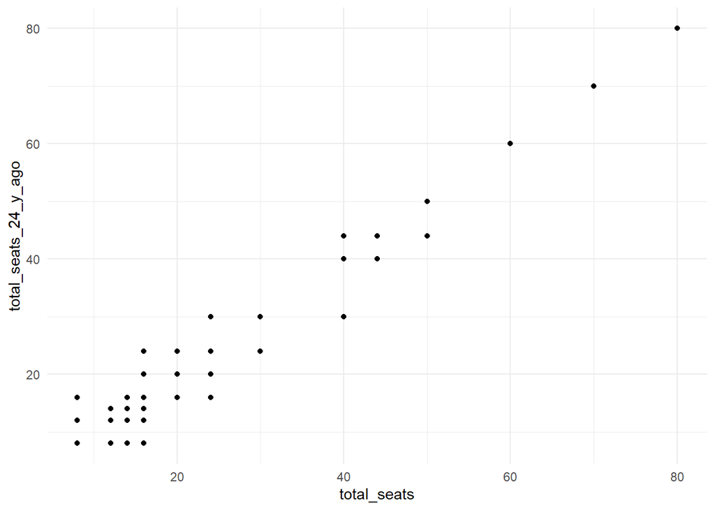

```r
ggplot2::ggplot(data = d_bivariate_iv) + geom_point(aes(total_seats, total_seats_24_y_ago))
```

```r
iv_bivariate <-
  fixest::feols(ln_gross_expenditure_pc ~
                  1 | # 1 is the intercept
                  year + ags | # FE
                  total_seats ~ total_seats_24_y_ago,
                data = d_bivariate_iv)
summary(iv_bivariate, vcov = "hetero", stage = 1:2)
```

```
## IV: First stage: total_seats
## TSLS estimation, Dep. Var.: total_seats, Endo.: total_seats, Instr.: total_seats_24_y_ago
## First stage: Dep. Var.: total_seats
## Observations: 26,639
## Fixed-effects: year: 13,  ags: 2,051
## Standard-errors: Heteroskedasticity-robust
##                      Estimate Std. Error t value Pr(>|t|)
## total_seats_24_y_ago 0.008658   0.004368 1.98213 0.047476 *
## ---
## Signif. codes:  0 '***' 0.001 '**' 0.01 '*' 0.05 '.' 0.1 ' ' 1
## RMSE: 0.360728     Adj. R2: 0.996001
##                  Within R2: 1.609e-4
## F-test (1st stage): stat = 3.95484, p = 0.046748, on 1 and 24,575 DoF.
##
## IV: Second stage
## TSLS estimation, Dep. Var.: ln_gross_expenditure_pc, Endo.: total_seats, Instr.: total_seats_24_y_ago
## Second stage: Dep. Var.: ln_gross_expenditure_pc
## Observations: 26,639
## Fixed-effects: year: 13,  ags: 2,051
## Standard-errors: Heteroskedasticity-robust
##                 Estimate Std. Error t value Pr(>|t|)
## fit_total_seats 0.590465   0.396462 1.48934  0.13641
## ---
## Signif. codes:  0 '***' 0.001 '**' 0.01 '*' 0.05 '.' 0.1 ' ' 1
## RMSE: 0.283661     Adj. R2: 0.193031
##                  Within R2: -1.30718
## F-test (1st stage), total_seats: stat = 3.95677, p = 0.046694, on 1 and 24,587 DoF.
##                      Wu-Hausman: stat = 5.17062, p = 0.022981, on 1 and 24,574 DoF.
```

```r
summary(iv_bivariate, vcov = "twoway", stage = 1:2)
```

```
## IV: First stage: total_seats
## TSLS estimation, Dep. Var.: total_seats, Endo.: total_seats, Instr.: total_seats_24_y_ago
## First stage: Dep. Var.: total_seats
## Observations: 26,639
## Fixed-effects: year: 13,  ags: 2,051
## Standard-errors: Clustered (year & ags)
##                      Estimate Std. Error  t value Pr(>|t|)
## total_seats_24_y_ago 0.008658    0.01026 0.843857  0.41525
## ---
## Signif. codes:  0 '***' 0.001 '**' 0.01 '*' 0.05 '.' 0.1 ' ' 1
## RMSE: 0.360728     Adj. R2: 0.996001
##                  Within R2: 1.609e-4
## F-test (1st stage): stat = 4.28668, p = 0.038422, on 1 and 26,637 DoF.
##
## IV: Second stage
## TSLS estimation, Dep. Var.: ln_gross_expenditure_pc, Endo.: total_seats, Instr.: total_seats_24_y_ago
## Second stage: Dep. Var.: ln_gross_expenditure_pc
## Observations: 26,639
## Fixed-effects: year: 13,  ags: 2,051
## Standard-errors: Clustered (year & ags)
##                 Estimate Std. Error  t value Pr(>|t|)
## fit_total_seats 0.590465   0.746645 0.790824   0.4444
## ---
## Signif. codes:  0 '***' 0.001 '**' 0.01 '*' 0.05 '.' 0.1 ' ' 1
## RMSE: 0.283661     Adj. R2: 0.193031
##                  Within R2: -1.30718
## F-test (1st stage), total_seats: stat = 3.95677, p = 0.046694, on 1 and 24,587 DoF.
##                      Wu-Hausman: stat = 5.17062, p = 0.022981, on 1 and 24,574 DoF.
```

With FE, the effect on the first stage is basically 0. This does not make sense if you look at the relationship between endogenous regressor and instrument. Likely reason: municipality FE, since changes within municipalities occur rarely. This is suggestively confirmed by an IV regression with municipality but not year FE as the effect may be significant but of small magnitude:

```r
iv_bivariate <-
  fixest::feols(ln_gross_expenditure_pc ~
                  1 | # 1 is the intercept
                  ags | # FE
                  total_seats ~ total_seats_24_y_ago,
                data = d_bivariate_iv)
summary(iv_bivariate, vcov = "hetero", stage = 1:2)
```

```
## IV: First stage: total_seats
## TSLS estimation, Dep. Var.: total_seats, Endo.: total_seats, Instr.: total_seats_24_y_ago
## First stage: Dep. Var.: total_seats
## Observations: 26,639
## Fixed-effects: ags: 2,051
## Standard-errors: Heteroskedasticity-robust
##                      Estimate Std. Error t value        Pr(>|t|)
## total_seats_24_y_ago 0.023283   0.004035 5.77075 0.0000000079867 ***
## ---
## Signif. codes:  0 '***' 0.001 '**' 0.01 '*' 0.05 '.' 0.1 ' ' 1
## RMSE: 0.363225     Adj. R2: 0.995948
##                  Within R2: 0.001197
## F-test (1st stage): stat = 29.5, p = 5.736e-8, on 1 and 24,587 DoF.
##
## IV: Second stage
## TSLS estimation, Dep. Var.: ln_gross_expenditure_pc, Endo.: total_seats, Instr.: total_seats_24_y_ago
## Second stage: Dep. Var.: ln_gross_expenditure_pc
## Observations: 26,639
## Fixed-effects: ags: 2,051
## Standard-errors: Heteroskedasticity-robust
##                 Estimate Std. Error t value     Pr(>|t|)
## fit_total_seats  2.15257   0.385563 5.58293 0.0000000239 ***
## ---
## Signif. codes:  0 '***' 0.001 '**' 0.01 '*' 0.05 '.' 0.1 ' ' 1
## RMSE: 0.802718     Adj. R2:  -5.45911
##                  Within R2: -11.1
## F-test (1st stage), total_seats: stat =  31.9, p = 1.618e-8, on 1 and 26,637 DoF.
##                      Wu-Hausman: stat = 333.1, p < 2.2e-16 , on 1 and 24,586 DoF.
```

```r
summary(iv_bivariate, vcov = "cluster", stage = 1:2)
```

```
## IV: First stage: total_seats
## TSLS estimation, Dep. Var.: total_seats, Endo.: total_seats, Instr.: total_seats_24_y_ago
## First stage: Dep. Var.: total_seats
## Observations: 26,639
## Fixed-effects: ags: 2,051
## Standard-errors: Clustered (ags)
##                      Estimate Std. Error t value Pr(>|t|)
## total_seats_24_y_ago 0.023283   0.009971 2.33497 0.019641 *
## ---
## Signif. codes:  0 '***' 0.001 '**' 0.01 '*' 0.05 '.' 0.1 ' ' 1
## RMSE: 0.363225     Adj. R2: 0.995948
##                  Within R2: 0.001197
## F-test (1st stage): stat = 31.9, p = 1.618e-8, on 1 and 26,637 DoF.
##
## IV: Second stage
## TSLS estimation, Dep. Var.: ln_gross_expenditure_pc, Endo.: total_seats, Instr.: total_seats_24_y_ago
## Second stage: Dep. Var.: ln_gross_expenditure_pc
## Observations: 26,639
## Fixed-effects: ags: 2,051
## Standard-errors: Clustered (ags)
##                 Estimate Std. Error t value Pr(>|t|)
## fit_total_seats  2.15257   0.908718  2.3688 0.017938 *
## ---
## Signif. codes:  0 '***' 0.001 '**' 0.01 '*' 0.05 '.' 0.1 ' ' 1
## RMSE: 0.802718     Adj. R2:  -5.45911
##                  Within R2: -11.1
## F-test (1st stage), total_seats: stat =  31.9, p = 1.618e-8, on 1 and 26,637 DoF.
##                      Wu-Hausman: stat = 333.1, p < 2.2e-16 , on 1 and 24,586 DoF.
```

```r
iv_bivariate <-
  fixest::feols(ln_gross_expenditure_pc ~
                  1 | # 1 is the intercept
                  year | # FE
                  total_seats ~ total_seats_24_y_ago,
                data = d_bivariate_iv)
summary(iv_bivariate, vcov = "hetero", stage = 1:2)
```

```
## IV: First stage: total_seats
## TSLS estimation, Dep. Var.: total_seats, Endo.: total_seats, Instr.: total_seats_24_y_ago
## First stage: Dep. Var.: total_seats
## Observations: 26,639
## Fixed-effects: year: 13
## Standard-errors: Heteroskedasticity-robust
##                      Estimate Std. Error t value  Pr(>|t|)
## total_seats_24_y_ago 0.975659   0.001947 501.162 < 2.2e-16 ***
## ---
## Signif. codes:  0 '***' 0.001 '**' 0.01 '*' 0.05 '.' 0.1 ' ' 1
## RMSE: 1.61515     Adj. R2: 0.926004
##                 Within R2: 0.926036
## F-test (1st stage): stat = 333,348.6, p < 2.2e-16, on 1 and 26,625 DoF.
##
## IV: Second stage
## TSLS estimation, Dep. Var.: ln_gross_expenditure_pc, Endo.: total_seats, Instr.: total_seats_24_y_ago
## Second stage: Dep. Var.: ln_gross_expenditure_pc
## Observations: 26,639
## Fixed-effects: year: 13
## Standard-errors: Heteroskedasticity-robust
##                 Estimate Std. Error t value  Pr(>|t|)
## fit_total_seats  0.00692   0.000327 21.1548 < 2.2e-16 ***
## ---
## Signif. codes:  0 '***' 0.001 '**' 0.01 '*' 0.05 '.' 0.1 ' ' 1
## RMSE: 0.297475     Adj. R2: 0.180848
##                  Within R2: 0.013822
## F-test (1st stage), total_seats: stat = 333,498.9, p < 2.2e-16, on 1 and 26,637 DoF.
##                      Wu-Hausman: stat =     112.7, p < 2.2e-16, on 1 and 26,624 DoF.
```

```r
summary(iv_bivariate, vcov = "cluster", stage = 1:2)
```

```
## IV: First stage: total_seats
## TSLS estimation, Dep. Var.: total_seats, Endo.: total_seats, Instr.: total_seats_24_y_ago
## First stage: Dep. Var.: total_seats
## Observations: 26,639
## Fixed-effects: year: 13
## Standard-errors: Clustered (year)
##                      Estimate Std. Error t value  Pr(>|t|)
## total_seats_24_y_ago 0.975659   0.000499 1956.53 < 2.2e-16 ***
## ---
## Signif. codes:  0 '***' 0.001 '**' 0.01 '*' 0.05 '.' 0.1 ' ' 1
## RMSE: 1.61515     Adj. R2: 0.926004
##                 Within R2: 0.926036
## F-test (1st stage): stat = 333,498.9, p < 2.2e-16, on 1 and 26,637 DoF.
##
## IV: Second stage
## TSLS estimation, Dep. Var.: ln_gross_expenditure_pc, Endo.: total_seats, Instr.: total_seats_24_y_ago
## Second stage: Dep. Var.: ln_gross_expenditure_pc
## Observations: 26,639
## Fixed-effects: year: 13
## Standard-errors: Clustered (year)
##                 Estimate Std. Error t value        Pr(>|t|)
## fit_total_seats  0.00692    0.00048 14.4078 0.0000000061546 ***
## ---
## Signif. codes:  0 '***' 0.001 '**' 0.01 '*' 0.05 '.' 0.1 ' ' 1
## RMSE: 0.297475     Adj. R2: 0.180848
##                  Within R2: 0.013822
## F-test (1st stage), total_seats: stat = 333,498.9, p < 2.2e-16, on 1 and 26,637 DoF.
##                      Wu-Hausman: stat =     112.7, p < 2.2e-16, on 1 and 26,624 DoF.
```

Here, we do have an estimate on the instrument that is close to one, which is more plausible. Hence, in the following, I am only using year FE.

## Multivariate IV

```r
fixest::feols(
  ln_gross_expenditure_pc ~
    csw0(inh_tot, pop_over65, unempl_rate, total_area_ha,
         share_working_age, kreisfreie_stadt, stadt, years_since_last_elec) | # controls
    year |#+ ags | # FE
    total_seats ~ total_seats_24_y_ago, # IV formula for 1st stage
  data = data,
  vcov = "cluster"
)
```

```
## NOTE: 205,294 observations removed because of NA values (LHS: 121,429, IV: 15,941/190,929). [This msg only concerns the variables common to all estimations.]
```

```
## The exogenous variables 'years_since_last_elec1', 'years_since_last_elec2' and 3 others have been removed because of collinearity (see $collin.var).
```

```
## Standard-errors: Clustered (year)
## Expl. vars.: 1
##                 Estimate Std. Error t value        Pr(>|t|)
## fit_total_seats  0.00692    0.00048 14.4078 0.0000000061546 ***
## ---
## Expl. vars.: inh_tot
##                    Estimate   Std. Error  t value      Pr(>|t|)
## fit_total_seats 0.005430626 0.0005793510  9.37364 0.00000071708 ***
## inh_tot         0.000000494 0.0000000467 10.57237 0.00000019565 ***
## ---
## Expl. vars.: inh_tot + pop_over65
##                    Estimate   Std. Error  t value      Pr(>|t|)
## fit_total_seats 0.003689767 0.0004979677  7.40965 0.00000816743 ***
## inh_tot         0.000000619 0.0000000482 12.84031 0.00000002267 ***
## pop_over65      0.864275991 0.0952651456  9.07232 0.00000101453 ***
## ---
## Expl. vars.: inh_tot + pop_over65 + unempl_rate
##                     Estimate   Std. Error   t value       Pr(>|t|)
## fit_total_seats  0.004496998 0.0005154073   8.72514 0.000001530114 ***
## inh_tot          0.000000597 0.0000000466  12.80940 0.000000023292 ***
## pop_over65       1.074179235 0.1105778521   9.71423 0.000000489436 ***
## unempl_rate     -1.264549021 0.1169025991 -10.81712 0.000000152309 ***
## ---
## Expl. vars.: inh_tot + pop_over65 + unempl_rate + total_area_ha
##                     Estimate   Std. Error   t value       Pr(>|t|)
## fit_total_seats  0.005489507 0.0005148318  10.66272 0.000000178273 ***
## inh_tot          0.000000635 0.0000000474  13.40536 0.000000013951 ***
## pop_over65       1.100916305 0.1128394838   9.75648 0.000000467136 ***
## unempl_rate     -1.280893144 0.1174891603 -10.90222 0.000000139762 ***
## total_area_ha   -0.000004675 0.0000004552 -10.27053 0.000000268199 ***
## ---
## Expl. vars.: inh_tot + pop_over65 + unempl_rate + total_area_ha + share_working_age
##                       Estimate   Std. Error   t value       Pr(>|t|)
## fit_total_seats    0.005237185 0.0005640868   9.28436 0.000000793999 ***
## inh_tot            0.000000635 0.0000000480  13.24436 0.000000015991 ***
## pop_over65         1.241135823 0.1499900346   8.27479 0.000002656404 ***
## unempl_rate       -1.324601638 0.1159030895 -11.42853 0.000000083129 ***
## total_area_ha     -0.000004420 0.0000003729 -11.85100 0.000000055576 ***
## share_working_age  0.243817151 0.1253785439   1.94465 0.075629590783 .
## ---
```

[output cut: 16 more lines]

```
## total_area_ha     -0.000002198 0.0000004125  -5.328815 0.0001796969459750 ***
## share_working_age  0.383323282 0.1612902353   2.376606 0.0349783289138099 *
## kreisfreie_stadt1  0.451575575 0.0159767070  28.264621 0.0000000000023845 ***
## stadt1             0.046937251 0.0034929078  13.437873 0.0000000135740898 ***
## ---
## Expl. vars.: inh_tot + pop_over65 + unempl_rate + total_area_ha + share_working_age + kreisfreie_stadt + stadt + years_since_last_elec
##                       Estimate   Std. Error    t value           Pr(>|t|)
## fit_total_seats   -0.000565308 0.0007339480  -0.770229 0.4560601729344557
## inh_tot            0.000000405 0.0000000378  10.712197 0.0000001694693820 ***
## pop_over65         1.354140751 0.1588955740   8.522206 0.0000019566724175 ***
## unempl_rate       -1.757010019 0.1098479453 -15.994928 0.0000000018607058 ***
## total_area_ha     -0.000002198 0.0000004125  -5.328815 0.0001796969459750 ***
## share_working_age  0.383323282 0.1612902353   2.376606 0.0349783289138099 *
## kreisfreie_stadt1  0.451575575 0.0159767070  28.264621 0.0000000000023845 ***
## stadt1             0.046937251 0.0034929078  13.437873 0.0000000135740898 ***
```

```r
cor(d_controls_iv$total_seats, d_controls_iv$total_seats_24_y_ago)
```

```
## [1] 0.9622348
```

```r
# Model with time and year FE
iv_multivariate <- fixest::feols(
  ln_gross_expenditure_pc ~
    inh_tot + pop_over65 + unempl_rate + total_area_ha +
    share_working_age + kreisfreie_stadt + stadt + years_since_last_elec | # controls
    year + ags | # FE
    total_seats ~ total_seats_24_y_ago, # IV formula for 1st stage
  data = d_controls_iv
)
```

```
## The exogenous variables 'kreisfreie_stadt1', 'stadt1' and 13 others have been removed because of collinearity (see $collin.var).
```

```r
summary(iv_multivariate, vcov = "twoway", stage = 1:2)
```

```
## IV: First stage: total_seats
## TSLS estimation, Dep. Var.: total_seats, Endo.: total_seats, Instr.: total_seats_24_y_ago
## First stage: Dep. Var.: total_seats
## Observations: 26,639
## Fixed-effects: year: 13,  ags: 2,051
## Standard-errors: Clustered (year & ags)
##                         Estimate Std. Error   t value   Pr(>|t|)
## total_seats_24_y_ago  0.00464400 0.01039378  0.446806 0.66297214
## inh_tot               0.00000146 0.00000248  0.587536 0.56773527
## pop_over65           -1.77235091 1.05305316 -1.683059 0.11817715
## unempl_rate           4.83600389 1.10849287  4.362684 0.00092399 ***
## total_area_ha        -0.00006474 0.00005684 -1.139041 0.27691414
## share_working_age    -1.40247338 0.95622834 -1.466672 0.16817682
## ... 15 variables were removed because of collinearity (kreisfreie_stadt1, stadt1 and 13 others [full set in $collin.var])
## ---
## Signif. codes:  0 '***' 0.001 '**' 0.01 '*' 0.05 '.' 0.1 ' ' 1
## RMSE: 0.359345     Adj. R2: 0.996031
##                  Within R2: 0.007813
## F-test (1st stage): stat = 1.22311, p = 0.268761, on 1 and 26,632 DoF.
##
## IV: Second stage
## TSLS estimation, Dep. Var.: ln_gross_expenditure_pc, Endo.: total_seats, Instr.: total_seats_24_y_ago
## Second stage: Dep. Var.: ln_gross_expenditure_pc
## Observations: 26,639
## Fixed-effects: year: 13,  ags: 2,051
## Standard-errors: Clustered (year & ags)
##                      Estimate Std. Error   t value Pr(>|t|)
## fit_total_seats    0.86716499 1.96223178  0.441928  0.66640
## inh_tot           -0.00000335 0.00000405 -0.825941  0.42495
## pop_over65         2.29307568 3.41003343  0.672450  0.51404
## unempl_rate       -4.02609962 9.47940464 -0.424721  0.67856
## total_area_ha      0.00003479 0.00013792  0.252242  0.80512
## share_working_age  1.29233671 2.90248695  0.445252  0.66406
## ... 15 variables were removed because of collinearity (kreisfreie_stadt1, stadt1 and 13 others [full set in $collin.var])
## ---
## Signif. codes:  0 '***' 0.001 '**' 0.01 '*' 0.05 '.' 0.1 ' ' 1
## RMSE: 0.363733     Adj. R2: -0.327128
##                  Within R2: -2.79357
## F-test (1st stage), total_seats: stat =  1.12896, p = 0.288007, on 1 and 24,582 DoF.
##                      Wu-Hausman: stat = NA      , p = NA      , on 1 and 24,569 DoF.
```

```r
# "Real" model
iv_multivariate <- fixest::feols(
  ln_gross_expenditure_pc ~
    inh_tot + pop_over65 + unempl_rate + total_area_ha +
    share_working_age + kreisfreie_stadt + stadt + years_since_last_elec | # controls
    year |#+ ags | # FE
    total_seats ~ total_seats_24_y_ago, # IV formula for 1st stage
  data = d_controls_iv
)
```

```
## The exogenous variables 'years_since_last_elec1', 'years_since_last_elec2' and 11 others have been removed because of collinearity (see $collin.var).
```

```r
summary(iv_multivariate, vcov = "hetero", stage = 1:2)
```

```
## IV: First stage: total_seats
## TSLS estimation, Dep. Var.: total_seats, Endo.: total_seats, Instr.: total_seats_24_y_ago
## First stage: Dep. Var.: total_seats
## Observations: 26,639
## Fixed-effects: year: 13
## Standard-errors: Heteroskedasticity-robust
##                          Estimate  Std. Error    t value               Pr(>|t|)
## total_seats_24_y_ago   0.98509852 0.003847122 256.061187              < 2.2e-16
## inh_tot                0.00000197 0.000000554   3.549519 0.00038660030168690681
## pop_over65           -10.35193343 0.493137773 -20.991970              < 2.2e-16
## unempl_rate           -7.38407937 0.862219131  -8.564040              < 2.2e-16
## total_area_ha         -0.00000204 0.000004759  -0.427769 0.66882245595272160621
## share_working_age      2.90704641 0.627564348   4.632268 0.00000363391632851485
## kreisfreie_stadt1      0.09654886 0.136732641   0.706114 0.48012332023838211192
## stadt1                 0.31996494 0.039307502   8.140048 0.00000000000000041224
##
## total_seats_24_y_ago ***
## inh_tot              ***
## pop_over65           ***
## unempl_rate          ***
## total_area_ha
## share_working_age    ***
## kreisfreie_stadt1
## stadt1               ***
## ... 13 variables were removed because of collinearity (years_since_last_elec1, years_since_last_elec2 and 11 others [full set in $collin.var])
## ---
## Signif. codes:  0 '***' 0.001 '**' 0.01 '*' 0.05 '.' 0.1 ' ' 1
## RMSE: 1.5636     Adj. R2: 0.930634
##                Within R2: 0.930683
## F-test (1st stage): stat = 120,580.0, p < 2.2e-16, on 1 and 26,618 DoF.
##
## IV: Second stage
## TSLS estimation, Dep. Var.: ln_gross_expenditure_pc, Endo.: total_seats, Instr.: total_seats_24_y_ago
## Second stage: Dep. Var.: ln_gross_expenditure_pc
## Observations: 26,639
## Fixed-effects: year: 13
## Standard-errors: Heteroskedasticity-robust
##                       Estimate   Std. Error   t value               Pr(>|t|)
## fit_total_seats   -0.000565308 0.0005564885  -1.01585 0.30971047641790355742
## inh_tot            0.000000405 0.0000000363  11.14662              < 2.2e-16
## pop_over65         1.354140751 0.1035450592  13.07779              < 2.2e-16
## unempl_rate       -1.757010019 0.1553295823 -11.31150              < 2.2e-16
## total_area_ha     -0.000002198 0.0000009015  -2.43839 0.01475916566214174712
## share_working_age  0.383323282 0.1427203627   2.68583 0.00723937722362642724
## kreisfreie_stadt1  0.451575575 0.0199663873  22.61679              < 2.2e-16
## stadt1             0.046937251 0.0057937987   8.10129 0.00000000000000056689
##
## fit_total_seats
## inh_tot           ***
## pop_over65        ***
## unempl_rate       ***
## total_area_ha     *
## share_working_age **
## kreisfreie_stadt1 ***
## stadt1            ***
## ... 13 variables were removed because of collinearity (years_since_last_elec1, years_since_last_elec2 and 11 others [full set in $collin.var])
## ---
## Signif. codes:  0 '***' 0.001 '**' 0.01 '*' 0.05 '.' 0.1 ' ' 1
## RMSE: 0.292775     Adj. R2: 0.206322
##                  Within R2: 0.044741
## F-test (1st stage), total_seats: stat = 120,634.4, p < 2.2e-16, on 1 and 26,630 DoF.
##                      Wu-Hausman: stat =      NA  , p = NA     , on 1 and 26,617 DoF.
```

```r
summary(iv_multivariate, vcov = "cluster", stage = 1:2)
```

```
## IV: First stage: total_seats
## TSLS estimation, Dep. Var.: total_seats, Endo.: total_seats, Instr.: total_seats_24_y_ago
## First stage: Dep. Var.: total_seats
## Observations: 26,639
## Fixed-effects: year: 13
## Standard-errors: Clustered (year)
##                          Estimate   Std. Error    t value            Pr(>|t|)
## total_seats_24_y_ago   0.98509852 0.0039822864 247.370082           < 2.2e-16
## inh_tot                0.00000197 0.0000000635  30.930150 0.00000000000081969
## pop_over65           -10.35193343 0.7541465383 -13.726687 0.00000001067033494
## unempl_rate           -7.38407937 0.4240283067 -17.414119 0.00000000069769092
## total_area_ha         -0.00000204 0.0000040721  -0.499966 0.62614039916199338
## share_working_age      2.90704641 2.1491203518   1.352668 0.20110016419163509
## kreisfreie_stadt1      0.09654886 0.0798362411   1.209336 0.24982097367377273
## stadt1                 0.31996494 0.0320700478   9.977065 0.00000036712668453
##
## total_seats_24_y_ago ***
## inh_tot              ***
## pop_over65           ***
## unempl_rate          ***
## total_area_ha
## share_working_age
## kreisfreie_stadt1
## stadt1               ***
## ... 13 variables were removed because of collinearity (years_since_last_elec1, years_since_last_elec2 and 11 others [full set in $collin.var])
## ---
## Signif. codes:  0 '***' 0.001 '**' 0.01 '*' 0.05 '.' 0.1 ' ' 1
## RMSE: 1.5636     Adj. R2: 0.930634
##                Within R2: 0.930683
## F-test (1st stage): stat = 120,634.4, p < 2.2e-16, on 1 and 26,630 DoF.
##
## IV: Second stage
## TSLS estimation, Dep. Var.: ln_gross_expenditure_pc, Endo.: total_seats, Instr.: total_seats_24_y_ago
## Second stage: Dep. Var.: ln_gross_expenditure_pc
## Observations: 26,639
## Fixed-effects: year: 13
## Standard-errors: Clustered (year)
##                       Estimate   Std. Error    t value           Pr(>|t|)
## fit_total_seats   -0.000565308 0.0007339480  -0.770229 0.4560601729344557
## inh_tot            0.000000405 0.0000000378  10.712197 0.0000001694693820 ***
## pop_over65         1.354140751 0.1588955740   8.522206 0.0000019566724175 ***
## unempl_rate       -1.757010019 0.1098479453 -15.994928 0.0000000018607058 ***
## total_area_ha     -0.000002198 0.0000004125  -5.328815 0.0001796969459750 ***
## share_working_age  0.383323282 0.1612902353   2.376606 0.0349783289138099 *
## kreisfreie_stadt1  0.451575575 0.0159767070  28.264621 0.0000000000023845 ***
## stadt1             0.046937251 0.0034929078  13.437873 0.0000000135740898 ***
## ... 13 variables were removed because of collinearity (years_since_last_elec1, years_since_last_elec2 and 11 others [full set in $collin.var])
## ---
## Signif. codes:  0 '***' 0.001 '**' 0.01 '*' 0.05 '.' 0.1 ' ' 1
## RMSE: 0.292775     Adj. R2: 0.206322
##                  Within R2: 0.044741
## F-test (1st stage), total_seats: stat = 120,634.4, p < 2.2e-16, on 1 and 26,630 DoF.
##                      Wu-Hausman: stat =      NA  , p = NA     , on 1 and 26,617 DoF.
```

```r
-0.000565308 + c(1.96, -1.96) * 0.0007339480 # CI for total_seats in the latter case
```

```
## [1]  0.0008732301 -0.0020038461
```

```r
# Run it again with clustered SE for summary
iv_multivariate <- fixest::feols(
  ln_gross_expenditure_pc ~
    inh_tot + pop_over65 + unempl_rate + total_area_ha +
    share_working_age + kreisfreie_stadt + stadt + years_since_last_elec | # controls
    year |#+ ags | # FE
    total_seats ~ total_seats_24_y_ago, # IV formula for 1st stage
  vcov = "cluster",
  data = d_controls_iv
)
```

```
## The exogenous variables 'years_since_last_elec1', 'years_since_last_elec2' and 11 others have been removed because of collinearity (see $collin.var).
```

[“Wu-Hausman tests that IV is just as consistent as OLS, and since OLS is more efficient, it would be preferable. The null here is that they are equally consistent”](https://stats.stackexchange.com/questions/134789/interpretation-of-ivreg-diagnostics-in-r). E. g. if the null is rejected at the 10 % level, this is “good” from the IV perspective.

# Summary of conventional-methods results

```r
etable(ols, panel_bivariate, panel_multivariate, iv_multivariate)
```

|  | ols | panel_bivariate | panel_multivariate | iv_multivariate |
| --- | --- | --- | --- | --- |
| Dependent Var.: | ln_gross_expenditure_pc | ln_gross_expenditure_pc | ln_gross_expenditure_pc | ln_gross_expenditure_pc |
| (Intercept) | 7.132*** (0.0403) |  |  |  |
| total_seats | 0.0082*** (0.0002) | 0.0023. (0.0011) | 0.0025* (0.0011) | -0.0006 (0.0007) |
| inh_tot | -1.81e-7*** (3.99e-8) |  | -2.55e-6* (1.15e-6) | 4.05e-7*** (3.78e-8) |
| pop_over65 | 0.2682*** (0.0449) |  | 0.8015*** (0.1703) | 1.354*** (0.1589) |
| unempl_rate | -2.926*** (0.0410) |  | 0.2073 (0.1223) | -1.757*** (0.1098) |
| total_area_ha | 1.67e-5*** (4.98e-7) |  | 5.97e-6 (6.45e-6) | -2.2e-6*** (4.12e-7) |
| share_working_age | -0.0488 (0.0569) |  | 0.2517. (0.1358) | 0.3833* (0.1613) |
| kreisfreie_stadt1 | 0.3943*** (0.0104) |  |  | 0.4516*** (0.0160) |

[output cut: 14 more lines]

Test LaTeX export – note that differences between HTML and TeX output remain.

```r
# etable(ols, panel_bivariate, panel_multivariate,
#        # Table settings
#        drop = "!Council size",
#        dict = c(total_seats = "Council size",
#                 ln_gross_expenditure_pc = "Ln of gross expenditure p. c."),
#        signif.code = c("***"=0.001, "**"=0.01, "*"=0.05, "'"=0.10),
#        headers = list("OLS", "FE bivariate", "FE multivariate"),
#        # LaTeX settings
#        title = "Results of the \"Conventional\" Regression Methods",
#        label = "tab:conv_results",
#        notes = "Test notes here",
#        style.df = style.df(
#          fixef.suffix = " fixed-effect"
#        )
#        )
```

## Export to LaTeX

tex notes text

```r
tex_control_text <- "Controls, \\ac{FE} and \\ac{SE} as indicated in the respective column. Controls, if included and as long as not perfectly collinear: population, share of population over 65 years, unemployment rate, total area, share of working-age population, and dummies for ``district-free'' cities, cities, as well as year in the electoral cycle."
tex_signif_text <- "Significance codes: *** p < 0.001, ** p < 0.01, * p < 0.05, ' p < 0.10.}"
```

```r
etable(ols, panel_bivariate, panel_multivariate, iv_multivariate,
       file = "tables/conv_results.tex",
       replace = TRUE,
       # Table settings
       drop = "!Council size",
       dict = c(total_seats = "Council size",
                ln_gross_expenditure_pc = "Ln of gross expenditure p. c."),
       signif.code = c("***"=0.001, "**"=0.01, "*"=0.05, "'"=0.10),
       headers = c("\\acs{OLS}", "\\acs{FE} bivariate", "\\acs{FE} multivariate", "\\acs{IV} multivariate"),
       extralines = list(
         "-^Controls" = c("Yes", "No", "Yes", "Yes"),
         "-_\\acs{SE}" = c("\\acs{het}", "by \\acs{yr} & \\acs{mcp}", "by \\acs{yr} & \\acs{mcp}", "by \\acs{yr}"),
         "_^Data sample" = c(rep("All data", 3), "\\acs{BY} only")
         ),
       # LaTeX settings
       title = "Results of the ``Conventional'' Regression Methods",
       label = "tab:conv_results",
       notes = paste("\\footnotesize{*Notes:* Results of the ``conventional'' regression methods.",
                     tex_control_text,
                     "The \\acl{SE} in parentheses: \\ac{het}; if \\ac{SE} starts with ``by'', they are clustered at the \\ac{yr} and/or \\ac{mcp} level.",
                     tex_signif_text),
       style.tex = style.tex(
         fixef.suffix = " \\ac{FE}"
       )
       )
```

```r
rm(list=ls(pattern="^panel_"))
rm(list=ls(pattern="^iv_"))
```

# Regression discontinuity design – Normalized Cutoff

Sharp RDD mit “intention-to-treat” effect?

Treating all of the cutoffs as one requires a harmonization. This happens according to Egger and Koethenbuerger (2010):

Using the Egger and Koethenbuerger (2010) calculation steps:
$$\tilde{N_i} = N_i/N_d$$
with $N_i$ as the relevant actual population size and $N_d$ as the respective thresholds.

## t test

The most simple thing to do is a simple t test for differences.

```r
# 0.1 around cutoff
d_ttest2 <- d_ttest %>%
  filter(abs(inhabs_rel_to_cutoff) < 0.1) # Choose bandwidth
nrow(d_ttest2) / nrow(data) # Share of observations close to threshold
```

```
## [1] 0.1323141
```

```r
t.test(log(d_ttest2$ln_gross_expenditure_pc[d_ttest2$inhabs_rel_to_cutoff < 0]),
       log(d_ttest2$ln_gross_expenditure_pc[d_ttest2$inhabs_rel_to_cutoff >= 0]))
```

```
##
##  Welch Two Sample t-test
##
## data:  log(d_ttest2$ln_gross_expenditure_pc[d_ttest2$inhabs_rel_to_cutoff < 0]) and log(d_ttest2$ln_gross_expenditure_pc[d_ttest2$inhabs_rel_to_cutoff >= 0])
## t = -2.473, df = 30496, p-value = 0.0134
## alternative hypothesis: true difference in means is not equal to 0
## 95 percent confidence interval:
##  -0.0027794357 -0.0003216191
## sample estimates:
## mean of x mean of y
##  1.975094  1.976645
```

```r
# 0.05 around cutoff
d_ttest2 <- d_ttest %>%
  filter(abs(inhabs_rel_to_cutoff) < 0.05) # Choose bandwidth
nrow(d_ttest2) / nrow(data) # Share of observations close to threshold
```

```
## [1] 0.06564827
```

```r
t.test(log(d_ttest2$ln_gross_expenditure_pc[d_ttest2$inhabs_rel_to_cutoff < 0]),
       log(d_ttest2$ln_gross_expenditure_pc[d_ttest2$inhabs_rel_to_cutoff >= 0]))
```

```
##
##  Welch Two Sample t-test
##
## data:  log(d_ttest2$ln_gross_expenditure_pc[d_ttest2$inhabs_rel_to_cutoff < 0]) and log(d_ttest2$ln_gross_expenditure_pc[d_ttest2$inhabs_rel_to_cutoff >= 0])
## t = -0.47803, df = 15138, p-value = 0.6326
## alternative hypothesis: true difference in means is not equal to 0
## 95 percent confidence interval:
##  -0.002131273  0.001295553
## sample estimates:
## mean of x mean of y
##  1.974848  1.975266
```

```r
# 0.01 around cutoff
d_ttest2 <- d_ttest %>%
  filter(abs(inhabs_rel_to_cutoff) < 0.025) # Choose bandwidth
nrow(d_ttest2) / nrow(data) # Share of observations close to threshold
```

```
## [1] 0.03260424
```

```r
t.test(log(d_ttest2$ln_gross_expenditure_pc[d_ttest2$inhabs_rel_to_cutoff < 0]),
       log(d_ttest2$ln_gross_expenditure_pc[d_ttest2$inhabs_rel_to_cutoff >= 0]))
```

```
##
##  Welch Two Sample t-test
##
## data:  log(d_ttest2$ln_gross_expenditure_pc[d_ttest2$inhabs_rel_to_cutoff < 0]) and log(d_ttest2$ln_gross_expenditure_pc[d_ttest2$inhabs_rel_to_cutoff >= 0])
## t = 0.63621, df = 7509.2, p-value = 0.5247
## alternative hypothesis: true difference in means is not equal to 0
## 95 percent confidence interval:
##  -0.001631681  0.003199707
## sample estimates:
## mean of x mean of y
##  1.976049  1.975265
```

The results are not really consistent when it comes to statistical significance. The difference between both sides also heavily depends on the bandwidth chosen. Keep in mind, however, that a t test is not exactly appropriate due to the fuzzy nature of the setting: Whether or not municipalities actually take treatment is not accounted for in this approach.

```r
rm(d_ttest2)
```

## Manual IV regression

This is how it is done according to [“The Effect” of Nick Huntington-Klein, chapter 20](https://theeffectbook.net/ch-RegressionDiscontinuity.html):

```r
df <- d_rdd_bivariate %>%
  filter(closest <= 0.1) # Choose bandwidth window -- similar to Höhmann (2017)
rdd_bivariate <- fixest::feols(ln_gross_expenditure_pc ~
                                 1  | # controls
                                 inhabitants_treshold_factor + year + ags | # fixed-effect controls
                                 # First stage regression:
                                 inhabs_rel_to_cutoff*total_seats ~ # Instrument our standard RDD...
                                 inhabs_rel_to_cutoff*above_cutoff, # ... with being above the cutoff
                               data = df)
summary(rdd_bivariate, vcov = "hetero")
```

```
## TSLS estimation, Dep. Var.: ln_gross_expenditure_pc, Endo.: inhabs_rel_to_cutoff, total_seats, inhabs_rel_to_cutoff:total_seats, Instr.: inhabs_rel_to_cutoff, above_cutoff, inhabs_rel_to_cutoff:above_cutoff
## Second stage: Dep. Var.: ln_gross_expenditure_pc
## Observations: 10,361
## Fixed-effects: inhabitants_treshold_factor: 29,  year: 13,  ags: 1,816
## Standard-errors: Heteroskedasticity-robust
##                                       Estimate Std. Error   t value Pr(>|t|)
## fit_inhabs_rel_to_cutoff              4.844674   4.476565  1.082230  0.27918
## fit_total_seats                      -0.017580   0.012094 -1.453693  0.14607
## fit_inhabs_rel_to_cutoff:total_seats -0.207506   0.269329 -0.770455  0.44105
## ---
## Signif. codes:  0 '***' 0.001 '**' 0.01 '*' 0.05 '.' 0.1 ' ' 1
## RMSE: 0.17718     Adj. R2:  0.747016
##                 Within R2: -0.01326
## F-test (1st stage), inhabs_rel_to_cutoff            : stat =      2.597e+33, p < 2.2e-16, on 3 and 8,530 DoF.
## F-test (1st stage), total_seats                     : stat =    892.1      , p < 2.2e-16, on 3 and 8,530 DoF.
## F-test (1st stage), inhabs_rel_to_cutoff:total_seats: stat = 12,784.0      , p < 2.2e-16, on 3 and 8,530 DoF.
##                                           Wu-Hausman: stat =     NA        , p = NA     , on 3 and 8,499 DoF.
```

```r
summary(rdd_bivariate, vcov = "threeway", stage = 1:2)
```

```
## IV: First stage: inhabs_rel_to_cutoff
## TSLS estimation, Dep. Var.: inhabs_rel_to_cutoff, Endo.: inhabs_rel_to_cutoff, total_seats, inhabs_rel_to_cutoff:total_seats, Instr.: inhabs_rel_to_cutoff, above_cutoff, inhabs_rel_to_cutoff:above_cutoff
## First stage: Dep. Var.: inhabs_rel_to_cutoff
## Observations: 10,361
## Fixed-effects: inhabitants_treshold_factor: 29,  year: 13,  ags: 1,816
## Standard-errors: Clustered (inhabitants_treshold_factor & year & ags)
##                                                 Estimate            Std. Error
## inhabs_rel_to_cutoff               1.0000000000000013323 0.0000000000000006029
## above_cutoff                      -0.0000000000000000260 0.0000000000000000119
## inhabs_rel_to_cutoff:above_cutoff -0.0000000000000026645 0.0000000000000011950
##                                                  t value  Pr(>|t|)
## inhabs_rel_to_cutoff              1658683354947119.50000 < 2.2e-16 ***
## above_cutoff                                    -2.17980  0.049912 *
## inhabs_rel_to_cutoff:above_cutoff               -2.22972  0.045634 *
## ---
## Signif. codes:  0 '***' 0.001 '**' 0.01 '*' 0.05 '.' 0.1 ' ' 1
## RMSE: 1.029e-17     Adj. R2: 1
##                   Within R2: 1
## F-test (1st stage): stat = 3.153e+33, p < 2.2e-16, on 3 and 10,357 DoF.
##
## IV: First stage: total_seats
## TSLS estimation, Dep. Var.: total_seats, Endo.: inhabs_rel_to_cutoff, total_seats, inhabs_rel_to_cutoff:total_seats, Instr.: inhabs_rel_to_cutoff, above_cutoff, inhabs_rel_to_cutoff:above_cutoff
## First stage: Dep. Var.: total_seats
## Observations: 10,361
## Fixed-effects: inhabitants_treshold_factor: 29,  year: 13,  ags: 1,816
## Standard-errors: Clustered (inhabitants_treshold_factor & year & ags)
##                                   Estimate Std. Error  t value   Pr(>|t|)
## inhabs_rel_to_cutoff              13.28120   9.413262 1.410903 0.18366879
## above_cutoff                       1.12411   0.245802 4.573230 0.00063989 ***
## inhabs_rel_to_cutoff:above_cutoff  1.97383   8.375661 0.235663 0.81766840
## ---
## Signif. codes:  0 '***' 0.001 '**' 0.01 '*' 0.05 '.' 0.1 ' ' 1
## RMSE: 0.750817     Adj. R2: 0.990581
##                  Within R2: 0.238811
## F-test (1st stage): stat = 1,083.1, p < 2.2e-16, on 3 and 10,357 DoF.
##
## IV: First stage: inhabs_rel_to_cutoff:total_seats
## TSLS estimation, Dep. Var.: inhabs_rel_to_cutoff:total_seats, Endo.: inhabs_rel_to_cutoff, total_seats, inhabs_rel_to_cutoff:total_seats, Instr.: inhabs_rel_to_cutoff, above_cutoff, inhabs_rel_to_cutoff:above_cutoff
## First stage: Dep. Var.: inhabs_rel_to_cutoff:total_seats
## Observations: 10,361
```

[output cut: 19 more lines]

```
## Observations: 10,361
## Fixed-effects: inhabitants_treshold_factor: 29,  year: 13,  ags: 1,816
## Standard-errors: Clustered (inhabitants_treshold_factor & year & ags)
##                                       Estimate Std. Error   t value Pr(>|t|)
## fit_inhabs_rel_to_cutoff              4.844674   7.466621  0.648844  0.52866
## fit_total_seats                      -0.017580   0.015035 -1.169279  0.26499
## fit_inhabs_rel_to_cutoff:total_seats -0.207506   0.458018 -0.453051  0.65859
## ---
## Signif. codes:  0 '***' 0.001 '**' 0.01 '*' 0.05 '.' 0.1 ' ' 1
## RMSE: 0.17718     Adj. R2:  0.747016
##                 Within R2: -0.01326
## F-test (1st stage), inhabs_rel_to_cutoff            : stat =      2.597e+33, p < 2.2e-16, on 3 and 8,530 DoF.
## F-test (1st stage), total_seats                     : stat =    892.1      , p < 2.2e-16, on 3 and 8,530 DoF.
## F-test (1st stage), inhabs_rel_to_cutoff:total_seats: stat = 12,784.0      , p < 2.2e-16, on 3 and 8,530 DoF.
##                                           Wu-Hausman: stat =     NA        , p = NA     , on 3 and 8,499 DoF.
```

```r
# More tests:
#fixest::fitstat(rdd, ~ ivf1 + ivwald1 + ivf2 + ivwald2)
rm(df)
```

More simplistic version:

```r
df <- d_rdd_bivariate %>%
  filter(closest <= 0.1) # Choose bandwidth window -- similar to Höhmann (2017)
rdd <- fixest::feols(ln_gross_expenditure_pc ~
                     1  | # controls
                     inhabitants_treshold_factor + year + ags | # fixed-effect controls
                     # First stage regression:
                     total_seats ~ # Instrument our standard RDD...
                     above_cutoff, # ... with being above the cutoff
                     data = df)
summary(rdd, vcov = "hetero")
```

```
## TSLS estimation, Dep. Var.: ln_gross_expenditure_pc, Endo.: total_seats, Instr.: above_cutoff
## Second stage: Dep. Var.: ln_gross_expenditure_pc
## Observations: 10,361
## Fixed-effects: inhabitants_treshold_factor: 29,  year: 13,  ags: 1,816
## Standard-errors: Heteroskedasticity-robust
##                 Estimate Std. Error t value Pr(>|t|)
## fit_total_seats 0.010193   0.004981 2.04628 0.040759 *
## ---
## Signif. codes:  0 '***' 0.001 '**' 0.01 '*' 0.05 '.' 0.1 ' ' 1
## RMSE: 0.175937     Adj. R2: 0.750611
##                  Within R2: 9.056e-4
## F-test (1st stage), total_seats: stat = 2,553.3     , p < 2.2e-16 , on 1 and 8,532 DoF.
##                      Wu-Hausman: stat =     0.638687, p = 0.424209, on 1 and 8,503 DoF.
```

```r
summary(rdd, vcov = "threeway", stage = 1:2)
```

```
## IV: First stage: total_seats
## TSLS estimation, Dep. Var.: total_seats, Endo.: total_seats, Instr.: above_cutoff
## First stage: Dep. Var.: total_seats
## Observations: 10,361
## Fixed-effects: inhabitants_treshold_factor: 29,  year: 13,  ags: 1,816
## Standard-errors: Clustered (inhabitants_treshold_factor & year & ags)
##              Estimate Std. Error t value      Pr(>|t|)
## above_cutoff  1.56445   0.141801 11.0327 0.00000012263 ***
## ---
## Signif. codes:  0 '***' 0.001 '**' 0.01 '*' 0.05 '.' 0.1 ' ' 1
## RMSE: 0.754987     Adj. R2: 0.990479
##                  Within R2: 0.230331
## F-test (1st stage): stat = 3,100.0, p < 2.2e-16, on 1 and 10,359 DoF.
##
## IV: Second stage
## TSLS estimation, Dep. Var.: ln_gross_expenditure_pc, Endo.: total_seats, Instr.: above_cutoff
## Second stage: Dep. Var.: ln_gross_expenditure_pc
## Observations: 10,361
## Fixed-effects: inhabitants_treshold_factor: 29,  year: 13,  ags: 1,816
## Standard-errors: Clustered (inhabitants_treshold_factor & year & ags)
##                 Estimate Std. Error t value Pr(>|t|)
## fit_total_seats 0.010193   0.003497 2.91497 0.012961 *
## ---
## Signif. codes:  0 '***' 0.001 '**' 0.01 '*' 0.05 '.' 0.1 ' ' 1
## RMSE: 0.175937     Adj. R2: 0.750611
##                  Within R2: 9.056e-4
## F-test (1st stage), total_seats: stat = 2,553.3     , p < 2.2e-16 , on 1 and 8,532 DoF.
##                      Wu-Hausman: stat =     0.638687, p = 0.424209, on 1 and 8,503 DoF.
```

```r
# More tests:
#fixest::fitstat(rdd, ~ ivf1 + ivwald1 + ivf2 + ivwald2)
rm(df, rdd)
```

```r
df <- d_rdd_bivariate %>%
  filter(closest <= 0.1) # Choose bandwidth window -- similar to Höhmann (2017)
rdd <- fixest::feols(ln_gross_expenditure_pc ~
                     inhabs_rel_to_cutoff  | # controls
                     inhabitants_treshold_factor + year + ags | # fixed-effect controls
                     # First stage regression:
                     total_seats ~ # Instrument our standard RDD...
                     above_cutoff, # ... with being above the cutoff
                     data = df)
summary(rdd, vcov = "hetero")
summary(rdd, vcov = "threeway", stage = 1:2)
rm(df, rdd)
```

Include polynomials:

```r
df <- d_rdd_bivariate %>%
  filter(closest <= 0.1) # Choose bandwidth window -- similar to Höhmann (2017)
# Increasing the degree of polynomials
fixest::feols(ln_gross_expenditure_pc ~
                1 | # controls
                inhabitants_treshold_factor + year + ags | # fixed-effect controls
                # First stage regression:
                inhabs_rel_to_cutoff*total_seats ~ # Instrument our standard RDD...
                inhabs_rel_to_cutoff*above_cutoff, # ... with being above the cutoff
              #vcov = "threeway",
              data = df)
```

```
## TSLS estimation, Dep. Var.: ln_gross_expenditure_pc, Endo.: inhabs_rel_to_cutoff, total_seats, inhabs_rel_to_cutoff:total_seats, Instr.: inhabs_rel_to_cutoff, above_cutoff, inhabs_rel_to_cutoff:above_cutoff
## Second stage: Dep. Var.: ln_gross_expenditure_pc
## Observations: 10,361
## Fixed-effects: inhabitants_treshold_factor: 29,  year: 13,  ags: 1,816
## Standard-errors: Clustered (inhabitants_treshold_factor)
##                                       Estimate Std. Error   t value Pr(>|t|)
## fit_inhabs_rel_to_cutoff              4.844674   7.401379  0.654564  0.51809
## fit_total_seats                      -0.017580   0.019808 -0.887532  0.38235
## fit_inhabs_rel_to_cutoff:total_seats -0.207506   0.461474 -0.449658  0.65642
## ---
## Signif. codes:  0 '***' 0.001 '**' 0.01 '*' 0.05 '.' 0.1 ' ' 1
## RMSE: 0.17718     Adj. R2:  0.747016
##                 Within R2: -0.01326
## F-test (1st stage), inhabs_rel_to_cutoff            : stat =      2.597e+33, p < 2.2e-16, on 3 and 8,530 DoF.
## F-test (1st stage), total_seats                     : stat =    892.1      , p < 2.2e-16, on 3 and 8,530 DoF.
## F-test (1st stage), inhabs_rel_to_cutoff:total_seats: stat = 12,784.0      , p < 2.2e-16, on 3 and 8,530 DoF.
##                                           Wu-Hausman: stat =     NA        , p = NA     , on 3 and 8,499 DoF.
```

```r
fixest::feols(ln_gross_expenditure_pc ~
                1  | # controls
                inhabitants_treshold_factor + year + ags | # fixed-effect controls
                # First stage regression:
                poly(inhabs_rel_to_cutoff, 2)*total_seats ~ # Instrument our standard RDD...
                poly(inhabs_rel_to_cutoff, 2)*above_cutoff, # ... with being above the cutoff
              vcov = "threeway",
              data = df)
```

```
## TSLS estimation, Dep. Var.: ln_gross_expenditure_pc, Endo.: poly(inhabs_rel_to_cutoff, 2), total_seats, poly(inhabs_rel_to_cutoff, 2):total_seats, Instr.: poly(inhabs_rel_to_cutoff, 2), above_cutoff, poly(inhabs_rel_to_cutoff, 2):above_cutoff
## Second stage: Dep. Var.: ln_gross_expenditure_pc
## Observations: 10,361
## Fixed-effects: inhabitants_treshold_factor: 29,  year: 13,  ags: 1,816
## Standard-errors: Clustered (inhabitants_treshold_factor & year & ags)
##                                                  Estimate Std. Error   t value
## fit_poly(inhabs_rel_to_cutoff, 2)1             -44.871050  51.916182 -0.864298
## fit_poly(inhabs_rel_to_cutoff, 2)2             -12.954375  21.699018 -0.597003
## fit_total_seats                                 -0.006070   0.034474 -0.176077
## fit_poly(inhabs_rel_to_cutoff, 2):total_seats1   2.818028   3.135422  0.898772
## fit_poly(inhabs_rel_to_cutoff, 2):total_seats2   0.604059   1.132620  0.533329
##                                                Pr(>|t|)
## fit_poly(inhabs_rel_to_cutoff, 2)1              0.40437
## fit_poly(inhabs_rel_to_cutoff, 2)2              0.56160
## fit_total_seats                                 0.86317
## fit_poly(inhabs_rel_to_cutoff, 2):total_seats1  0.38645
## fit_poly(inhabs_rel_to_cutoff, 2):total_seats2  0.60354
## ---
## Signif. codes:  0 '***' 0.001 '**' 0.01 '*' 0.05 '.' 0.1 ' ' 1
## RMSE: 0.210514     Adj. R2:  0.642786
##                  Within R2: -0.43039
## F-test (1st stage), poly(inhabs_rel_to_cutoff, 2)1            : stat =     1.201e+32, p < 2.2e-16, on 5 and 10,355 DoF.
## F-test (1st stage), poly(inhabs_rel_to_cutoff, 2)2            : stat =     1.051e+31, p < 2.2e-16, on 5 and 10,355 DoF.
## F-test (1st stage), total_seats                               : stat =   670.6      , p < 2.2e-16, on 5 and 10,355 DoF.
## F-test (1st stage), poly(inhabs_rel_to_cutoff, 2):total_seats1: stat = 9,297.5      , p < 2.2e-16, on 5 and 10,355 DoF.
## F-test (1st stage), poly(inhabs_rel_to_cutoff, 2):total_seats2: stat = 8,861.3      , p < 2.2e-16, on 5 and 10,355 DoF.
##                                                     Wu-Hausman: stat =    NA        , p = NA     , on 5 and 8,495 DoF.
```

```r
fixest::feols(ln_gross_expenditure_pc ~
                1  | # controls
                inhabitants_treshold_factor + year + ags | # fixed-effect controls
                # First stage regression:
                poly(inhabs_rel_to_cutoff, 3)*total_seats ~ # Instrument our standard RDD...
                poly(inhabs_rel_to_cutoff, 3)*above_cutoff, # ... with being above the cutoff
              vcov = "threeway",
              data = df)
```

```
## TSLS estimation, Dep. Var.: ln_gross_expenditure_pc, Endo.: poly(inhabs_rel_to_cutoff, 3), total_seats, poly(inhabs_rel_to_cutoff, 3):total_seats, Instr.: poly(inhabs_rel_to_cutoff, 3), above_cutoff, poly(inhabs_rel_to_cutoff, 3):above_cutoff
## Second stage: Dep. Var.: ln_gross_expenditure_pc
## Observations: 10,361
## Fixed-effects: inhabitants_treshold_factor: 29,  year: 13,  ags: 1,816
## Standard-errors: Clustered (inhabitants_treshold_factor & year & ags)
##                                                  Estimate Std. Error   t value
## fit_poly(inhabs_rel_to_cutoff, 3)1             -11.191155  21.803075 -0.513283
## fit_poly(inhabs_rel_to_cutoff, 3)2              20.004201  21.307300  0.938843
## fit_poly(inhabs_rel_to_cutoff, 3)3              -7.267487  24.975804 -0.290981
## fit_total_seats                                 -0.021807   0.024491 -0.890413
## fit_poly(inhabs_rel_to_cutoff, 3):total_seats1   0.911219   1.365910  0.667115
## fit_poly(inhabs_rel_to_cutoff, 3):total_seats2  -1.214103   1.243638 -0.976251
## fit_poly(inhabs_rel_to_cutoff, 3):total_seats3   0.477534   1.387315  0.344215
##                                                Pr(>|t|)
## fit_poly(inhabs_rel_to_cutoff, 3)1              0.61707
## fit_poly(inhabs_rel_to_cutoff, 3)2              0.36633
## fit_poly(inhabs_rel_to_cutoff, 3)3              0.77603
## fit_total_seats                                 0.39075
## fit_poly(inhabs_rel_to_cutoff, 3):total_seats1  0.51732
## fit_poly(inhabs_rel_to_cutoff, 3):total_seats2  0.34821
## fit_poly(inhabs_rel_to_cutoff, 3):total_seats3  0.73664
## ---
## Signif. codes:  0 '***' 0.001 '**' 0.01 '*' 0.05 '.' 0.1 ' ' 1
## RMSE: 0.189835     Adj. R2:  0.709451
##                  Within R2: -0.163168
## F-test (1st stage), poly(inhabs_rel_to_cutoff, 3)1            : stat =     7.061e+27, p < 2.2e-16, on 7 and 10,353 DoF.
## F-test (1st stage), poly(inhabs_rel_to_cutoff, 3)2            : stat =     2.375e+28, p < 2.2e-16, on 7 and 10,353 DoF.
## F-test (1st stage), poly(inhabs_rel_to_cutoff, 3)3            : stat =     3.717e+28, p < 2.2e-16, on 7 and 10,353 DoF.
## F-test (1st stage), total_seats                               : stat =   482.3      , p < 2.2e-16, on 7 and 10,353 DoF.
## F-test (1st stage), poly(inhabs_rel_to_cutoff, 3):total_seats1: stat = 6,714.0      , p < 2.2e-16, on 7 and 10,353 DoF.
## F-test (1st stage), poly(inhabs_rel_to_cutoff, 3):total_seats2: stat = 6,341.4      , p < 2.2e-16, on 7 and 10,353 DoF.
## F-test (1st stage), poly(inhabs_rel_to_cutoff, 3):total_seats3: stat = 6,633.1      , p < 2.2e-16, on 7 and 10,353 DoF.
##                                                     Wu-Hausman: stat =    NA        , p = NA     , on 7 and 8,491 DoF.
```

```r
fixest::feols(ln_gross_expenditure_pc ~
                1  | # controls
                inhabitants_treshold_factor + year + ags | # fixed-effect controls
                # First stage regression:
                poly(inhabs_rel_to_cutoff, 4)*total_seats ~ # Instrument our standard RDD...
                poly(inhabs_rel_to_cutoff, 4)*above_cutoff, # ... with being above the cutoff
              vcov = "threeway",
              data = df)
```

```
## TSLS estimation, Dep. Var.: ln_gross_expenditure_pc, Endo.: poly(inhabs_rel_to_cutoff, 4), total_seats, poly(inhabs_rel_to_cutoff, 4):total_seats, Instr.: poly(inhabs_rel_to_cutoff, 4), above_cutoff, poly(inhabs_rel_to_cutoff, 4):above_cutoff
## Second stage: Dep. Var.: ln_gross_expenditure_pc
## Observations: 10,361
## Fixed-effects: inhabitants_treshold_factor: 29,  year: 13,  ags: 1,816
## Standard-errors: Clustered (inhabitants_treshold_factor & year & ags)
##                                                  Estimate Std. Error   t value
## fit_poly(inhabs_rel_to_cutoff, 4)1               9.650966  64.434656  0.149779
## fit_poly(inhabs_rel_to_cutoff, 4)2              -1.417774  32.405196 -0.043751
## fit_poly(inhabs_rel_to_cutoff, 4)3              12.705658  57.387741  0.221400
## fit_poly(inhabs_rel_to_cutoff, 4)4             -19.826611  43.890222 -0.451732
## fit_total_seats                                 -0.040602   0.075624 -0.536886
## fit_poly(inhabs_rel_to_cutoff, 4):total_seats1  -0.309592   3.649481 -0.084832
## fit_poly(inhabs_rel_to_cutoff, 4):total_seats2   0.088801   2.069402  0.042911
## fit_poly(inhabs_rel_to_cutoff, 4):total_seats3  -0.747249   3.426808 -0.218060
## fit_poly(inhabs_rel_to_cutoff, 4):total_seats4   1.199307   2.713778  0.441932
##                                                Pr(>|t|)
## fit_poly(inhabs_rel_to_cutoff, 4)1              0.88343
## fit_poly(inhabs_rel_to_cutoff, 4)2              0.96582
## fit_poly(inhabs_rel_to_cutoff, 4)3              0.82850
## fit_poly(inhabs_rel_to_cutoff, 4)4              0.65952
## fit_total_seats                                 0.60116
## fit_poly(inhabs_rel_to_cutoff, 4):total_seats1  0.93379
## fit_poly(inhabs_rel_to_cutoff, 4):total_seats2  0.96648
## fit_poly(inhabs_rel_to_cutoff, 4):total_seats3  0.83105
## fit_poly(inhabs_rel_to_cutoff, 4):total_seats4  0.66640
## ---
## Signif. codes:  0 '***' 0.001 '**' 0.01 '*' 0.05 '.' 0.1 ' ' 1
## RMSE: 0.188753     Adj. R2:  0.712684
##                  Within R2: -0.149953
## F-test (1st stage), poly(inhabs_rel_to_cutoff, 4)1            : stat =     6.95e+24 , p < 2.2e-16, on 9 and 10,351 DoF.
## F-test (1st stage), poly(inhabs_rel_to_cutoff, 4)2            : stat =     1.191e+25, p < 2.2e-16, on 9 and 10,351 DoF.
## F-test (1st stage), poly(inhabs_rel_to_cutoff, 4)3            : stat =     3.153e+25, p < 2.2e-16, on 9 and 10,351 DoF.
## F-test (1st stage), poly(inhabs_rel_to_cutoff, 4)4            : stat =     4.712e+27, p < 2.2e-16, on 9 and 10,351 DoF.
## F-test (1st stage), total_seats                               : stat =   377.8      , p < 2.2e-16, on 9 and 10,351 DoF.
## F-test (1st stage), poly(inhabs_rel_to_cutoff, 4):total_seats1: stat = 5,225.7      , p < 2.2e-16, on 9 and 10,351 DoF.
## F-test (1st stage), poly(inhabs_rel_to_cutoff, 4):total_seats2: stat = 4,946.8      , p < 2.2e-16, on 9 and 10,351 DoF.
## F-test (1st stage), poly(inhabs_rel_to_cutoff, 4):total_seats3: stat = 5,212.0      , p < 2.2e-16, on 9 and 10,351 DoF.
## F-test (1st stage), poly(inhabs_rel_to_cutoff, 4):total_seats4: stat = 5,319.2      , p < 2.2e-16, on 9 and 10,351 DoF.
##                                                     Wu-Hausman: stat =    NA        , p = NA     , on 9 and 8,487 DoF.
```

```r
fixest::feols(ln_gross_expenditure_pc ~
                1  | # controls
                inhabitants_treshold_factor + year + ags | # fixed-effect controls
                # First stage regression:
                poly(inhabs_rel_to_cutoff, 5)*total_seats ~ # Instrument our standard RDD...
                poly(inhabs_rel_to_cutoff, 5)*above_cutoff, # ... with being above the cutoff
              vcov = "threeway",
              data = df)
```

```
## TSLS estimation, Dep. Var.: ln_gross_expenditure_pc, Endo.: poly(inhabs_rel_to_cutoff, 5), total_seats, poly(inhabs_rel_to_cutoff, 5):total_seats, Instr.: poly(inhabs_rel_to_cutoff, 5), above_cutoff, poly(inhabs_rel_to_cutoff, 5):above_cutoff
## Second stage: Dep. Var.: ln_gross_expenditure_pc
## Observations: 10,361
## Fixed-effects: inhabitants_treshold_factor: 29,  year: 13,  ags: 1,816
## Standard-errors: Clustered (inhabitants_treshold_factor & year & ags)
##                                                  Estimate Std. Error   t value
## fit_poly(inhabs_rel_to_cutoff, 5)1              14.847926  65.290663  0.227413
## fit_poly(inhabs_rel_to_cutoff, 5)2              -2.090249  23.919314 -0.087387
## fit_poly(inhabs_rel_to_cutoff, 5)3              16.815330  45.401183  0.370372
## fit_poly(inhabs_rel_to_cutoff, 5)4             -22.934564  38.045183 -0.602824
## fit_poly(inhabs_rel_to_cutoff, 5)5              -0.234882  31.907579 -0.007361
## fit_total_seats                                 -0.047984   0.095212 -0.503972
## fit_poly(inhabs_rel_to_cutoff, 5):total_seats1  -0.591164   3.826534 -0.154491
## fit_poly(inhabs_rel_to_cutoff, 5):total_seats2   0.146793   1.574361  0.093240
## fit_poly(inhabs_rel_to_cutoff, 5):total_seats3  -0.991941   2.728513 -0.363546
## fit_poly(inhabs_rel_to_cutoff, 5):total_seats4   1.394002   2.362738  0.589995
## fit_poly(inhabs_rel_to_cutoff, 5):total_seats5   0.016894   1.695844  0.009962
##                                                Pr(>|t|)
## fit_poly(inhabs_rel_to_cutoff, 5)1              0.82393
## fit_poly(inhabs_rel_to_cutoff, 5)2              0.93180
## fit_poly(inhabs_rel_to_cutoff, 5)3              0.71756
## fit_poly(inhabs_rel_to_cutoff, 5)4              0.55785
## fit_poly(inhabs_rel_to_cutoff, 5)5              0.99425
## fit_total_seats                                 0.62341
## fit_poly(inhabs_rel_to_cutoff, 5):total_seats1  0.87979
## fit_poly(inhabs_rel_to_cutoff, 5):total_seats2  0.92725
## fit_poly(inhabs_rel_to_cutoff, 5):total_seats3  0.72252
## fit_poly(inhabs_rel_to_cutoff, 5):total_seats4  0.56614
## fit_poly(inhabs_rel_to_cutoff, 5):total_seats5  0.99222
## ---
## Signif. codes:  0 '***' 0.001 '**' 0.01 '*' 0.05 '.' 0.1 ' ' 1
## RMSE: 0.195342     Adj. R2:  0.692203
##                  Within R2: -0.23164
## F-test (1st stage), poly(inhabs_rel_to_cutoff, 5)1            : stat =     5.629e+21, p < 2.2e-16, on 11 and 10,349 DoF.
## F-test (1st stage), poly(inhabs_rel_to_cutoff, 5)2            : stat =     2.572e+21, p < 2.2e-16, on 11 and 10,349 DoF.
## F-test (1st stage), poly(inhabs_rel_to_cutoff, 5)3            : stat =     2.377e+22, p < 2.2e-16, on 11 and 10,349 DoF.
## F-test (1st stage), poly(inhabs_rel_to_cutoff, 5)4            : stat =     5.254e+23, p < 2.2e-16, on 11 and 10,349 DoF.
## F-test (1st stage), poly(inhabs_rel_to_cutoff, 5)5            : stat =     6.854e+23, p < 2.2e-16, on 11 and 10,349 DoF.
## F-test (1st stage), total_seats                               : stat =   309.5      , p < 2.2e-16, on 11 and 10,349 DoF.
## F-test (1st stage), poly(inhabs_rel_to_cutoff, 5):total_seats1: stat = 4,276.7      , p < 2.2e-16, on 11 and 10,349 DoF.
## F-test (1st stage), poly(inhabs_rel_to_cutoff, 5):total_seats2: stat = 4,128.4      , p < 2.2e-16, on 11 and 10,349 DoF.
## F-test (1st stage), poly(inhabs_rel_to_cutoff, 5):total_seats3: stat = 4,288.9      , p < 2.2e-16, on 11 and 10,349 DoF.
## F-test (1st stage), poly(inhabs_rel_to_cutoff, 5):total_seats4: stat = 4,352.1      , p < 2.2e-16, on 11 and 10,349 DoF.
## F-test (1st stage), poly(inhabs_rel_to_cutoff, 5):total_seats5: stat = 3,861.9      , p < 2.2e-16, on 11 and 10,349 DoF.
##                                                     Wu-Hausman: stat =    NA        , p = NA     , on 11 and 8,483 DoF.
```

```r
fixest::feols(ln_gross_expenditure_pc ~
                1  | # controls
                inhabitants_treshold_factor + year + ags | # fixed-effect controls
                # First stage regression:
                poly(inhabs_rel_to_cutoff, 6)*total_seats ~ # Instrument our standard RDD...
                poly(inhabs_rel_to_cutoff, 6)*above_cutoff, # ... with being above the cutoff
              vcov = "threeway",
              data = df)
```

```
## TSLS estimation, Dep. Var.: ln_gross_expenditure_pc, Endo.: poly(inhabs_rel_to_cutoff, 6), total_seats, poly(inhabs_rel_to_cutoff, 6):total_seats, Instr.: poly(inhabs_rel_to_cutoff, 6), above_cutoff, poly(inhabs_rel_to_cutoff, 6):above_cutoff
## Second stage: Dep. Var.: ln_gross_expenditure_pc
## Observations: 10,361
## Fixed-effects: inhabitants_treshold_factor: 29,  year: 13,  ags: 1,816
## Standard-errors: Clustered (inhabitants_treshold_factor & year & ags)
##                                                  Estimate Std. Error   t value
## fit_poly(inhabs_rel_to_cutoff, 6)1              13.652225 137.180556  0.099520
## fit_poly(inhabs_rel_to_cutoff, 6)2              -7.404597  62.274826 -0.118902
## fit_poly(inhabs_rel_to_cutoff, 6)3              -9.117296  90.012149 -0.101290
## fit_poly(inhabs_rel_to_cutoff, 6)4              11.539443  71.137461  0.162213
## fit_poly(inhabs_rel_to_cutoff, 6)5             -81.100229 160.575040 -0.505061
## fit_poly(inhabs_rel_to_cutoff, 6)6               1.462069  57.131027  0.025592
## fit_total_seats                                  0.093795   0.174297  0.538133
## fit_poly(inhabs_rel_to_cutoff, 6):total_seats1  -1.208054   8.370624 -0.144321
## fit_poly(inhabs_rel_to_cutoff, 6):total_seats2   0.387109   3.833526  0.100980
## fit_poly(inhabs_rel_to_cutoff, 6):total_seats3   0.712193   5.174164  0.137644
## fit_poly(inhabs_rel_to_cutoff, 6):total_seats4  -0.810955   4.204295 -0.192887
## fit_poly(inhabs_rel_to_cutoff, 6):total_seats5   4.363361   8.862423  0.492344
## fit_poly(inhabs_rel_to_cutoff, 6):total_seats6  -0.215060   3.204451 -0.067113
##                                                Pr(>|t|)
## fit_poly(inhabs_rel_to_cutoff, 6)1              0.92237
## fit_poly(inhabs_rel_to_cutoff, 6)2              0.90732
## fit_poly(inhabs_rel_to_cutoff, 6)3              0.92099
## fit_poly(inhabs_rel_to_cutoff, 6)4              0.87384
## fit_poly(inhabs_rel_to_cutoff, 6)5              0.62266
## fit_poly(inhabs_rel_to_cutoff, 6)6              0.98000
## fit_total_seats                                 0.60032
## fit_poly(inhabs_rel_to_cutoff, 6):total_seats1  0.88764
## fit_poly(inhabs_rel_to_cutoff, 6):total_seats2  0.92123
## fit_poly(inhabs_rel_to_cutoff, 6):total_seats3  0.89280
## fit_poly(inhabs_rel_to_cutoff, 6):total_seats4  0.85027
## fit_poly(inhabs_rel_to_cutoff, 6):total_seats5  0.63136
## fit_poly(inhabs_rel_to_cutoff, 6):total_seats6  0.94760
## ---
## Signif. codes:  0 '***' 0.001 '**' 0.01 '*' 0.05 '.' 0.1 ' ' 1
## RMSE: 0.305927     Adj. R2: 0.244888
##                  Within R2: -2.02084
## F-test (1st stage), poly(inhabs_rel_to_cutoff, 6)1            : stat =     1.183e+19, p < 2.2e-16, on 13 and 10,347 DoF.
## F-test (1st stage), poly(inhabs_rel_to_cutoff, 6)2            : stat =     1.374e+19, p < 2.2e-16, on 13 and 10,347 DoF.
## F-test (1st stage), poly(inhabs_rel_to_cutoff, 6)3            : stat =     6.373e+18, p < 2.2e-16, on 13 and 10,347 DoF.
## F-test (1st stage), poly(inhabs_rel_to_cutoff, 6)4            : stat =     1.066e+20, p < 2.2e-16, on 13 and 10,347 DoF.
## F-test (1st stage), poly(inhabs_rel_to_cutoff, 6)5            : stat =     9.885e+20, p < 2.2e-16, on 13 and 10,347 DoF.
## F-test (1st stage), poly(inhabs_rel_to_cutoff, 6)6            : stat =     4.886e+21, p < 2.2e-16, on 13 and 10,347 DoF.
## F-test (1st stage), total_seats                               : stat =   262.7      , p < 2.2e-16, on 13 and 10,347 DoF.
## F-test (1st stage), poly(inhabs_rel_to_cutoff, 6):total_seats1: stat = 3,627.9      , p < 2.2e-16, on 13 and 10,347 DoF.
## F-test (1st stage), poly(inhabs_rel_to_cutoff, 6):total_seats2: stat = 3,499.1      , p < 2.2e-16, on 13 and 10,347 DoF.
## F-test (1st stage), poly(inhabs_rel_to_cutoff, 6):total_seats3: stat = 3,637.7      , p < 2.2e-16, on 13 and 10,347 DoF.
## F-test (1st stage), poly(inhabs_rel_to_cutoff, 6):total_seats4: stat = 3,727.5      , p < 2.2e-16, on 13 and 10,347 DoF.
## F-test (1st stage), poly(inhabs_rel_to_cutoff, 6):total_seats5: stat = 3,268.9      , p < 2.2e-16, on 13 and 10,347 DoF.
## F-test (1st stage), poly(inhabs_rel_to_cutoff, 6):total_seats6: stat = 3,139.6      , p < 2.2e-16, on 13 and 10,347 DoF.
##                                                     Wu-Hausman: stat =    NA        , p = NA     , on 13 and 8,479 DoF.
```

```r
rm(df)
```

Dropping polynomials but adding controls:

```r
df <- d_rdd %>%
  filter(closest <= 0.1) # Choose bandwidth window -- similar to Höhmann (2017)
# Continuously adding covariates
fixest::feols(ln_gross_expenditure_pc ~
                csw0(inh_tot, pop_over65, unempl_rate, total_area_ha,
                     share_working_age, kreisfreie_stadt, stadt, years_since_last_elec) | # controls
                inhabitants_treshold_factor + year + ags | # fixed-effect controls
                # First stage regression:
                inhabs_rel_to_cutoff*total_seats ~ # Instrument our standard RDD...
                inhabs_rel_to_cutoff*above_cutoff, # ... with being above the cutoff
              vcov = "threeway",
              data = df)
```

```
## The exogenous variable 'stadt1' have been removed because of collinearity (see $collin.var).
```

```
## The exogenous variables 'stadt1', 'years_since_last_elec6' and 7 others have been removed because of collinearity (see $collin.var).
```

```
## Standard-errors: Clustered (inhabitants_treshold_factor & year & ags)
## Expl. vars.: 1
##                                       Estimate Std. Error   t value Pr(>|t|)
## fit_inhabs_rel_to_cutoff              7.283600   7.875405  0.924854  0.37327
## fit_total_seats                      -0.013142   0.012049 -1.090700  0.29682
## fit_inhabs_rel_to_cutoff:total_seats -0.372758   0.473324 -0.787532  0.44625
## ---
## Expl. vars.: inh_tot
##                                         Estimate Std. Error   t value Pr(>|t|)
## fit_inhabs_rel_to_cutoff              7.27090883   7.834269  0.928090  0.37165
## fit_total_seats                      -0.01306507   0.012113 -1.078628  0.30196
## fit_inhabs_rel_to_cutoff:total_seats -0.37388548   0.478067 -0.782078  0.44933
## inh_tot                               0.00000921   0.000036  0.257655  0.80104
## ---
## Expl. vars.: inh_tot + pop_over65
##                                       Estimate Std. Error   t value Pr(>|t|)
## fit_inhabs_rel_to_cutoff              7.065947   7.727526  0.914387 0.378521
## fit_total_seats                      -0.012455   0.011977 -1.039915 0.318879
## fit_inhabs_rel_to_cutoff:total_seats -0.363186   0.472449 -0.768730 0.456917
## inh_tot                               0.000010   0.000035  0.291144 0.775912
## pop_over65                            0.854200   0.210510  4.057769 0.001588
##
## fit_inhabs_rel_to_cutoff
## fit_total_seats
## fit_inhabs_rel_to_cutoff:total_seats
## inh_tot
## pop_over65                           **
## ---
## Expl. vars.: inh_tot + pop_over65 + unempl_rate
##                                       Estimate Std. Error   t value  Pr(>|t|)
## fit_inhabs_rel_to_cutoff              7.067347   7.727355  0.914588 0.3784190
## fit_total_seats                      -0.012419   0.011994 -1.035378 0.3209076
## fit_inhabs_rel_to_cutoff:total_seats -0.363494   0.472578 -0.769173 0.4566638
## inh_tot                               0.000010   0.000035  0.294107 0.7737017
## pop_over65                            0.852520   0.218806  3.896234 0.0021245
## unempl_rate                           0.035187   0.385587  0.091257 0.9287942
##
## fit_inhabs_rel_to_cutoff
## fit_total_seats
## fit_inhabs_rel_to_cutoff:total_seats
```

[output cut: 102 more lines]

```
##                                      Pr(>|t|)
## fit_inhabs_rel_to_cutoff             0.378368
## fit_total_seats                      0.296381
## fit_inhabs_rel_to_cutoff:total_seats 0.460143
## inh_tot                              0.819056
## pop_over65                           0.012606 *
## unempl_rate                          0.777272
## total_area_ha                        0.335323
## share_working_age                    0.400521
## kreisfreie_stadt1                    0.999904
## years_since_last_elec1               0.657143
## years_since_last_elec2               0.468813
## years_since_last_elec3               0.981070
## years_since_last_elec4               0.854913
## years_since_last_elec5               0.684286
```

```r
# Model with covariates
rdd_w_covs <- fixest::feols(ln_gross_expenditure_pc ~
                              inh_tot + pop_over65 + unempl_rate + total_area_ha + share_working_age +
                              kreisfreie_stadt + stadt + years_since_last_elec | # controls
                              inhabitants_treshold_factor + year + ags | # fixed-effect controls
                              # First stage regression:
                              inhabs_rel_to_cutoff*total_seats ~ # Instrument our standard RDD...
                              inhabs_rel_to_cutoff*above_cutoff, # ... with being above the cutoff
                            data = df)
```

```
## The exogenous variables 'stadt1', 'years_since_last_elec6' and 7 others have been removed because of collinearity (see $collin.var).
```

```r
summary(rdd_w_covs, vcov = "threeway")
```

```
## TSLS estimation, Dep. Var.: ln_gross_expenditure_pc, Endo.: inhabs_rel_to_cutoff, total_seats, inhabs_rel_to_cutoff:total_seats, Instr.: inhabs_rel_to_cutoff, above_cutoff, inhabs_rel_to_cutoff:above_cutoff
## Second stage: Dep. Var.: ln_gross_expenditure_pc
## Observations: 10,140
## Fixed-effects: inhabitants_treshold_factor: 29,  year: 13,  ags: 1,799
## Standard-errors: Clustered (inhabitants_treshold_factor & year & ags)
##                                         Estimate   Std. Error   t value
## fit_inhabs_rel_to_cutoff              6.80838440     7.443386  0.914689
## fit_total_seats                      -0.01285391     0.011774 -1.091742
## fit_inhabs_rel_to_cutoff:total_seats -0.34575565     0.453094 -0.763099
## inh_tot                               0.00000830     0.000035  0.233833
## pop_over65                            1.18886352     0.405769  2.929904
## unempl_rate                           0.10689171     0.369454  0.289323
## total_area_ha                         0.00001575     0.000016  1.003724
## share_working_age                     0.36345549     0.416991  0.871615
## kreisfreie_stadt1                     3.35671524 27216.830734  0.000123
## years_since_last_elec1                0.00363367     0.007984  0.455127
## years_since_last_elec2                0.00920621     0.012306  0.748092
## years_since_last_elec3                0.00025525     0.010536  0.024226
## years_since_last_elec4               -0.00178036     0.009529 -0.186833
## years_since_last_elec5               -0.01135768     0.027259 -0.416656
##                                      Pr(>|t|)
## fit_inhabs_rel_to_cutoff             0.378368
## fit_total_seats                      0.296381
## fit_inhabs_rel_to_cutoff:total_seats 0.460143
## inh_tot                              0.819056
## pop_over65                           0.012606 *
## unempl_rate                          0.777272
## total_area_ha                        0.335323
## share_working_age                    0.400521
## kreisfreie_stadt1                    0.999904
## years_since_last_elec1               0.657143
## years_since_last_elec2               0.468813
## years_since_last_elec3               0.981070
## years_since_last_elec4               0.854913
## years_since_last_elec5               0.684286
## ... 9 variables were removed because of collinearity (stadt1, years_since_last_elec6 and 7 others [full set in $collin.var])
## ---
## Signif. codes:  0 '***' 0.001 '**' 0.01 '*' 0.05 '.' 0.1 ' ' 1
## RMSE: 0.172711     Adj. R2:  0.754034
##                  Within R2: -0.024608
## F-test (1st stage), inhabs_rel_to_cutoff            : stat =      1.206e+33, p < 2.2e-16, on 3 and 8,315 DoF.
## F-test (1st stage), total_seats                     : stat =    831.2      , p < 2.2e-16, on 3 and 8,315 DoF.
## F-test (1st stage), inhabs_rel_to_cutoff:total_seats: stat = 12,513.9      , p < 2.2e-16, on 3 and 8,315 DoF.
##                                           Wu-Hausman: stat =     NA        , p = NA     , on 3 and 8,284 DoF.
```

```r
rm(df)
```

Interpretation similar to the polynomial case: decrease in the single digits but not significant.

Varying bandwidth:

```r
# Baseline
d_rdd_bivariate %>%
  filter(closest <= 0.1) %>% # Choose bandwidth window -- similar to Höhmann (2017)
  fixest::feols(ln_gross_expenditure_pc ~
                  1  | # controls
                  inhabitants_treshold_factor + year + ags | # fixed-effect controls
                  # First stage regression:
                  inhabs_rel_to_cutoff*total_seats ~ # Instrument our standard RDD...
                  inhabs_rel_to_cutoff*above_cutoff, # ... with being above the cutoff
                vcov = "threeway")
```

```
## TSLS estimation, Dep. Var.: ln_gross_expenditure_pc, Endo.: inhabs_rel_to_cutoff, total_seats, inhabs_rel_to_cutoff:total_seats, Instr.: inhabs_rel_to_cutoff, above_cutoff, inhabs_rel_to_cutoff:above_cutoff
## Second stage: Dep. Var.: ln_gross_expenditure_pc
## Observations: 10,361
## Fixed-effects: inhabitants_treshold_factor: 29,  year: 13,  ags: 1,816
## Standard-errors: Clustered (inhabitants_treshold_factor & year & ags)
##                                       Estimate Std. Error   t value Pr(>|t|)
## fit_inhabs_rel_to_cutoff              4.844674   7.466621  0.648844  0.52866
## fit_total_seats                      -0.017580   0.015035 -1.169279  0.26499
## fit_inhabs_rel_to_cutoff:total_seats -0.207506   0.458018 -0.453051  0.65859
## ---
## Signif. codes:  0 '***' 0.001 '**' 0.01 '*' 0.05 '.' 0.1 ' ' 1
## RMSE: 0.17718     Adj. R2:  0.747016
##                 Within R2: -0.01326
## F-test (1st stage), inhabs_rel_to_cutoff            : stat =      3.153e+33, p < 2.2e-16, on 3 and 10,357 DoF.
## F-test (1st stage), total_seats                     : stat =  1,083.1      , p < 2.2e-16, on 3 and 10,357 DoF.
## F-test (1st stage), inhabs_rel_to_cutoff:total_seats: stat = 15,522.1      , p < 2.2e-16, on 3 and 10,357 DoF.
##                                           Wu-Hausman: stat =     NA        , p = NA     , on 3 and 8,499 DoF.
```

```r
# Half the window
d_rdd_bivariate %>%
  filter(closest <= 0.05) %>% # Choose bandwidth window
  fixest::feols(ln_gross_expenditure_pc ~
                  1  | # controls
                  inhabitants_treshold_factor + year + ags | # fixed-effect controls
                  # First stage regression:
                  inhabs_rel_to_cutoff*total_seats ~ # Instrument our standard RDD...
                  inhabs_rel_to_cutoff*above_cutoff, # ... with being above the cutoff
                vcov = "threeway")
```

```
## TSLS estimation, Dep. Var.: ln_gross_expenditure_pc, Endo.: inhabs_rel_to_cutoff, total_seats, inhabs_rel_to_cutoff:total_seats, Instr.: inhabs_rel_to_cutoff, above_cutoff, inhabs_rel_to_cutoff:above_cutoff
## Second stage: Dep. Var.: ln_gross_expenditure_pc
## Observations: 5,180
## Fixed-effects: inhabitants_treshold_factor: 27,  year: 13,  ags: 1,093
## Standard-errors: Clustered (inhabitants_treshold_factor & year & ags)
##                                       Estimate Std. Error  t value Pr(>|t|)
## fit_inhabs_rel_to_cutoff             -8.675253   4.716280 -1.83943 0.090711 .
## fit_total_seats                      -0.035003   0.034920 -1.00237 0.335949
## fit_inhabs_rel_to_cutoff:total_seats  0.607471   0.324301  1.87317 0.085600 .
## ---
## Signif. codes:  0 '***' 0.001 '**' 0.01 '*' 0.05 '.' 0.1 ' ' 1
## RMSE: 0.174883     Adj. R2:  0.75305
##                  Within R2: -0.035378
## F-test (1st stage), inhabs_rel_to_cutoff            : stat =     2.06e+33, p < 2.2e-16, on 3 and 5,176 DoF.
## F-test (1st stage), total_seats                     : stat =   526.8     , p < 2.2e-16, on 3 and 5,176 DoF.
## F-test (1st stage), inhabs_rel_to_cutoff:total_seats: stat = 8,771.4     , p < 2.2e-16, on 3 and 5,176 DoF.
##                                           Wu-Hausman: stat =    NA       , p = NA     , on 3 and 4,043 DoF.
```

```r
# Double the window size
d_rdd_bivariate %>%
  filter(closest <= 0.2) %>% # Choose bandwidth window
  fixest::feols(ln_gross_expenditure_pc ~
                  1  | # controls
                  inhabitants_treshold_factor + year + ags | # fixed-effect controls
                  # First stage regression:
                  inhabs_rel_to_cutoff*total_seats ~ # Instrument our standard RDD...
                  inhabs_rel_to_cutoff*above_cutoff, # ... with being above the cutoff
                vcov = "threeway")
```

```
## TSLS estimation, Dep. Var.: ln_gross_expenditure_pc, Endo.: inhabs_rel_to_cutoff, total_seats, inhabs_rel_to_cutoff:total_seats, Instr.: inhabs_rel_to_cutoff, above_cutoff, inhabs_rel_to_cutoff:above_cutoff
## Second stage: Dep. Var.: ln_gross_expenditure_pc
## Observations: 20,723
## Fixed-effects: inhabitants_treshold_factor: 31,  year: 13,  ags: 2,824
## Standard-errors: Clustered (inhabitants_treshold_factor & year & ags)
##                                       Estimate Std. Error   t value Pr(>|t|)
## fit_inhabs_rel_to_cutoff             -0.725713   1.620782 -0.447755  0.66231
## fit_total_seats                       0.001561   0.006775  0.230413  0.82165
## fit_inhabs_rel_to_cutoff:total_seats  0.058704   0.113943  0.515205  0.61577
## ---
## Signif. codes:  0 '***' 0.001 '**' 0.01 '*' 0.05 '.' 0.1 ' ' 1
## RMSE: 0.185917     Adj. R2:  0.737995
##                  Within R2: -0.001843
## F-test (1st stage), inhabs_rel_to_cutoff            : stat =      1.648e+34, p < 2.2e-16, on 3 and 20,719 DoF.
## F-test (1st stage), total_seats                     : stat =  2,487.4      , p < 2.2e-16, on 3 and 20,719 DoF.
## F-test (1st stage), inhabs_rel_to_cutoff:total_seats: stat = 28,894.7      , p < 2.2e-16, on 3 and 20,719 DoF.
##                                           Wu-Hausman: stat =     NA        , p = NA     , on 3 and 17,851 DoF.
```

```r
# More tests:
#fixest::fitstat(rdd, ~ ivf1 + ivwald1 + ivf2 + ivwald2)
#rm(df, rdd)
```

Interpretation as before: Non-significant decrease in the single digits.

### Summary

Comparing the two main models:

```r
etable(rdd_bivariate, rdd_w_covs)
```

|  | rdd_bivariate | rdd_w_covs |
| --- | --- | --- |
| Dependent Var.: | ln_gross_expenditure_pc | ln_gross_expenditure_pc |
| inhabs_rel_to_cutoff | 4.845 (7.401) | 6.808 (7.593) |
| total_seats | -0.0176 (0.0198) | -0.0128 (0.0173) |
| inhabs_rel_to_cutoff:total_seats | -0.2075 (0.4615) | -0.3458 (0.4590) |
| inh_tot |  | 8.3e-6 (3.77e-5) |
| pop_over65 |  | 1.189* (0.5081) |
| unempl_rate |  | 0.1069 (0.3740) |
| total_area_ha |  | 1.57e-5 (1.88e-5) |
| share_working_age |  | 0.3635 (0.4821) |

[output cut: 15 more lines]

```r
etable(rdd_bivariate, rdd_w_covs,
       file = "tables/rdd_iv.tex",
       replace = TRUE,
       # Table settings
       drop = "!Council size",
       dict = c(total_seats = "Council size",
                ln_gross_expenditure_pc = "Ln of gross expenditure p. c."),
       signif.code = c("***"=0.001, "**"=0.01, "*"=0.05, "'"=0.10),
       headers = c("\\acs{RDD} \\acs{wo} covariates", "\\acs{RDD} \\acs{w} covariates"),
       extralines = list(
         "-^Controls" = c("No", "Yes")#,
         #"-_\\acs{SE}" = rep("by threshold, \\acs{yr} & \\acs{mcp}", 2),
         #"_^Data sample" = c(rep("All data", 3), "\\acs{BY} only")
         ),
       # LaTeX settings
       title = "Results of the \\ac{IV} \\ac{RDD}",
       label = "tab:rdd_iv",
       notes = paste("\\footnotesize{*Notes:* Results of the \\ac{IV} \\ac{RDD}.",
                     tex_control_text,
                     "Standard errors clustered at the threshold, year and municipality level in parentheses.",
                     tex_signif_text),
       style.tex = style.tex(
         fixef.suffix = " \\ac{FE}"
       )
       )
```

```r
rm(rdd_bivariate, rdd_w_covs)
```

## `rdrobust` package

### Bivariate RDD

Bivariate RDD without FE:

```r
rdd <-
  rdrobust::rdrobust(
    y = d_rdd_bivariate$ln_gross_expenditure_pc,
    x = d_rdd_bivariate$inhabs_rel_to_cutoff,
    fuzzy = d_rdd_bivariate$total_seats
  )
```

```
## [1] "Mass points detected in the running variable."
```

```r
summary(rdd)
```

```
## Fuzzy RD estimates using local polynomial regression.
##
## Number of Obs.               103618
## BW type                       mserd
## Kernel                   Triangular
## VCE method                       NN
##
## Number of Obs.                48578        55040
## Eff. Number of Obs.            8506         9178
## Order est. (p)                    1            1
## Order bias  (q)                   2            2
## BW est. (h)                   0.058        0.058
## BW bias (b)                   0.204        0.204
## rho (h/b)                     0.285        0.285
## Unique Obs.                    3715         4582
##
## First-stage estimates.
##
## =============================================================================
##         Method     Coef. Std. Err.         z     P>|z|      [ 95% C.I. ]
## =============================================================================
##   Conventional     0.317     0.153     2.068     0.039     [0.017 , 0.616]
##         Robust         -         -     1.525     0.127    [-0.068 , 0.547]
## =============================================================================
##
## Treatment effect estimates.
##
## =============================================================================
##         Method     Coef. Std. Err.         z     P>|z|      [ 95% C.I. ]
## =============================================================================
##   Conventional    -0.099     0.063    -1.571     0.116    [-0.223 , 0.025]
##         Robust         -         -    -1.930     0.054    [-0.252 , 0.002]
## =============================================================================
```

```r
rdd_bi <-
  rdrobust::rdrobust(
    y = d_rdd_bivariate$ln_gross_expenditure_pc,
    x = d_rdd_bivariate$inhabs_rel_to_cutoff,
    fuzzy = d_rdd_bivariate$total_seats,
    cluster = d_rdd_bivariate$inhabitants_treshold_factor
  )
```

```
## [1] "Mass points detected in the running variable."
```

```r
summary(rdd_bi)
```

```
## Fuzzy RD estimates using local polynomial regression.
##
## Number of Obs.               103618
## BW type                       mserd
## Kernel                   Triangular
## VCE method                       NN
##
## Number of Obs.                48578        55040
## Eff. Number of Obs.           20465        20947
## Order est. (p)                    1            1
## Order bias  (q)                   2            2
## BW est. (h)                   0.135        0.135
## BW bias (b)                   0.230        0.230
## rho (h/b)                     0.588        0.588
## Unique Obs.                    3715         4582
##
## First-stage estimates.
##
## =============================================================================
##         Method     Coef. Std. Err.         z     P>|z|      [ 95% C.I. ]
## =============================================================================
##   Conventional     1.411     0.616     2.289     0.022     [0.203 , 2.619]
##         Robust         -         -     1.825     0.068    [-0.085 , 2.377]
## =============================================================================
##
## Treatment effect estimates.
##
## =============================================================================
##         Method     Coef. Std. Err.         z     P>|z|      [ 95% C.I. ]
## =============================================================================
##   Conventional    -0.000     0.024    -0.004     0.997    [-0.046 , 0.046]
##         Robust         -         -    -0.011     0.991    [-0.045 , 0.044]
## =============================================================================
```

Bivariate RDD with one-way FE:

```r
rdd_fe_th <-
  rdrobust::rdrobust(
    y = d_rdd_bivariate$ln_gross_expenditure_pc,
    x = d_rdd_bivariate$inhabs_rel_to_cutoff,
    fuzzy = d_rdd_bivariate$total_seats,
    cluster = d_rdd_bivariate$inhabitants_treshold_factor,
    covs = model.matrix( ~ d_rdd_bivariate$inhabitants_treshold_factor)
  )
```

```
## [1] "Mass points detected in the running variable."
```

```r
summary(rdd_fe_th)
```

```
## Covariate-adjusted Fuzzy RD estimates using local polynomial regression.
##
## Number of Obs.               103618
## BW type                       mserd
## Kernel                   Triangular
## VCE method                       NN
##
## Number of Obs.                48578        55040
## Eff. Number of Obs.            8108         8709
## Order est. (p)                    1            1
## Order bias  (q)                   2            2
## BW est. (h)                   0.055        0.055
## BW bias (b)                   0.142        0.142
## rho (h/b)                     0.387        0.387
## Unique Obs.                    3715         4582
##
## First-stage estimates.
##
## =============================================================================
##         Method     Coef. Std. Err.         z     P>|z|      [ 95% C.I. ]
## =============================================================================
##   Conventional     1.242     0.130     9.542     0.000     [0.987 , 1.498]
##         Robust         -         -     8.620     0.000     [0.906 , 1.439]
## =============================================================================
##
## Treatment effect estimates.
##
## =============================================================================
##         Method     Coef. Std. Err.         z     P>|z|      [ 95% C.I. ]
## =============================================================================
##   Conventional     0.006     0.011     0.545     0.586    [-0.016 , 0.028]
##         Robust         -         -     0.523     0.601    [-0.017 , 0.030]
## =============================================================================
```

```r
rdd_fe_yr <-
  rdrobust::rdrobust(
    y = d_rdd_bivariate$ln_gross_expenditure_pc,
    x = d_rdd_bivariate$inhabs_rel_to_cutoff,
    fuzzy = d_rdd_bivariate$total_seats,
    cluster = d_rdd_bivariate$inhabitants_treshold_factor,
    covs = model.matrix( ~ d_rdd_bivariate$year)
  )
```

```
## [1] "Mass points detected in the running variable."
```

```r
summary(rdd_fe_yr)
```

```
## Covariate-adjusted Fuzzy RD estimates using local polynomial regression.
##
## Number of Obs.               103618
## BW type                       mserd
## Kernel                   Triangular
## VCE method                       NN
##
## Number of Obs.                48578        55040
## Eff. Number of Obs.           21049        21547
## Order est. (p)                    1            1
## Order bias  (q)                   2            2
## BW est. (h)                   0.139        0.139
## BW bias (b)                   0.236        0.236
## rho (h/b)                     0.590        0.590
## Unique Obs.                    3715         4582
##
## First-stage estimates.
##
## =============================================================================
##         Method     Coef. Std. Err.         z     P>|z|      [ 95% C.I. ]
## =============================================================================
##   Conventional     1.449     0.617     2.348     0.019     [0.240 , 2.658]
##         Robust         -         -     1.896     0.058    [-0.040 , 2.422]
## =============================================================================
##
## Treatment effect estimates.
##
## =============================================================================
##         Method     Coef. Std. Err.         z     P>|z|      [ 95% C.I. ]
## =============================================================================
##   Conventional     0.005     0.021     0.257     0.797    [-0.035 , 0.046]
##         Robust         -         -     0.359     0.720    [-0.032 , 0.046]
## =============================================================================
```

```r
rdd_fe_state <-
  rdrobust::rdrobust(
    y = d_rdd_bivariate$ln_gross_expenditure_pc,
    x = d_rdd_bivariate$inhabs_rel_to_cutoff,
    fuzzy = d_rdd_bivariate$total_seats,
    cluster = d_rdd_bivariate$inhabitants_treshold_factor,
    covs = model.matrix( ~ d_rdd_bivariate$state)
  )
```

```
## [1] "Mass points detected in the running variable."
```

```r
summary(rdd_fe_state)
```

```
## Covariate-adjusted Fuzzy RD estimates using local polynomial regression.
##
## Number of Obs.               103618
## BW type                       mserd
## Kernel                   Triangular
## VCE method                       NN
##
## Number of Obs.                48578        55040
## Eff. Number of Obs.           16269        16823
## Order est. (p)                    1            1
## Order bias  (q)                   2            2
## BW est. (h)                   0.108        0.108
## BW bias (b)                   0.197        0.197
## rho (h/b)                     0.550        0.550
## Unique Obs.                    3715         4582
##
## First-stage estimates.
##
## =============================================================================
##         Method     Coef. Std. Err.         z     P>|z|      [ 95% C.I. ]
## =============================================================================
##   Conventional     1.043     0.654     1.594     0.111    [-0.239 , 2.325]
##         Robust         -         -     1.096     0.273    [-0.579 , 2.049]
## =============================================================================
##
## Treatment effect estimates.
##
## =============================================================================
##         Method     Coef. Std. Err.         z     P>|z|      [ 95% C.I. ]
## =============================================================================
##   Conventional    -0.006     0.032    -0.196     0.845    [-0.070 , 0.057]
##         Robust         -         -    -0.329     0.742    [-0.072 , 0.052]
## =============================================================================
```

The threshold FE appear very important: Without them, barely any effect visible at the first stage. But that makes sense even theoretically as the threshold level indicates on which (sharp) side of the cutoff we are.

Bivariate RDD with threeway FE:

```r
rdd_bi_fe <-
  rdrobust::rdrobust(
    y = d_rdd_bivariate$ln_gross_expenditure_pc,
    x = d_rdd_bivariate$inhabs_rel_to_cutoff,
    fuzzy = d_rdd_bivariate$total_seats,
    cluster = d_rdd_bivariate$inhabitants_treshold_factor,
    covs = model.matrix( ~ d_rdd_bivariate$inhabitants_treshold_factor + d_rdd_bivariate$year + d_rdd_bivariate$state)
  )
```

```
## [1] "Mass points detected in the running variable."
```

```r
summary(rdd_bi_fe)
```

```
## Covariate-adjusted Fuzzy RD estimates using local polynomial regression.
##
## Number of Obs.               103618
## BW type                       mserd
## Kernel                   Triangular
## VCE method                       NN
##
## Number of Obs.                48578        55040
## Eff. Number of Obs.            7238         7893
## Order est. (p)                    1            1
## Order bias  (q)                   2            2
## BW est. (h)                   0.050        0.050
## BW bias (b)                   0.157        0.157
## rho (h/b)                     0.317        0.317
## Unique Obs.                    3715         4582
##
## First-stage estimates.
##
## =============================================================================
##         Method     Coef. Std. Err.         z     P>|z|      [ 95% C.I. ]
## =============================================================================
##   Conventional     1.242     0.120    10.351     0.000     [1.007 , 1.477]
##         Robust         -         -     9.706     0.000     [0.952 , 1.434]
## =============================================================================
##
## Treatment effect estimates.
##
## =============================================================================
##         Method     Coef. Std. Err.         z     P>|z|      [ 95% C.I. ]
## =============================================================================
##   Conventional     0.014     0.012     1.173     0.241    [-0.010 , 0.038]
##         Robust         -         -     1.222     0.222    [-0.009 , 0.040]
## =============================================================================
```

Using the `rdrobust` package, some things seem either computionally infeasible or impossible by design. Municipality FE take forever to run and are henceforth not considered (but state FE instead).

```r
# Takes forever to run
rdd_fe_ags <-
  rdrobust::rdrobust(
    y = d_rdd_bivariate$ln_gross_expenditure_pc,
    x = d_rdd_bivariate$inhabs_rel_to_cutoff,
    fuzzy = d_rdd_bivariate$total_seats,
    cluster = d_rdd_bivariate$inhabitants_treshold_factor,
    covs = model.matrix( ~ d_rdd_bivariate$ags)
  )
summary(rdd_fe_ags)
```

Choosing multiple cluster variables appears not possible and that is likely by design as the documentation states: “`cluster` indicates the cluster ID variable” in a singular form:

```r
rdd_fe <-
  rdrobust::rdrobust(
    y = d_rdd_bivariate$ln_gross_expenditure_pc,
    x = d_rdd_bivariate$inhabs_rel_to_cutoff,
    fuzzy = d_rdd_bivariate$total_seats,
    cluster = model.matrix( ~ d_rdd_bivariate$inhabitants_treshold_factor + d_rdd_bivariate$year)
  )
# or:
rdd_fe <-
  rdrobust::rdrobust(
    y = d_rdd_bivariate$ln_gross_expenditure_pc,
    x = d_rdd_bivariate$inhabs_rel_to_cutoff,
    fuzzy = d_rdd_bivariate$total_seats,
    cluster = d_rdd_bivariate$inhabitants_treshold_factor + d_rdd_bivariate$year
  )
```

### Multivariate RDD

Multivariate RDD without FE:

```r
rdd <-
  rdrobust::rdrobust(
    y = d_rdd$ln_gross_expenditure_pc,
    x = d_rdd$inhabs_rel_to_cutoff,
    fuzzy = d_rdd$total_seats,
    covs = d_rdd$inh_tot + d_rdd$pop_over65 + d_rdd$unempl_rate + # controls
      d_rdd$total_area_ha + d_rdd$share_working_age + # controls (cont.)
      model.matrix( ~ d_rdd$kreisfreie_stadt + d_rdd$stadt + d_rdd$years_since_last_elec) # dummy controls
  )
```

```
## [1] "Mass points detected in the running variable."
```

```r
summary(rdd)
```

```
## Covariate-adjusted Fuzzy RD estimates using local polynomial regression.
##
## Number of Obs.               101409
## BW type                       mserd
## Kernel                   Triangular
## VCE method                       NN
##
## Number of Obs.                46711        54698
## Eff. Number of Obs.            6386         7028
## Order est. (p)                    1            1
## Order bias  (q)                   2            2
## BW est. (h)                   0.044        0.044
## BW bias (b)                   0.148        0.148
## rho (h/b)                     0.298        0.298
## Unique Obs.                    3687         4571
##
## First-stage estimates.
##
## =============================================================================
##         Method     Coef. Std. Err.         z     P>|z|      [ 95% C.I. ]
## =============================================================================
##   Conventional     0.589     0.132     4.479     0.000     [0.331 , 0.847]
##         Robust         -         -     3.841     0.000     [0.255 , 0.786]
## =============================================================================
##
## Treatment effect estimates.
##
## =============================================================================
##         Method     Coef. Std. Err.         z     P>|z|      [ 95% C.I. ]
## =============================================================================
##   Conventional    -0.053     0.024    -2.219     0.026    [-0.101 , -0.006]
##         Robust         -         -    -2.511     0.012    [-0.111 , -0.014]
## =============================================================================
```

```r
rdd_multi <-
  rdrobust::rdrobust(
    y = d_rdd$ln_gross_expenditure_pc,
    x = d_rdd$inhabs_rel_to_cutoff,
    fuzzy = d_rdd$total_seats,
    cluster = d_rdd$inhabitants_treshold_factor,
    covs = d_rdd$inh_tot + d_rdd$pop_over65 + d_rdd$unempl_rate + # controls
      d_rdd$total_area_ha + d_rdd$share_working_age + # controls (cont.)
      model.matrix( ~ d_rdd$kreisfreie_stadt + d_rdd$stadt + d_rdd$years_since_last_elec) # dummy controls
  )
```

```
## [1] "Mass points detected in the running variable."
```

```r
summary(rdd_multi)
```

```
## Covariate-adjusted Fuzzy RD estimates using local polynomial regression.
##
## Number of Obs.               101409
## BW type                       mserd
## Kernel                   Triangular
## VCE method                       NN
##
## Number of Obs.                46711        54698
## Eff. Number of Obs.           11873        12561
## Order est. (p)                    1            1
## Order bias  (q)                   2            2
## BW est. (h)                   0.080        0.080
## BW bias (b)                   0.164        0.164
## rho (h/b)                     0.488        0.488
## Unique Obs.                    3687         4571
##
## First-stage estimates.
##
## =============================================================================
##         Method     Coef. Std. Err.         z     P>|z|      [ 95% C.I. ]
## =============================================================================
##   Conventional     1.015     0.384     2.639     0.008     [0.261 , 1.768]
##         Robust         -         -     2.095     0.036     [0.053 , 1.595]
## =============================================================================
##
## Treatment effect estimates.
##
## =============================================================================
##         Method     Coef. Std. Err.         z     P>|z|      [ 95% C.I. ]
## =============================================================================
##   Conventional    -0.011     0.031    -0.355     0.722    [-0.071 , 0.049]
##         Robust         -         -    -0.531     0.596    [-0.075 , 0.043]
## =============================================================================
```

Multivariate threeway RDD:

```r
rdd_multi_fe <-
  rdrobust::rdrobust(
    y = d_rdd$ln_gross_expenditure_pc,
    x = d_rdd$inhabs_rel_to_cutoff,
    fuzzy = d_rdd$total_seats,
    cluster = d_rdd$inhabitants_treshold_factor,
    covs = model.matrix( ~ d_rdd$inhabitants_treshold_factor + d_rdd$year + d_rdd$state + # FE
                           d_rdd$kreisfreie_stadt + d_rdd$stadt + d_rdd$years_since_last_elec) + # dummy controls
      d_rdd$inh_tot + d_rdd$pop_over65 + d_rdd$unempl_rate + # controls
      d_rdd$total_area_ha + d_rdd$share_working_age # controls (cont.)
  )
```

```
## [1] "Mass points detected in the running variable."
```

```r
summary(rdd_multi_fe)
```

```
## Covariate-adjusted Fuzzy RD estimates using local polynomial regression.
##
## Number of Obs.               101409
## BW type                       mserd
## Kernel                   Triangular
## VCE method                       NN
##
## Number of Obs.                46711        54698
## Eff. Number of Obs.           11368        12020
## Order est. (p)                    1            1
## Order bias  (q)                   2            2
## BW est. (h)                   0.076        0.076
## BW bias (b)                   0.153        0.153
## rho (h/b)                     0.501        0.501
## Unique Obs.                    3687         4571
##
## First-stage estimates.
##
## =============================================================================
##         Method     Coef. Std. Err.         z     P>|z|      [ 95% C.I. ]
## =============================================================================
##   Conventional     1.424     0.102    13.963     0.000     [1.224 , 1.623]
##         Robust         -         -    11.847     0.000     [1.095 , 1.529]
## =============================================================================
##
## Treatment effect estimates.
##
## =============================================================================
##         Method     Coef. Std. Err.         z     P>|z|      [ 95% C.I. ]
## =============================================================================
##   Conventional     0.014     0.009     1.480     0.139    [-0.004 , 0.031]
##         Robust         -         -     1.513     0.130    [-0.005 , 0.036]
## =============================================================================
```

Comparison of the four main models:

```r
summary(rdd_bi)
```

```
## Fuzzy RD estimates using local polynomial regression.
##
## Number of Obs.               103618
## BW type                       mserd
## Kernel                   Triangular
## VCE method                       NN
##
## Number of Obs.                48578        55040
## Eff. Number of Obs.           20465        20947
## Order est. (p)                    1            1
## Order bias  (q)                   2            2
## BW est. (h)                   0.135        0.135
## BW bias (b)                   0.230        0.230
## rho (h/b)                     0.588        0.588
## Unique Obs.                    3715         4582
##
## First-stage estimates.
##
## =============================================================================
##         Method     Coef. Std. Err.         z     P>|z|      [ 95% C.I. ]
## =============================================================================
##   Conventional     1.411     0.616     2.289     0.022     [0.203 , 2.619]
##         Robust         -         -     1.825     0.068    [-0.085 , 2.377]
## =============================================================================
##
## Treatment effect estimates.
##
## =============================================================================
##         Method     Coef. Std. Err.         z     P>|z|      [ 95% C.I. ]
## =============================================================================
##   Conventional    -0.000     0.024    -0.004     0.997    [-0.046 , 0.046]
##         Robust         -         -    -0.011     0.991    [-0.045 , 0.044]
## =============================================================================
```

```r
summary(rdd_bi_fe)
```

```
## Covariate-adjusted Fuzzy RD estimates using local polynomial regression.
##
## Number of Obs.               103618
## BW type                       mserd
## Kernel                   Triangular
## VCE method                       NN
##
## Number of Obs.                48578        55040
## Eff. Number of Obs.            7238         7893
## Order est. (p)                    1            1
## Order bias  (q)                   2            2
## BW est. (h)                   0.050        0.050
## BW bias (b)                   0.157        0.157
## rho (h/b)                     0.317        0.317
## Unique Obs.                    3715         4582
##
## First-stage estimates.
##
## =============================================================================
##         Method     Coef. Std. Err.         z     P>|z|      [ 95% C.I. ]
## =============================================================================
##   Conventional     1.242     0.120    10.351     0.000     [1.007 , 1.477]
##         Robust         -         -     9.706     0.000     [0.952 , 1.434]
## =============================================================================
##
## Treatment effect estimates.
##
## =============================================================================
##         Method     Coef. Std. Err.         z     P>|z|      [ 95% C.I. ]
## =============================================================================
##   Conventional     0.014     0.012     1.173     0.241    [-0.010 , 0.038]
##         Robust         -         -     1.222     0.222    [-0.009 , 0.040]
## =============================================================================
```

```r
summary(rdd_multi)
```

```
## Covariate-adjusted Fuzzy RD estimates using local polynomial regression.
##
## Number of Obs.               101409
## BW type                       mserd
## Kernel                   Triangular
## VCE method                       NN
##
## Number of Obs.                46711        54698
## Eff. Number of Obs.           11873        12561
## Order est. (p)                    1            1
## Order bias  (q)                   2            2
## BW est. (h)                   0.080        0.080
## BW bias (b)                   0.164        0.164
## rho (h/b)                     0.488        0.488
## Unique Obs.                    3687         4571
##
## First-stage estimates.
##
## =============================================================================
##         Method     Coef. Std. Err.         z     P>|z|      [ 95% C.I. ]
## =============================================================================
##   Conventional     1.015     0.384     2.639     0.008     [0.261 , 1.768]
##         Robust         -         -     2.095     0.036     [0.053 , 1.595]
## =============================================================================
##
## Treatment effect estimates.
##
## =============================================================================
##         Method     Coef. Std. Err.         z     P>|z|      [ 95% C.I. ]
## =============================================================================
##   Conventional    -0.011     0.031    -0.355     0.722    [-0.071 , 0.049]
##         Robust         -         -    -0.531     0.596    [-0.075 , 0.043]
## =============================================================================
```

```r
summary(rdd_multi_fe)
```

```
## Covariate-adjusted Fuzzy RD estimates using local polynomial regression.
##
## Number of Obs.               101409
## BW type                       mserd
## Kernel                   Triangular
## VCE method                       NN
##
## Number of Obs.                46711        54698
## Eff. Number of Obs.           11368        12020
## Order est. (p)                    1            1
## Order bias  (q)                   2            2
## BW est. (h)                   0.076        0.076
## BW bias (b)                   0.153        0.153
## rho (h/b)                     0.501        0.501
## Unique Obs.                    3687         4571
##
## First-stage estimates.
##
## =============================================================================
##         Method     Coef. Std. Err.         z     P>|z|      [ 95% C.I. ]
## =============================================================================
##   Conventional     1.424     0.102    13.963     0.000     [1.224 , 1.623]
##         Robust         -         -    11.847     0.000     [1.095 , 1.529]
## =============================================================================
##
## Treatment effect estimates.
##
## =============================================================================
##         Method     Coef. Std. Err.         z     P>|z|      [ 95% C.I. ]
## =============================================================================
##   Conventional     0.014     0.009     1.480     0.139    [-0.004 , 0.031]
##         Robust         -         -     1.513     0.130    [-0.005 , 0.036]
## =============================================================================
```

### Manual export to LaTeX

```r
# Function to generate significance stars out of p values
assign_stars <- function(p) {
  if (p < 0.001) {
    print("***")
  }
  else if (p < 0.01) {
    print("**")
  }
  else if (p < 0.05) {
    print("*")
  }
  else if (p < 0.1) {
    print("'")
  }
}
round_decimals <- 4
```

```r
rdd_tex_export <- tibble(
  `Dependent variable:` = c("Model", "", "Council size", "", "", "Controls", "Threshold FE", "Year FE", "State FE", "Observations", "Bandwidth", "Observations below", "Observations above"),
  `Ln of gross expenditure p. c.` = c("RDD w/o covariates", "(1)", paste0(round(rdd_bi$Estimate[1], round_decimals), assign_stars(rdd_bi$pv[3])), paste0("(", round(rdd_bi$se[1], round_decimals), ")"), paste0("[", round(rdd_bi$ci[3,1], 3), ", ", round(rdd_bi$ci[3,2], 3), "]"), rep("No", 4), sum(rdd_bi$N), round(rdd_bi$bws[1,1], round_decimals), rdd_bi$N_h[1], rdd_bi$N_h[2]),
  `2` = c("FE RDD w/o covariates", "(2)", paste0(round(rdd_bi_fe$Estimate[1], round_decimals), assign_stars(rdd_bi_fe$pv[3])), paste0("(", round(rdd_bi_fe$se[1], round_decimals), ")"), paste0("[", round(rdd_bi_fe$ci[3,1], 3), ", ", round(rdd_bi_fe$ci[3,2], 3), "]"), "No", rep("Yes", 3), sum(rdd_bi_fe$N), round(rdd_bi_fe$bws[1,1], round_decimals), rdd_bi_fe$N_h[1], rdd_bi_fe$N_h[2]),
  `3` = c("RDD w/ covariates", "(3)", paste0(round(rdd_multi$Estimate[1], round_decimals), assign_stars(rdd_multi$pv[3])), paste0("(", round(rdd_multi$se[1], round_decimals), ")"), paste0("[", round(rdd_multi$ci[3,1], 3), ", ", round(rdd_multi$ci[3,2], 3), "]"), "Yes", rep("No", 3), sum(rdd_multi$N), round(rdd_multi$bws[1,1], round_decimals), rdd_multi$N_h[1], rdd_multi$N_h[2]),
  `4` = c("FE RDD w/ covariates", "(4)", paste0(round(rdd_multi_fe$Estimate[1], round_decimals), assign_stars(rdd_multi_fe$pv[3])), paste("(", round(rdd_multi_fe$se[1], round_decimals), ")"), paste0("[", round(rdd_multi_fe$ci[3,1], 3), ", ", round(rdd_multi_fe$ci[3,2], 3), "]"), rep("Yes", 4), sum(rdd_multi_fe$N), round(rdd_multi_fe$bws[1,1], round_decimals), rdd_multi_fe$N_h[1], rdd_multi_fe$N_h[2])
  )
```

```r
print(
  xtable::xtable(
    rdd_tex_export,
    align = "llcccc"
    ),
  file = "tables/rdd_rdrobust.tex",
  booktabs = TRUE,
  floating = FALSE,
  hline.after = c(-1, -1, 2, 5, 9, nrow(rdd_tex_export), nrow(rdd_tex_export)),
  include.rownames = FALSE
)
```

### Plots

Default plots look strange for some reason:

```
## [1] "Mass points detected in the running variable."
```

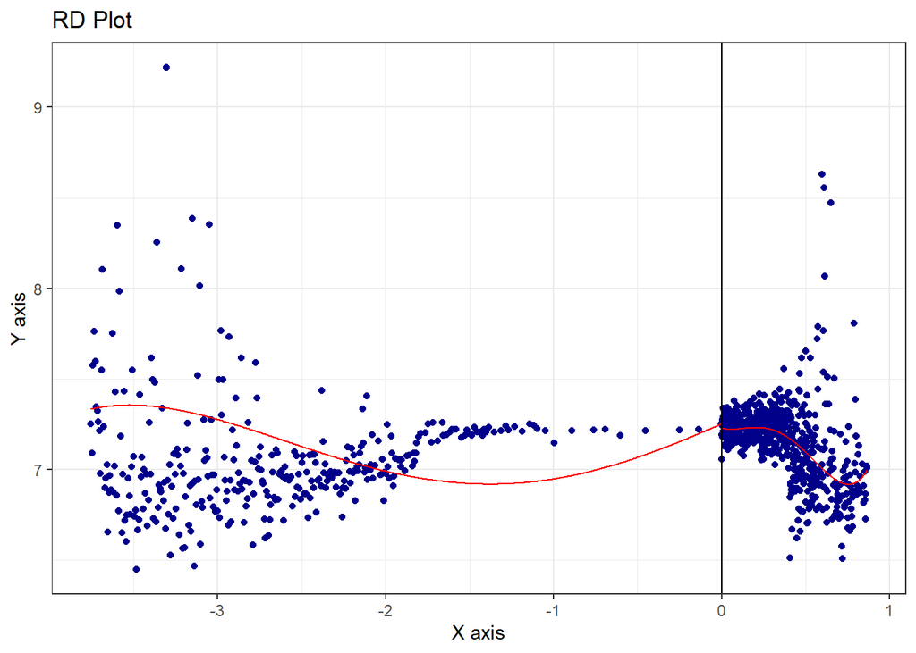

```r
rdrobust::rdplot(y = d_rdd_bivariate$ln_gross_expenditure_pc, x = d_rdd_bivariate$inhabs_rel_to_cutoff)
```

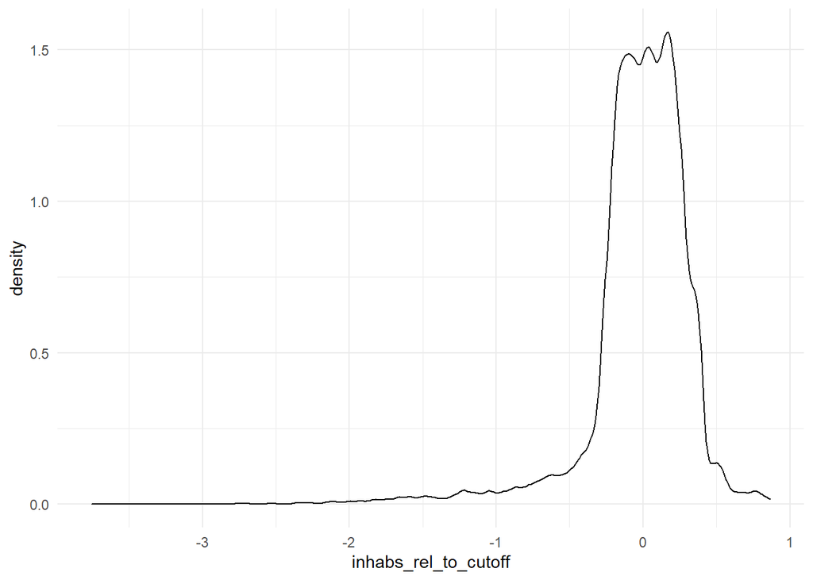

```r
ggplot(data = d_rdd_bivariate) +
  geom_density(aes(inhabs_rel_to_cutoff))
```

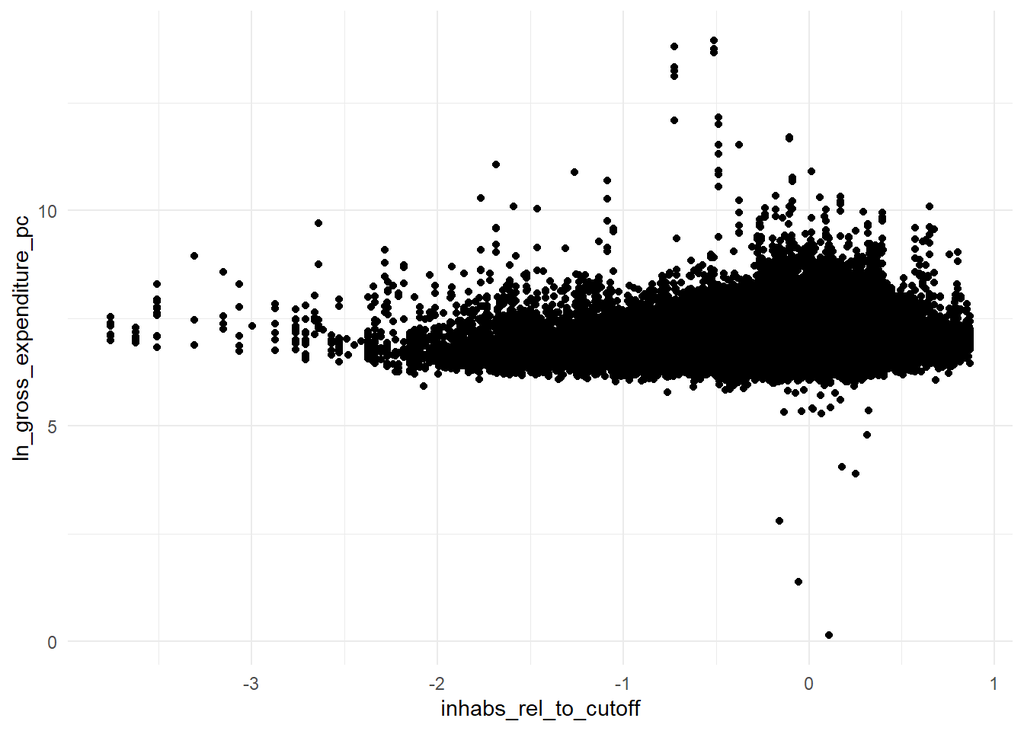

```r
ggplot(data = d_rdd_bivariate) +
  geom_point(aes(x = inhabs_rel_to_cutoff, y = ln_gross_expenditure_pc))
```

Plotting the estimated model from the previous section:

```
## [1] "Mass points detected in the running variable."
```

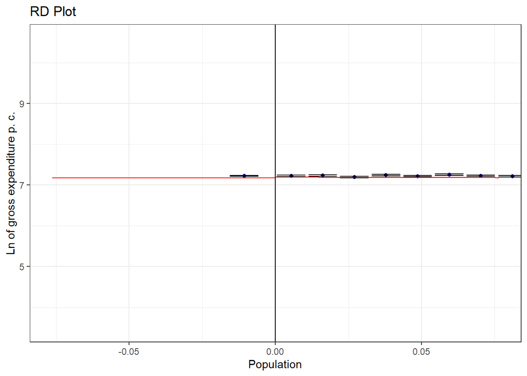

```r
#https://stackoverflow.com/questions/56884210/rdrobust-plotting-graphs-for-local-polynomial-estimation/57614447
rdplot <- rdrobust::rdplot(
  y = d_rdd$ln_gross_expenditure_pc,
  x = d_rdd$inhabs_rel_to_cutoff,
  binselect = "es",
  scale = 5,
  kernel = tolower(rdd_multi_fe$kernel),
  p = rdd_multi_fe$p,
  h = rdd_multi_fe$bws[1],
  covs = model.matrix( ~ d_rdd$inhabitants_treshold_factor + d_rdd$year + d_rdd$state + # FE
                         d_rdd$kreisfreie_stadt + d_rdd$stadt + d_rdd$years_since_last_elec) + # dummy controls
    d_rdd$inh_tot + d_rdd$pop_over65 + d_rdd$unempl_rate + # controls
    d_rdd$total_area_ha + d_rdd$share_working_age, # controls (cont.)
  x.lim = c(-rdd_multi_fe$bws[1], rdd_multi_fe$bws[1]),
  #title = "RD Plot - Senate Elections Data",
  x.label = "Population",
  y.label = "Ln of gross expenditure p. c.",
  ci = 95)
```

```r
rdplot
```

```
## Call: rdplot
##
## Number of Obs.               101409
## Kernel                   Triangular
##
## Number of Obs.                46711           54698
## Eff. Number of Obs.           11368           12020
## Order poly. fit (p)               1               1
## BW poly. fit (h)              0.076           0.076
## Number of bins scale          5.000           5.000
```

to do: Manual plot instead?

to do: fuzzy argument (i. e. treatment indicator) binary; sharp RDD (intention to treat)

### Robustness Checks

The RDD FE model without covariates will be regarded as the baseline model. Hence, write a wrapper function to ease the use of the model:

```r
rdrobust_fe_model <- function(cc = NULL, pp = NULL, qq = NULL, hh = NULL, bb = NULL, kkernel = "tri", bbwselect = "mserd", vvce = "nn") {
  rdrobust::rdrobust(
    y = d_rdd_bivariate$ln_gross_expenditure_pc,
    x = d_rdd_bivariate$inhabs_rel_to_cutoff,
    c = cc,
    fuzzy = d_rdd_bivariate$total_seats,
    cluster = d_rdd_bivariate$inhabitants_treshold_factor,
    covs = model.matrix( ~ d_rdd_bivariate$inhabitants_treshold_factor + d_rdd_bivariate$year + d_rdd_bivariate$state),
    # set parameters to run for robustness tests; set them to rdrobust defaults
    p = pp,
    q = qq,
    h = hh,
    b = bb,
    kernel = kkernel,
    bwselect = bbwselect,
    vce = vvce
  )
}
```

```r
rdd <- rdrobust_fe_model()
```

```
## [1] "Mass points detected in the running variable."
```

```r
summary(rdd) # equal to rdd_bi_fe model
```

```
## Covariate-adjusted Fuzzy RD estimates using local polynomial regression.
##
## Number of Obs.               103618
## BW type                       mserd
## Kernel                   Triangular
## VCE method                       NN
##
## Number of Obs.                48578        55040
## Eff. Number of Obs.            7238         7893
## Order est. (p)                    1            1
## Order bias  (q)                   2            2
## BW est. (h)                   0.050        0.050
## BW bias (b)                   0.157        0.157
## rho (h/b)                     0.317        0.317
## Unique Obs.                    3715         4582
##
## First-stage estimates.
##
## =============================================================================
##         Method     Coef. Std. Err.         z     P>|z|      [ 95% C.I. ]
## =============================================================================
##   Conventional     1.242     0.120    10.351     0.000     [1.007 , 1.477]
##         Robust         -         -     9.706     0.000     [0.952 , 1.434]
## =============================================================================
##
## Treatment effect estimates.
##
## =============================================================================
##         Method     Coef. Std. Err.         z     P>|z|      [ 95% C.I. ]
## =============================================================================
##   Conventional     0.014     0.012     1.173     0.241    [-0.010 , 0.038]
##         Robust         -         -     1.222     0.222    [-0.009 , 0.040]
## =============================================================================
```

#### Different RDD specifications

Vary p, the local polynomial. Conclusions remain. On the first stage, council size jumps by a value somewhat larger than 1 at the threshold (highly statistically significant). The second stage, however, remains insignificant, with some p values around 0.2, the others are (in part way) larger. The coefficient is always slightly positive.

```r
for (vary_p in 0:6) {
  print(paste("polynomial of degree", vary_p))
  rdd <- rdrobust_fe_model(pp = vary_p)
  summary(rdd)
}
```

```
## [1] "polynomial of degree 0"
## [1] "Mass points detected in the running variable."
## Covariate-adjusted Fuzzy RD estimates using local polynomial regression.
##
## Number of Obs.               103618
## BW type                       mserd
## Kernel                   Triangular
## VCE method                       NN
##
## Number of Obs.                48578        55040
## Eff. Number of Obs.            3006         3352
## Order est. (p)                    0            0
## Order bias  (q)                   1            1
## BW est. (h)                   0.020        0.020
## BW bias (b)                   0.209        0.209
## rho (h/b)                     0.098        0.098
## Unique Obs.                    3715         4582
##
## First-stage estimates.
##
## =============================================================================
##         Method     Coef. Std. Err.         z     P>|z|      [ 95% C.I. ]
## =============================================================================
##   Conventional     1.517     0.087    17.487     0.000     [1.347 , 1.687]
##         Robust         -         -    16.303     0.000     [1.285 , 1.636]
## =============================================================================
##
## Treatment effect estimates.
##
## =============================================================================
##         Method     Coef. Std. Err.         z     P>|z|      [ 95% C.I. ]
## =============================================================================
##   Conventional     0.009     0.006     1.451     0.147    [-0.003 , 0.020]
##         Robust         -         -     1.447     0.148    [-0.003 , 0.020]
## =============================================================================
## [1] "polynomial of degree 1"
## [1] "Mass points detected in the running variable."
## Covariate-adjusted Fuzzy RD estimates using local polynomial regression.
##
## Number of Obs.               103618
```

[output cut: 190 more lines]

```
## =============================================================================
##         Method     Coef. Std. Err.         z     P>|z|      [ 95% C.I. ]
## =============================================================================
##   Conventional     1.054     0.152     6.929     0.000     [0.756 , 1.353]
##         Robust         -         -     6.427     0.000     [0.712 , 1.338]
## =============================================================================
##
## Treatment effect estimates.
##
## =============================================================================
##         Method     Coef. Std. Err.         z     P>|z|      [ 95% C.I. ]
## =============================================================================
##   Conventional     0.005     0.024     0.213     0.832    [-0.041 , 0.051]
##         Robust         -         -     0.024     0.981    [-0.047 , 0.048]
## =============================================================================
```

Vary q, the “local-polynomial used to construct the bias correction”. Conclusions similar to varying p: Higly significant first stage across all `q`s, non-significant second stage (p values as low as 0.2) and positive around 1%.

```r
for (vary_q in 2:6) {
  print(paste("polynomial of degree", vary_q))
  rdd <- rdrobust_fe_model(qq = vary_q)
  summary(rdd)
}
```

```
## [1] "polynomial of degree 2"
## [1] "Mass points detected in the running variable."
## Covariate-adjusted Fuzzy RD estimates using local polynomial regression.
##
## Number of Obs.               103618
## BW type                       mserd
## Kernel                   Triangular
## VCE method                       NN
##
## Number of Obs.                48578        55040
## Eff. Number of Obs.            7238         7893
## Order est. (p)                    1            1
## Order bias  (q)                   2            2
## BW est. (h)                   0.050        0.050
## BW bias (b)                   0.157        0.157
## rho (h/b)                     0.317        0.317
## Unique Obs.                    3715         4582
##
## First-stage estimates.
##
## =============================================================================
##         Method     Coef. Std. Err.         z     P>|z|      [ 95% C.I. ]
## =============================================================================
##   Conventional     1.242     0.120    10.351     0.000     [1.007 , 1.477]
##         Robust         -         -     9.706     0.000     [0.952 , 1.434]
## =============================================================================
##
## Treatment effect estimates.
##
## =============================================================================
##         Method     Coef. Std. Err.         z     P>|z|      [ 95% C.I. ]
## =============================================================================
##   Conventional     0.014     0.012     1.173     0.241    [-0.010 , 0.038]
##         Robust         -         -     1.222     0.222    [-0.009 , 0.040]
## =============================================================================
## [1] "polynomial of degree 3"
## [1] "Mass points detected in the running variable."
## Covariate-adjusted Fuzzy RD estimates using local polynomial regression.
##
## Number of Obs.               103618
```

[output cut: 120 more lines]

```
## =============================================================================
##         Method     Coef. Std. Err.         z     P>|z|      [ 95% C.I. ]
## =============================================================================
##   Conventional     1.141     0.132     8.645     0.000     [0.882 , 1.399]
##         Robust         -         -     7.580     0.000     [0.768 , 1.304]
## =============================================================================
##
## Treatment effect estimates.
##
## =============================================================================
##         Method     Coef. Std. Err.         z     P>|z|      [ 95% C.I. ]
## =============================================================================
##   Conventional     0.007     0.012     0.644     0.520    [-0.015 , 0.030]
##         Robust         -         -     0.810     0.418    [-0.014 , 0.034]
## =============================================================================
```

Vary kernel: No large differences between kernels.

```r
for (vary_kernel in c("tri", "epa", "uni")) {
  print(paste("kernel:", vary_kernel))
  rdd <- rdrobust_fe_model(kkernel = vary_kernel)
  summary(rdd)
}
```

```
## [1] "kernel: tri"
## [1] "Mass points detected in the running variable."
## Covariate-adjusted Fuzzy RD estimates using local polynomial regression.
##
## Number of Obs.               103618
## BW type                       mserd
## Kernel                   Triangular
## VCE method                       NN
##
## Number of Obs.                48578        55040
## Eff. Number of Obs.            7238         7893
## Order est. (p)                    1            1
## Order bias  (q)                   2            2
## BW est. (h)                   0.050        0.050
## BW bias (b)                   0.157        0.157
## rho (h/b)                     0.317        0.317
## Unique Obs.                    3715         4582
##
## First-stage estimates.
##
## =============================================================================
##         Method     Coef. Std. Err.         z     P>|z|      [ 95% C.I. ]
## =============================================================================
##   Conventional     1.242     0.120    10.351     0.000     [1.007 , 1.477]
##         Robust         -         -     9.706     0.000     [0.952 , 1.434]
## =============================================================================
##
## Treatment effect estimates.
##
## =============================================================================
##         Method     Coef. Std. Err.         z     P>|z|      [ 95% C.I. ]
## =============================================================================
##   Conventional     0.014     0.012     1.173     0.241    [-0.010 , 0.038]
##         Robust         -         -     1.222     0.222    [-0.009 , 0.040]
## =============================================================================
## [1] "kernel: epa"
## [1] "Mass points detected in the running variable."
## Covariate-adjusted Fuzzy RD estimates using local polynomial regression.
##
## Number of Obs.               103618
```

[output cut: 50 more lines]

```
## =============================================================================
##         Method     Coef. Std. Err.         z     P>|z|      [ 95% C.I. ]
## =============================================================================
##   Conventional     1.190     0.158     7.518     0.000     [0.880 , 1.501]
##         Robust         -         -     7.035     0.000     [0.802 , 1.422]
## =============================================================================
##
## Treatment effect estimates.
##
## =============================================================================
##         Method     Coef. Std. Err.         z     P>|z|      [ 95% C.I. ]
## =============================================================================
##   Conventional     0.008     0.014     0.598     0.550    [-0.019 , 0.036]
##         Robust         -         -     0.638     0.523    [-0.019 , 0.038]
## =============================================================================
```

Vary variance-covariance matrix: The `hc` vce appear extremely similar. Conclusions, however, are not altered.

```r
for (vary_vcov in c("nn", "hc0", "hc1", "hc2", "hc3")) {
  print(paste("vce:", vary_vcov))
  rdd <- rdrobust_fe_model(vvce = vary_vcov)
  summary(rdd)
}
```

```
## [1] "vce: nn"
## [1] "Mass points detected in the running variable."
## Covariate-adjusted Fuzzy RD estimates using local polynomial regression.
##
## Number of Obs.               103618
## BW type                       mserd
## Kernel                   Triangular
## VCE method                       NN
##
## Number of Obs.                48578        55040
## Eff. Number of Obs.            7238         7893
## Order est. (p)                    1            1
## Order bias  (q)                   2            2
## BW est. (h)                   0.050        0.050
## BW bias (b)                   0.157        0.157
## rho (h/b)                     0.317        0.317
## Unique Obs.                    3715         4582
##
## First-stage estimates.
##
## =============================================================================
##         Method     Coef. Std. Err.         z     P>|z|      [ 95% C.I. ]
## =============================================================================
##   Conventional     1.242     0.120    10.351     0.000     [1.007 , 1.477]
##         Robust         -         -     9.706     0.000     [0.952 , 1.434]
## =============================================================================
##
## Treatment effect estimates.
##
## =============================================================================
##         Method     Coef. Std. Err.         z     P>|z|      [ 95% C.I. ]
## =============================================================================
##   Conventional     0.014     0.012     1.173     0.241    [-0.010 , 0.038]
##         Robust         -         -     1.222     0.222    [-0.009 , 0.040]
## =============================================================================
## [1] "vce: hc0"
## [1] "Mass points detected in the running variable."
## Covariate-adjusted Fuzzy RD estimates using local polynomial regression.
##
## Number of Obs.               103618
```

[output cut: 120 more lines]

```
## =============================================================================
##         Method     Coef. Std. Err.         z     P>|z|      [ 95% C.I. ]
## =============================================================================
##   Conventional     1.315     0.116    11.345     0.000     [1.088 , 1.543]
##         Robust         -         -     9.904     0.000     [0.997 , 1.489]
## =============================================================================
##
## Treatment effect estimates.
##
## =============================================================================
##         Method     Coef. Std. Err.         z     P>|z|      [ 95% C.I. ]
## =============================================================================
##   Conventional     0.014     0.010     1.376     0.169    [-0.006 , 0.034]
##         Robust         -         -     1.436     0.151    [-0.006 , 0.037]
## =============================================================================
```

#### Sensitivity analysis

```r
for (vary_h in seq(0.02, 0.2, 0.03)) {
  print(paste("polynomial of degree", vary_h))
  rdd <- rdrobust_fe_model(hh = vary_h)
  summary(rdd)
}
```

```
## [1] "polynomial of degree 0.02"
## Covariate-adjusted Fuzzy RD estimates using local polynomial regression.
##
## Number of Obs.               103618
## BW type                      Manual
## Kernel                   Triangular
## VCE method                       NN
##
## Number of Obs.                48578        55040
## Eff. Number of Obs.            2904         3310
## Order est. (p)                    1            1
## Order bias  (q)                   2            2
## BW est. (h)                   0.020        0.020
## BW bias (b)                   0.020        0.020
## rho (h/b)                     1.000        1.000
## Unique Obs.                   48578        55040
##
## First-stage estimates.
##
## =============================================================================
##         Method     Coef. Std. Err.         z     P>|z|      [ 95% C.I. ]
## =============================================================================
##   Conventional     1.053     0.167     6.318     0.000     [0.726 , 1.379]
##         Robust         -         -     4.118     0.000     [0.584 , 1.643]
## =============================================================================
##
## Treatment effect estimates.
##
## =============================================================================
##         Method     Coef. Std. Err.         z     P>|z|      [ 95% C.I. ]
## =============================================================================
##   Conventional     0.010     0.012     0.824     0.410    [-0.014 , 0.035]
##         Robust         -         -    -0.547     0.584    [-0.042 , 0.024]
## =============================================================================
## [1] "polynomial of degree 0.05"
## Covariate-adjusted Fuzzy RD estimates using local polynomial regression.
##
## Number of Obs.               103618
## BW type                      Manual
## Kernel                   Triangular
```

[output cut: 183 more lines]

```
## =============================================================================
##         Method     Coef. Std. Err.         z     P>|z|      [ 95% C.I. ]
## =============================================================================
##   Conventional     2.084     0.083    25.203     0.000     [1.922 , 2.246]
##         Robust         -         -    16.797     0.000     [1.352 , 1.710]
## =============================================================================
##
## Treatment effect estimates.
##
## =============================================================================
##         Method     Coef. Std. Err.         z     P>|z|      [ 95% C.I. ]
## =============================================================================
##   Conventional     0.006     0.003     1.648     0.099    [-0.001 , 0.012]
##         Robust         -         -     2.643     0.008     [0.004 , 0.026]
## =============================================================================
```

Apparently, the bandwidth `b` cannot be set manually. Perhaps change `rho` parameter or set `b` manually and `b` via the `bwselect()` function.

```r
for (vary_b in seq(0.15, 0.45, 0.075)) {
  print(paste("RDD with bandwidth b =", vary_b))
  rdd <- rdrobust_fe_model(bb = vary_b)
  summary(rdd)
}
```

```r
rdd_vary_window <-
  tibble(window = "", point_estimate = "", ci_lower = "", ci_upper = "") %>%
  mutate(across(everything(), as.numeric))
for (vary_window in seq(0.01, 0.25, 0.01)) {
  print(paste("RDD with window: ", vary_window))
  df <- d_rdd_bivariate %>%
    filter(closest <= vary_window)
  str(vary_window)
  rdd <-
    rdrobust::rdrobust(
      y = df$ln_gross_expenditure_pc,
      x = df$inhabs_rel_to_cutoff,
      fuzzy = df$total_seats,
      cluster = df$inhabitants_treshold_factor,
      covs = model.matrix( ~ df$inhabitants_treshold_factor + df$year + df$state),
      h = 10 # 10 is larger than any absolute value of the running variable => use all observations
  )
  summary(rdd)
  rdd_vary_window <- rdd_vary_window %>%
    dplyr::add_row(
      window = vary_window,
      point_estimate = rdd$coef[1],
      ci_lower = rdd$ci[3,1],
      ci_upper = rdd$ci[3,2]
  )
}
```

```
## [1] "RDD with window:  0.01"
##  num 0.01
## Covariate-adjusted Fuzzy RD estimates using local polynomial regression.
##
## Number of Obs.                 1036
## BW type                      Manual
## Kernel                   Triangular
## VCE method                       NN
##
## Number of Obs.                  440          596
## Eff. Number of Obs.             440          596
## Order est. (p)                    1            1
## Order bias  (q)                   2            2
## BW est. (h)                  10.000       10.000
## BW bias (b)                  10.000       10.000
## rho (h/b)                     1.000        1.000
## Unique Obs.                     440          596
##
## First-stage estimates.
##
## =============================================================================
##         Method     Coef. Std. Err.         z     P>|z|      [ 95% C.I. ]
## =============================================================================
##   Conventional     1.984     0.329     6.034     0.000     [1.340 , 2.629]
##         Robust         -         -     5.794     0.000     [2.016 , 4.077]
## =============================================================================
##
## Treatment effect estimates.
##
## =============================================================================
##         Method     Coef. Std. Err.         z     P>|z|      [ 95% C.I. ]
## =============================================================================
##   Conventional    -0.060     0.019    -3.155     0.002    [-0.097 , -0.023]
##         Robust         -         -    -1.856     0.064    [-0.089 , 0.002]
## =============================================================================
## [1] "RDD with window:  0.02"
##  num 0.02
## Covariate-adjusted Fuzzy RD estimates using local polynomial regression.
##
## Number of Obs.                 2072
```

[output cut: 820 more lines]

```
## =============================================================================
##         Method     Coef. Std. Err.         z     P>|z|      [ 95% C.I. ]
## =============================================================================
##   Conventional     1.650     0.081    20.485     0.000     [1.492 , 1.808]
##         Robust         -         -    10.035     0.000     [0.941 , 1.398]
## =============================================================================
##
## Treatment effect estimates.
##
## =============================================================================
##         Method     Coef. Std. Err.         z     P>|z|      [ 95% C.I. ]
## =============================================================================
##   Conventional     0.019     0.007     2.624     0.009     [0.005 , 0.032]
##         Robust         -         -     0.943     0.346    [-0.012 , 0.035]
## =============================================================================
```

```r
rdd_vary_window <- rdd_vary_window %>% drop_na()
```

Plot windows. Coefficients and CIs need not overlap because standard coefficients are paired with robust-corrected CIs.

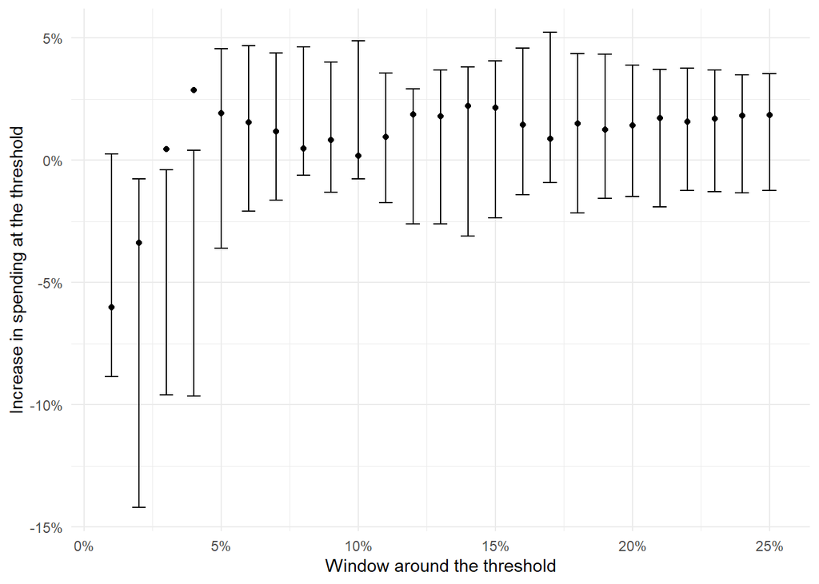

```r
ggplot2::ggplot(data = rdd_vary_window, aes(x = window, y = point_estimate)) +
  geom_point(size = 1.5) +
  geom_errorbar(aes(ymin = ci_lower, ymax = ci_upper), width = 0.005) +
  scale_x_continuous(labels = scales::percent) +
  scale_y_continuous(labels = scales::percent) +
  labs(x = "Window around the threshold", y = "Increase in spending at the threshold")
```

```r
ggsave(filename = "plots/rdrobust_bw_window.pdf", width = 6, height = 6*9/16)
```

Different `rdbwselect` options: Most bandwidth selection algorithms yield similar results to the default one. One or two, however, gain statistical significance for the regressor of interest by virtue of a larger bandwidth.

```r
rdd_vary_bwselect <-
  tibble(bw_sel_algo = "", point_estimate = "", ci_lower = "", ci_upper = "") %>%
  mutate(across(2:4, as.numeric))
for (vary_bwselect in c("mserd", "msetwo", "msesum", "msecomb1", "msecomb2", "cerrd", "certwo", "cersum", "cercomb1", "cercomb2")) {
  print(paste("Bandwidth selection algorithm:", vary_bwselect))
  rdd <- rdrobust_fe_model(bbwselect = vary_bwselect)
  summary(rdd)
  rdd_vary_bwselect <- rdd_vary_bwselect %>%
    dplyr::add_row(
      bw_sel_algo = vary_bwselect,
      point_estimate = rdd$coef[1],
      ci_lower = rdd$ci[3,1],
      ci_upper = rdd$ci[3,2]
  )
}
```

```
## [1] "Bandwidth selection algorithm: mserd"
## [1] "Mass points detected in the running variable."
## Covariate-adjusted Fuzzy RD estimates using local polynomial regression.
##
## Number of Obs.               103618
## BW type                       mserd
## Kernel                   Triangular
## VCE method                       NN
##
## Number of Obs.                48578        55040
## Eff. Number of Obs.            7238         7893
## Order est. (p)                    1            1
## Order bias  (q)                   2            2
## BW est. (h)                   0.050        0.050
## BW bias (b)                   0.157        0.157
## rho (h/b)                     0.317        0.317
## Unique Obs.                    3715         4582
##
## First-stage estimates.
##
## =============================================================================
##         Method     Coef. Std. Err.         z     P>|z|      [ 95% C.I. ]
## =============================================================================
##   Conventional     1.242     0.120    10.351     0.000     [1.007 , 1.477]
##         Robust         -         -     9.706     0.000     [0.952 , 1.434]
## =============================================================================
##
## Treatment effect estimates.
##
## =============================================================================
##         Method     Coef. Std. Err.         z     P>|z|      [ 95% C.I. ]
## =============================================================================
##   Conventional     0.014     0.012     1.173     0.241    [-0.010 , 0.038]
##         Robust         -         -     1.222     0.222    [-0.009 , 0.040]
## =============================================================================
## [1] "Bandwidth selection algorithm: msetwo"
## [1] "Mass points detected in the running variable."
## Covariate-adjusted Fuzzy RD estimates using local polynomial regression.
##
## Number of Obs.               103618
```

[output cut: 295 more lines]

```
## =============================================================================
##         Method     Coef. Std. Err.         z     P>|z|      [ 95% C.I. ]
## =============================================================================
##   Conventional     1.207     0.130     9.303     0.000     [0.952 , 1.461]
##         Robust         -         -     8.927     0.000     [0.915 , 1.430]
## =============================================================================
##
## Treatment effect estimates.
##
## =============================================================================
##         Method     Coef. Std. Err.         z     P>|z|      [ 95% C.I. ]
## =============================================================================
##   Conventional     0.009     0.012     0.768     0.443    [-0.014 , 0.033]
##         Robust         -         -     0.802     0.423    [-0.014 , 0.034]
## =============================================================================
```

```r
rdd_vary_bwselect <- rdd_vary_bwselect %>% drop_na()
```

Plot bandwidth selection algorithms. Coefficients and CIs need not overlap because standard coefficients are paired with robust-corrected CIs. Note: In general may be a good idea, but hard to explain all bandwidth selectors in the paper just for the purpose of this plot…

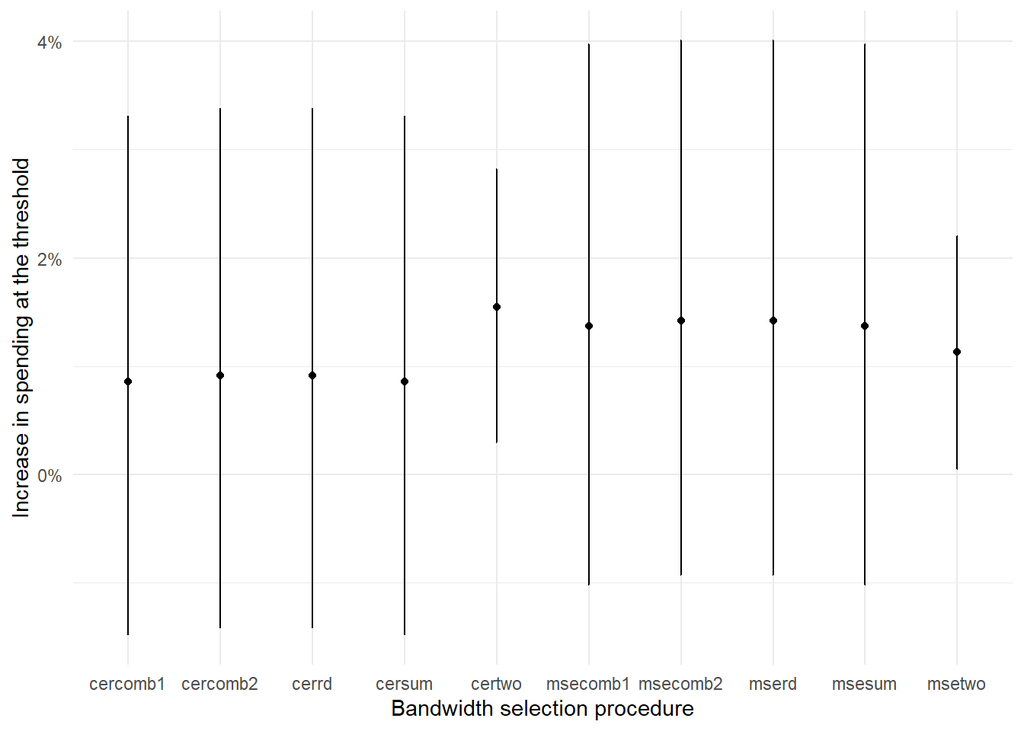

```r
ggplot2::ggplot(data = rdd_vary_bwselect, aes(x = bw_sel_algo, y = point_estimate)) +
  geom_point(size = 1.5) +
  geom_errorbar(aes(ymin = ci_lower, ymax = ci_upper), width = 0.005) +
  scale_y_continuous(labels = scales::percent) +
  labs(x = "Bandwidth selection procedure", y = "Increase in spending at the threshold")
```

```r
rm(list=ls(pattern="^panel_"), rdd)
```

#### Dropping confounded thresholds

Dropping confounded thresholds as determined by my own legal research: The conclusions are quite similar for both “Höhmann’s” and “my” thresholds – the effect of council size is small and positive (in the really small single-digits) but nonsignificant for both counfounded as well as nonconfounded thresholds.

Note: (to do) maybe you could also solve this by interacting `clean_dis_acc_to_my_research`.

```r
# Effect for confounded thresholds
df <- d_rdd_bivariate %>%
    filter(clean_disc_acc_to_my_research == 0)
rdd <-
  rdrobust::rdrobust(
    y = df$ln_gross_expenditure_pc,
    x = df$inhabs_rel_to_cutoff,
    fuzzy = df$total_seats,
    cluster = df$inhabitants_treshold_factor,
    covs = model.matrix(~ df$inhabitants_treshold_factor + df$year + df$state)
  )
```

```
## [1] "Mass points detected in the running variable."
```

```r
summary(rdd)
```

```
## Covariate-adjusted Fuzzy RD estimates using local polynomial regression.
##
## Number of Obs.                84943
## BW type                       mserd
## Kernel                   Triangular
## VCE method                       NN
##
## Number of Obs.                39741        45202
## Eff. Number of Obs.            7976         8307
## Order est. (p)                    1            1
## Order bias  (q)                   2            2
## BW est. (h)                   0.062        0.062
## BW bias (b)                   0.200        0.200
## rho (h/b)                     0.311        0.311
## Unique Obs.                    3195         4040
##
## First-stage estimates.
##
## =============================================================================
##         Method     Coef. Std. Err.         z     P>|z|      [ 95% C.I. ]
## =============================================================================
##   Conventional     1.176     0.115    10.230     0.000     [0.951 , 1.401]
##         Robust         -         -     9.589     0.000     [0.894 , 1.354]
## =============================================================================
##
## Treatment effect estimates.
##
## =============================================================================
##         Method     Coef. Std. Err.         z     P>|z|      [ 95% C.I. ]
## =============================================================================
##   Conventional     0.016     0.013     1.224     0.221    [-0.010 , 0.042]
##         Robust         -         -     1.291     0.197    [-0.009 , 0.045]
## =============================================================================
```

```r
# Effect for noncounfounded thresholds
df <- d_rdd_bivariate %>%
    filter(clean_disc_acc_to_my_research == 1)
rdd <-
  rdrobust::rdrobust(
    y = df$ln_gross_expenditure_pc,
    x = df$inhabs_rel_to_cutoff,
    fuzzy = df$total_seats,
    cluster = df$inhabitants_treshold_factor,
    covs = model.matrix(~ df$inhabitants_treshold_factor + df$year + df$state)
  )
```

```
## [1] "Mass points detected in the running variable."
```

```r
summary(rdd)
```

```
## Covariate-adjusted Fuzzy RD estimates using local polynomial regression.
##
## Number of Obs.                18675
## BW type                       mserd
## Kernel                   Triangular
## VCE method                       NN
##
## Number of Obs.                 8837         9838
## Eff. Number of Obs.            1129         1363
## Order est. (p)                    1            1
## Order bias  (q)                   2            2
## BW est. (h)                   0.055        0.055
## BW bias (b)                   0.173        0.173
## rho (h/b)                     0.318        0.318
## Unique Obs.                    1191         1403
##
## First-stage estimates.
##
## =============================================================================
##         Method     Coef. Std. Err.         z     P>|z|      [ 95% C.I. ]
## =============================================================================
##   Conventional     2.434     0.151    16.171     0.000     [2.139 , 2.729]
##         Robust         -         -    15.346     0.000     [2.072 , 2.679]
## =============================================================================
##
## Treatment effect estimates.
##
## =============================================================================
##         Method     Coef. Std. Err.         z     P>|z|      [ 95% C.I. ]
## =============================================================================
##   Conventional     0.006     0.010     0.570     0.569    [-0.013 , 0.024]
##         Robust         -         -     0.680     0.497    [-0.013 , 0.026]
## =============================================================================
```

Dropping confounded thresholds as determined by Höhmann (2017):

```r
# Effect for confounded thresholds
df <- d_rdd_bivariate %>%
    filter(clean_disc_acc_Höhmann == 0)
rdd <-
  rdrobust::rdrobust(
    y = df$ln_gross_expenditure_pc,
    x = df$inhabs_rel_to_cutoff,
    fuzzy = df$total_seats,
    cluster = df$inhabitants_treshold_factor,
    covs = model.matrix(~ df$inhabitants_treshold_factor + df$year + df$state)
  )
```

```
## [1] "Mass points detected in the running variable."
```

```r
summary(rdd)
```

```
## Covariate-adjusted Fuzzy RD estimates using local polynomial regression.
##
## Number of Obs.                39437
## BW type                       mserd
## Kernel                   Triangular
## VCE method                       NN
##
## Number of Obs.                18238        21199
## Eff. Number of Obs.            7782         8155
## Order est. (p)                    1            1
## Order bias  (q)                   2            2
## BW est. (h)                   0.127        0.127
## BW bias (b)                   0.260        0.260
## rho (h/b)                     0.487        0.487
## Unique Obs.                    2703         3394
##
## First-stage estimates.
##
## =============================================================================
##         Method     Coef. Std. Err.         z     P>|z|      [ 95% C.I. ]
## =============================================================================
##   Conventional     1.909     0.158    12.057     0.000     [1.598 , 2.219]
##         Robust         -         -    10.473     0.000     [1.469 , 2.145]
## =============================================================================
##
## Treatment effect estimates.
##
## =============================================================================
##         Method     Coef. Std. Err.         z     P>|z|      [ 95% C.I. ]
## =============================================================================
##   Conventional     0.006     0.005     1.282     0.200    [-0.003 , 0.016]
##         Robust         -         -     1.019     0.308    [-0.005 , 0.017]
## =============================================================================
```

```r
# Effect for noncounfounded thresholds
df <- d_rdd_bivariate %>%
    filter(clean_disc_acc_Höhmann == 1)
rdd <-
  rdrobust::rdrobust(
    y = df$ln_gross_expenditure_pc,
    x = df$inhabs_rel_to_cutoff,
    fuzzy = df$total_seats,
    cluster = df$inhabitants_treshold_factor,
    covs = model.matrix(~ df$inhabitants_treshold_factor + df$year + df$state)
  )
```

```
## [1] "Mass points detected in the running variable."
```

```r
summary(rdd)
```

```
## Covariate-adjusted Fuzzy RD estimates using local polynomial regression.
##
## Number of Obs.                63241
## BW type                       mserd
## Kernel                   Triangular
## VCE method                       NN
##
## Number of Obs.                30064        33177
## Eff. Number of Obs.            5302         5462
## Order est. (p)                    1            1
## Order bias  (q)                   2            2
## BW est. (h)                   0.060        0.060
## BW bias (b)                   0.201        0.201
## rho (h/b)                     0.301        0.301
## Unique Obs.                    2051         2412
##
## First-stage estimates.
##
## =============================================================================
##         Method     Coef. Std. Err.         z     P>|z|      [ 95% C.I. ]
## =============================================================================
##   Conventional     1.307     0.108    12.051     0.000     [1.095 , 1.520]
##         Robust         -         -    11.222     0.000     [1.029 , 1.464]
## =============================================================================
##
## Treatment effect estimates.
##
## =============================================================================
##         Method     Coef. Std. Err.         z     P>|z|      [ 95% C.I. ]
## =============================================================================
##   Conventional     0.022     0.018     1.215     0.224    [-0.014 , 0.058]
##         Robust         -         -     1.351     0.177    [-0.012 , 0.063]
## =============================================================================
```

#### Placebo thresholds

First attempt

```r
rdd_placebo <-
  tibble(placebo_c = "", point_estimate = "", ci_lower = "", ci_upper = "", p = "", effective_n = "") %>%
  mutate(across(everything(), as.numeric))
vector <- seq(from = -(2+2/3), to = 2/3, by = 1/6) # Choose vector of arbitrary placebo cutoffs
#vector <- vector[!vector %in% (-2-1/3)]
vector <- vector[-c(3, 21)] # Drop cutoffs that yield errors
for (i in vector) {
  print(paste("Cutoff at:", i))
  rdd <- rdrobust_fe_model(cc = i)
  #summary(rdd)
  rdd_placebo <- rdd_placebo %>%
    dplyr::add_row(
      placebo_c = i,
      point_estimate = rdd$coef[1],
      ci_lower = rdd$ci[3,1],
      ci_upper = rdd$ci[3,2],
      p = rdd$pv[3],
      effective_n = sum(rdd$N_h)
  )
}
```

```
## [1] "Cutoff at: -2.66666666666667"
## [1] "Mass points detected in the running variable."
## [1] "Cutoff at: -2.5"
## [1] "Mass points detected in the running variable."
## [1] "Cutoff at: -2.16666666666667"
## [1] "Mass points detected in the running variable."
## [1] "Cutoff at: -2"
## [1] "Mass points detected in the running variable."
## [1] "Cutoff at: -1.83333333333333"
## [1] "Mass points detected in the running variable."
## [1] "Cutoff at: -1.66666666666667"
## [1] "Mass points detected in the running variable."
## [1] "Cutoff at: -1.5"
## [1] "Mass points detected in the running variable."
## [1] "Cutoff at: -1.33333333333333"
```

[output cut: 23 more lines]

```r
rdd_placebo <- rdd_placebo %>% drop_na()
```

Visualization of placebo cutoffs:

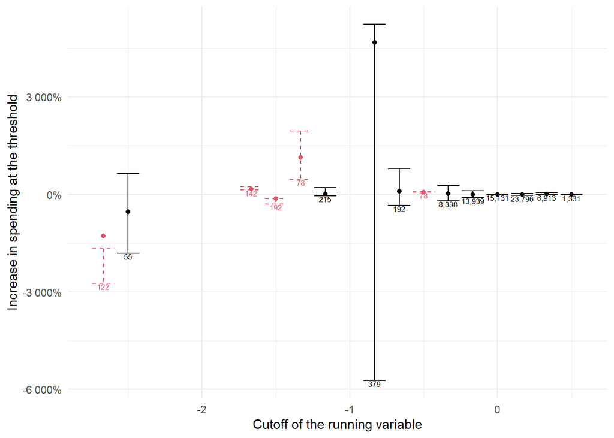

```r
df <- rdd_placebo %>%
  #tidyr::drop_na() %>%
  filter(abs(ci_upper) < 100 | abs(ci_lower) < 100) %>%
  mutate(effective_n = trimws(format(effective_n, big.mark = ",") ) ) # add big mark
ggplot2::ggplot(df) +
  geom_point(aes(x = placebo_c, y = point_estimate), size = 1.5, colour = ifelse(df$p <= 0.05, 2, 1)) +
  geom_errorbar(aes(x = placebo_c, ymin = ci_lower, ymax = ci_upper),
                colour = ifelse(df$p <= 0.05, 2, 1),
                linetype = ifelse(df$p <= 0.05, 2, 1)) +
  geom_text(aes(x = placebo_c, y = ci_lower, label = effective_n),
            colour = ifelse(df$p <= 0.05, 2, 1), vjust = 1, size = 2.3, check_overlap = TRUE) +
  scale_y_continuous(labels = scales::percent) +
  labs(x = "Cutoff of the running variable", y = "Increase in spending at the threshold")
```

```r
ggsave(filename = "plots/rdrobust_placebo_wide.pdf", width = 6, height = 6*9/16)
rm(df, vector)
```

Second attempt: Regular cutoffs within the inter-quartile range.

```r
rdd_placebo <-
  tibble(placebo_c = "", point_estimate = "", ci_lower = "", ci_upper = "", p = "", effective_n = "") %>%
  mutate(across(everything(), as.numeric))
vector <- seq(from = (-0.15), to = (0.18), by = 0.03) # Choose vector of arbitrary placebo cutoffs
for (i in vector) {
  print(paste("Cutoff at:", i))
  rdd <- rdrobust_fe_model(cc = i)
  #summary(rdd)
  rdd_placebo <- rdd_placebo %>%
    dplyr::add_row(
      placebo_c = i,
      point_estimate = rdd$coef[1],
      ci_lower = rdd$ci[3,1],
      ci_upper = rdd$ci[3,2],
      p = rdd$pv[3],
      effective_n = sum(rdd$N_h)
  )
}
```

```
## [1] "Cutoff at: -0.15"
## [1] "Mass points detected in the running variable."
## [1] "Cutoff at: -0.12"
## [1] "Mass points detected in the running variable."
## [1] "Cutoff at: -0.09"
## [1] "Mass points detected in the running variable."
## [1] "Cutoff at: -0.06"
## [1] "Mass points detected in the running variable."
## [1] "Cutoff at: -0.03"
## [1] "Mass points detected in the running variable."
## [1] "Cutoff at: 0"
## [1] "Mass points detected in the running variable."
## [1] "Cutoff at: 0.03"
## [1] "Mass points detected in the running variable."
## [1] "Cutoff at: 0.06"
## [1] "Mass points detected in the running variable."
## [1] "Cutoff at: 0.09"
## [1] "Mass points detected in the running variable."
## [1] "Cutoff at: 0.12"
## [1] "Mass points detected in the running variable."
## [1] "Cutoff at: 0.15"
## [1] "Mass points detected in the running variable."
## [1] "Cutoff at: 0.18"
## [1] "Mass points detected in the running variable."
```

```r
rdd_placebo <- rdd_placebo %>% drop_na()
```

Visualization of placebo cutoffs:

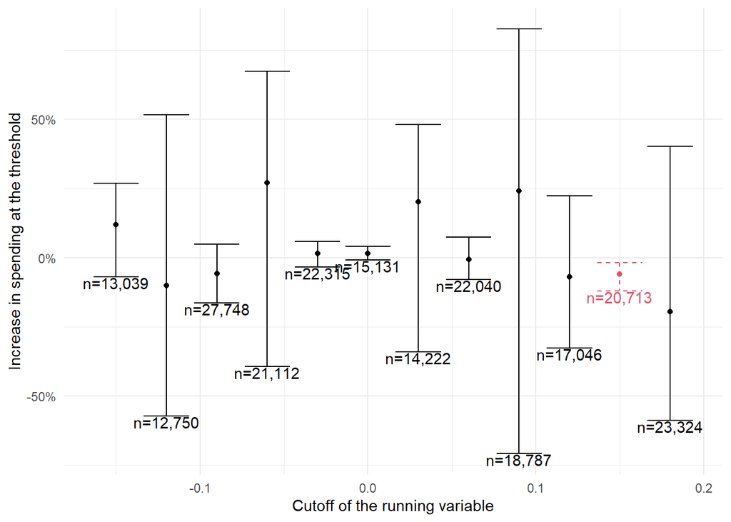

```r
df <- rdd_placebo %>%
  #tidyr::drop_na() %>%
  #filter(abs(ci_upper) < 100 | abs(ci_lower) < 100) %>%
  mutate(effective_n = paste0("n=", trimws(format(effective_n, big.mark = ",") ) ) ) # add big mark
ggplot2::ggplot(df) +
  geom_point(aes(x = placebo_c, y = point_estimate), size = 1.5, colour = ifelse(df$p <= 0.05, 2, 1)) +
  geom_errorbar(aes(x = placebo_c, ymin = ci_lower, ymax = ci_upper),
                colour = ifelse(df$p <= 0.05, 2, 1),
                linetype = ifelse(df$p <= 0.05, 2, 1)) +
  geom_text(aes(x = placebo_c, y = ci_lower, label = effective_n),
            colour = ifelse(df$p <= 0.05, 2, 1), vjust = 1) +
  scale_y_continuous(labels = scales::percent) +
  labs(x = "Cutoff of the running variable", y = "Increase in spending at the threshold")
```

```r
ggsave(filename = "plots/rdrobust_placebo1.pdf", width = 6, height = 6*9/16)
rm(df, vector)
```

Third attempt: Random cutoffs within the inter-quartile range.

```r
rdd_placebo <-
  tibble(placebo_c = "", point_estimate = "", ci_lower = "", ci_upper = "", p = "", effective_n = "") %>%
  mutate(across(everything(), as.numeric))
set.seed(1234)
vector <- runif(n = 10, min = -0.15, max = 0.18) # Choose vector of random placebo cutoffs
for (i in vector) {
  print(paste("Cutoff at:", i))
  rdd <- rdrobust_fe_model(cc = i)
  #summary(rdd)
  rdd_placebo <- rdd_placebo %>%
    dplyr::add_row(
      placebo_c = i,
      point_estimate = rdd$coef[1],
      ci_lower = rdd$ci[3,1],
      ci_upper = rdd$ci[3,2],
      p = rdd$pv[3],
      effective_n = sum(rdd$N_h)
  )
}
```

```
## [1] "Cutoff at: -0.112477874269243"
## [1] "Mass points detected in the running variable."
## [1] "Cutoff at: 0.055358803588897"
## [1] "Mass points detected in the running variable."
## [1] "Cutoff at: 0.0510606618504971"
## [1] "Mass points detected in the running variable."
## [1] "Cutoff at: 0.0557152157532982"
## [1] "Mass points detected in the running variable."
## [1] "Cutoff at: 0.134102076573763"
## [1] "Mass points detected in the running variable."
## [1] "Cutoff at: 0.0613024997455068"
## [1] "Mass points detected in the running variable."
## [1] "Cutoff at: -0.146866400402505"
## [1] "Mass points detected in the running variable."
## [1] "Cutoff at: -0.0732583330152556"
## [1] "Mass points detected in the running variable."
## [1] "Cutoff at: 0.0698076402163133"
## [1] "Mass points detected in the running variable."
## [1] "Cutoff at: 0.0197028766432777"
## [1] "Mass points detected in the running variable."
```

```r
rdd_placebo <- rdd_placebo %>% drop_na()
```

Visualization of placebo cutoffs:

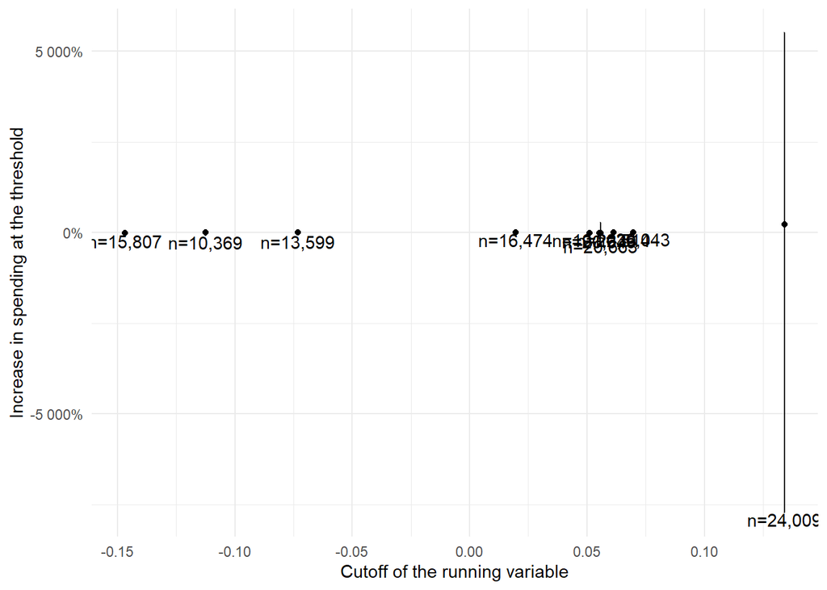

```r
df <- rdd_placebo %>%
  #tidyr::drop_na() %>%
  #filter(abs(ci_upper) < 100 | abs(ci_lower) < 100) %>%
  mutate(effective_n = paste0("n=", trimws(format(effective_n, big.mark = ",") ) ) ) # add big mark
ggplot2::ggplot(df) +
  geom_point(aes(x = placebo_c, y = point_estimate), size = 1.5, colour = ifelse(df$p <= 0.05, 2, 1)) +
  geom_errorbar(aes(x = placebo_c, ymin = ci_lower, ymax = ci_upper),
                colour = ifelse(df$p <= 0.05, 2, 1),
                linetype = ifelse(df$p <= 0.05, 2, 1)) +
  geom_text(aes(x = placebo_c, y = ci_lower, label = effective_n),
            colour = ifelse(df$p <= 0.05, 2, 1), vjust = 1) +
  scale_y_continuous(labels = scales::percent) +
  labs(x = "Cutoff of the running variable", y = "Increase in spending at the threshold")
```

```r
ggsave(filename = "plots/rdrobust_placebo2.pdf", width = 6, height = 6*9/16)
rm(df, vector)
```

#### Separate years/states

**This section should be sorted into heterogeneity**

For each year: Not much variation in the results here (as expected)

```r
all_years <- d_rdd_bivariate %>% distinct(year) %>% pull()
for (i in all_years) {
  print(paste("year:", i))
  df <- d_rdd_bivariate %>%
    filter(year == i)
  rdd <-
    rdrobust::rdrobust(
      y = df$ln_gross_expenditure_pc,
      x = df$inhabs_rel_to_cutoff,
      fuzzy = df$total_seats,
      cluster = df$inhabitants_treshold_factor,
      covs = model.matrix( ~ df$inhabitants_treshold_factor + df$state) # Dropping year FE, obviously
  )
  summary(rdd)
}
```

```
## [1] "year: 2002"
## [1] "Mass points detected in the running variable."
## Covariate-adjusted Fuzzy RD estimates using local polynomial regression.
##
## Number of Obs.                 7841
## BW type                       mserd
## Kernel                   Triangular
## VCE method                       NN
##
## Number of Obs.                 3741         4100
## Eff. Number of Obs.            1475         1525
## Order est. (p)                    1            1
## Order bias  (q)                   2            2
## BW est. (h)                   0.129        0.129
## BW bias (b)                   0.276        0.276
## rho (h/b)                     0.469        0.469
## Unique Obs.                    1911         2184
##
## First-stage estimates.
##
## =============================================================================
##         Method     Coef. Std. Err.         z     P>|z|      [ 95% C.I. ]
## =============================================================================
##   Conventional     1.896     0.211     9.006     0.000     [1.484 , 2.309]
##         Robust         -         -     7.721     0.000     [1.336 , 2.245]
## =============================================================================
##
## Treatment effect estimates.
##
## =============================================================================
##         Method     Coef. Std. Err.         z     P>|z|      [ 95% C.I. ]
## =============================================================================
##   Conventional     0.009     0.007     1.204     0.228    [-0.005 , 0.023]
##         Robust         -         -     1.124     0.261    [-0.006 , 0.024]
## =============================================================================
## [1] "year: 2003"
## [1] "Mass points detected in the running variable."
## Covariate-adjusted Fuzzy RD estimates using local polynomial regression.
##
## Number of Obs.                 8857
```

[output cut: 400 more lines]

```
## =============================================================================
##         Method     Coef. Std. Err.         z     P>|z|      [ 95% C.I. ]
## =============================================================================
##   Conventional     1.402     0.229     6.133     0.000     [0.954 , 1.850]
##         Robust         -         -     5.340     0.000     [0.836 , 1.805]
## =============================================================================
##
## Treatment effect estimates.
##
## =============================================================================
##         Method     Coef. Std. Err.         z     P>|z|      [ 95% C.I. ]
## =============================================================================
##   Conventional     0.016     0.015     1.103     0.270    [-0.012 , 0.044]
##         Robust         -         -     1.226     0.220    [-0.011 , 0.049]
## =============================================================================
```

For each state:

```r
# to do: remove eval = F
all_states <- d_rdd_bivariate %>% distinct(state) %>% filter(state != 15) %>% pull() # issues with 15...
for (i in all_states) {
  print(paste("state:", i))
  df <- d_rdd_bivariate %>%
    filter(state == i)
  rdd <-
    rdrobust::rdrobust(
      y = df$ln_gross_expenditure_pc,
      x = df$inhabs_rel_to_cutoff,
      fuzzy = df$total_seats,
      cluster = df$inhabitants_treshold_factor,
      covs = model.matrix( ~ df$inhabitants_treshold_factor + df$year) # Dropping state FE, obviously
  )
  summary(rdd)
}
```

```
## [1] "state: 1"
## [1] "Mass points detected in the running variable."
## Covariate-adjusted Fuzzy RD estimates using local polynomial regression.
##
## Number of Obs.                11274
## BW type                       mserd
## Kernel                   Triangular
## VCE method                       NN
##
## Number of Obs.                 4740         6534
## Eff. Number of Obs.             844         1002
## Order est. (p)                    1            1
## Order bias  (q)                   2            2
## BW est. (h)                   0.068        0.068
## BW bias (b)                   0.153        0.153
## rho (h/b)                     0.446        0.446
## Unique Obs.                     583          802
##
## First-stage estimates.
##
## =============================================================================
##         Method     Coef. Std. Err.         z     P>|z|      [ 95% C.I. ]
## =============================================================================
##   Conventional     2.235     0.080    27.998     0.000     [2.078 , 2.391]
##         Robust         -         -    25.633     0.000     [2.041 , 2.380]
## =============================================================================
##
## Treatment effect estimates.
##
## =============================================================================
##         Method     Coef. Std. Err.         z     P>|z|      [ 95% C.I. ]
## =============================================================================
##   Conventional     0.012     0.009     1.237     0.216    [-0.007 , 0.030]
##         Robust         -         -     1.532     0.126    [-0.004 , 0.035]
## =============================================================================
## [1] "state: 5"
## [1] "Mass points detected in the running variable."
## Covariate-adjusted Fuzzy RD estimates using local polynomial regression.
##
## Number of Obs.                 2772
```

[output cut: 295 more lines]

```
## =============================================================================
##         Method     Coef. Std. Err.         z     P>|z|      [ 95% C.I. ]
## =============================================================================
##   Conventional     2.243     0.167    13.449     0.000     [1.916 , 2.570]
##         Robust         -         -    12.614     0.000     [1.812 , 2.479]
## =============================================================================
##
## Treatment effect estimates.
##
## =============================================================================
##         Method     Coef. Std. Err.         z     P>|z|      [ 95% C.I. ]
## =============================================================================
##   Conventional     0.011     0.014     0.754     0.451    [-0.017 , 0.039]
##         Robust         -         -     0.600     0.549    [-0.023 , 0.043]
## =============================================================================
```

```r
rm(list=ls(pattern="^panel_"), all_years, all_states, rdd)
```

#### Mass points

Investigating mass points: to do

```r
sum(!is.na(data$inhabs_rel_to_cutoff)) # Number of valid observations of running variable
```

```
## [1] 191249
```

```r
length(unique(data$inhabs_rel_to_cutoff)) # Number of unique values of running variable
```

```
## [1] 10887
```

```r
sum(!is.na(data$inhabs_rel_to_cutoff)) / length(unique(data$inhabs_rel_to_cutoff)) # 18 observations per value
```

```
## [1] 17.56673
```

Lee and Card 2008 procedure: Clustering at the respective dicrete values of the running variable

–> RDhonest???

## Mechanisms

### Different fiscal policy variables

etc.

## Checking assumptions

### Density tests

I am only using election years in order to avoid multiple observations on the running variable (also for the `rddensity` check).

```r
dens_test_d_rdd_bivariate <- d_rdd_bivariate %>%
  filter(election_year == 1 | year == 2002)
```

#### McCrary (2008) Sorting test

McCrary test for all states pooled (with running variable values occuring multiple times):

```
## Using calculated bin size:  0.002
## Using calculated bandwidth:  0.223
```

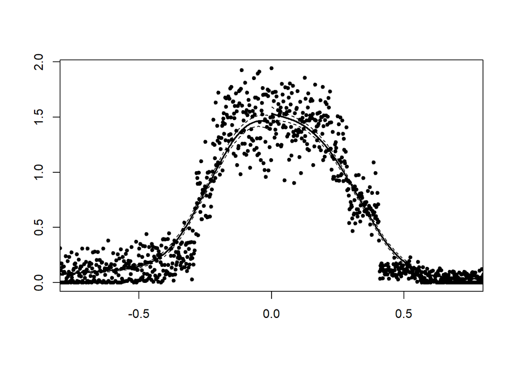

```
## Log difference in heights is  0.065  with SE  0.012
##   this gives a z-stat of  5.270
##   and a p value of  0.000
```

```
## [1] 0.0000001360686
```

```r
rdd::DCdensity(runvar = data$inhabs_rel_to_cutoff, cutpoint = 0, plot = TRUE, verbose = TRUE)
```

```
## Using calculated bin size:  0.004
## Using calculated bandwidth:  0.243
```

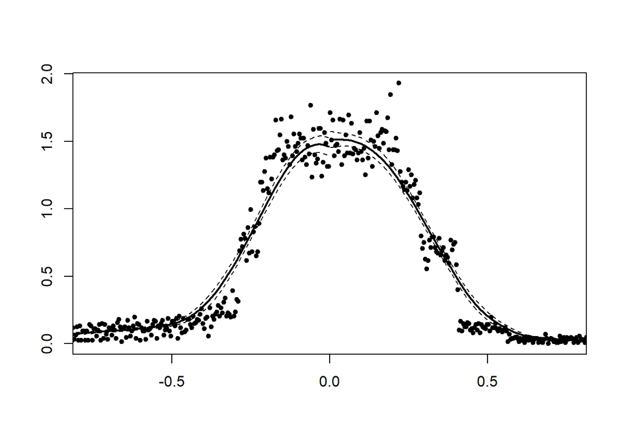

```
## Log difference in heights is  0.038  with SE  0.030
##   this gives a z-stat of  1.248
##   and a p value of  0.212
```

```
## [1] 0.2119866
```

```r
rdd::DCdensity(runvar = dens_test_d_rdd_bivariate$inhabs_rel_to_cutoff, cutpoint = 0, plot = TRUE, verbose = TRUE)
```

Export plot:

```r
pdf(file = "plots/mccrary.pdf", width = 10, height = 10*9/16)
rdd::DCdensity(runvar = dens_test_d_rdd_bivariate$inhabs_rel_to_cutoff, cutpoint = 0, plot = TRUE, verbose = TRUE)
```

```
## Using calculated bin size:  0.004
## Using calculated bandwidth:  0.243
```

```
## Log difference in heights is  0.038  with SE  0.030
##   this gives a z-stat of  1.248
##   and a p value of  0.212
```

```
## [1] 0.2119866
```

```r
title(xlab = "Running variable (Population relative to thresholds)")
abline(v=0)
dev.off()
```

The test for the overall data is significant (i. e. there is a jump at the threshold). But this may be due to almost all values of the running variable occuring multiple times (given the nature of the data set). Hence, the “real” test on the data set is not statistically significant any more.

#### `rddensity` discontinuity test

```r
rddensity_disc_test <- rddensity::rddensity(X = dens_test_d_rdd_bivariate$inhabs_rel_to_cutoff, c = 0)
summary(rddensity_disc_test)
```

```
##
## Manipulation testing using local polynomial density estimation.
##
## Number of obs =       28880
## Model =               unrestricted
## Kernel =              triangular
## BW method =           estimated
## VCE method =          jackknife
##
## c = 0                 Left of c           Right of c
## Number of obs         13838               15042
## Eff. Number of obs    2496                3452
## Order est. (p)        2                   2
## Order bias (q)        3                   3
## BW est. (h)           0.061               0.079
##
## Method                T                   P > |T|
## Robust                0.9535              0.3403
```

```
##
## P-values of binomial tests (H0: p=0.5).
##
## Window Length / 2          <c     >=c    P>|T|
## 0.000                       0      40    0.0000
```

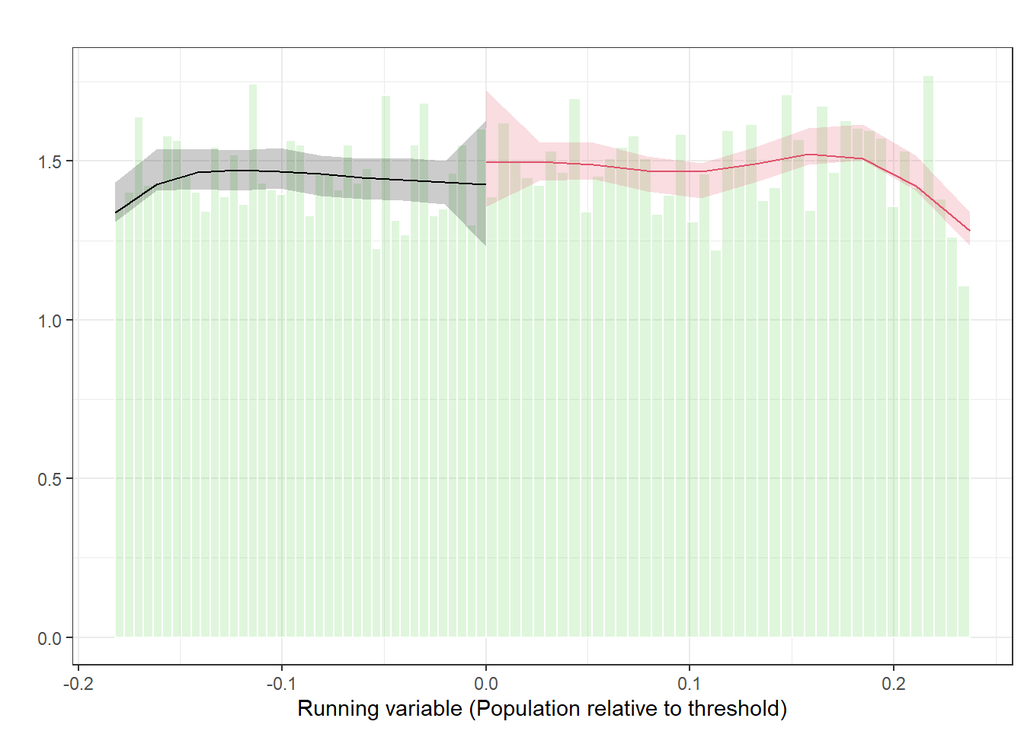

```r
p <- rddensity::rdplotdensity(rddensity_disc_test, X = dens_test_d_rdd_bivariate$inhabs_rel_to_cutoff, xlabel = "Running variable (Population relative to threshold)")
```

Export plot

```r
pdf(file = "plots/rddensity.pdf", width = 10, height = 10*9/16)
p
```

[output not shown]

```r
dev.off()
```

```r
rm(p)
```

#### Testing for sorting in different entities, time periods, thresholds…

McCrary and `rddensity` tests for each state separately.

- McCrary: HE & TH have (positive) significant jumps at the cutoff.
- `rddensity`: BW & SA show signs of significant sorting at the cutoff, positively and negatively, respectively.

```r
all_states <- dens_test_d_rdd_bivariate %>%
  distinct(state) %>%
  filter(state != 3 & state != 12 & state != 13 & state != 15) %>% # Remove state with no/too few obs
  pull()
jump_mccrary <- list()
p_value_mccrary <- list()
jump_rddensity <- list()
p_value_rddensity <- list()
state <- list()
for (i in all_states){
  df_subset <- dens_test_d_rdd_bivariate %>% filter(state == i) %>% drop_na(inhabs_rel_to_cutoff)
  state[i] <- i
  out_mccrary <- rdd::DCdensity(runvar = df_subset$inhabs_rel_to_cutoff, cutpoint = 0, plot = FALSE, ext.out = TRUE)
  jump_mccrary[i] <- out_mccrary$theta
  p_value_mccrary[i] <- out_mccrary$p
  out_rddensity <- rddensity::rddensity(X = df_subset$inhabs_rel_to_cutoff)
  jump_rddensity[i] <- out_rddensity$hat$diff
  p_value_rddensity[i] <- out_rddensity$test$p_jk
}
sorting <- tibble(state, jump_mccrary, p_value_mccrary, jump_rddensity, p_value_rddensity) %>%
  unnest() %>%
  arrange(p_value_rddensity)
sorting
```

| state | jump_mccrary | p_value_mccrary | jump_rddensity | p_value_rddensity |
| --- | --- | --- | --- | --- |
| 14 | -0.1440632671 | 0.36206785 | -0.91365149 | 0.06292487 |
| 8 | 0.0874706707 | 0.24476870 | 0.59580999 | 0.08196641 |
| 5 | -0.3294839428 | 0.16774133 | -0.72969792 | 0.25015345 |
| 6 | 0.2245082514 | 0.08947618 | -0.52962093 | 0.26212895 |
| 16 | 0.1638616834 | 0.07976766 | 0.23285769 | 0.34223713 |
| 10 | -0.2783606121 | 0.46671826 | -1.18560004 | 0.47898861 |
| 9 | 0.0183125045 | 0.79896082 | 0.19029070 | 0.52835746 |
| 7 | 0.0006798345 | 0.98933938 | 0.08954116 | 0.61497552 |
| 1 | 0.0236164603 | 0.81964405 | 0.16664730 | 0.63799026 |

```r
rm(all_states, df_subset, jump_mccrary, jump_rddensity, out_mccrary, out_rddensity, p_value_mccrary, p_value_rddensity, state)
```

McCrary and `rddensity` tests for each year separately:

- McCrary: No significant discontinuities here.
- `rddensity`: 2003 and 2004 (the latter was an important election year on the local level) show signs of sorting to the right at the 10% level.

```r
all_years <- dens_test_d_rdd_bivariate %>%
  distinct(year) %>%
  arrange(year) %>%
  pull()
year <- list()
jump_mccrary <- list()
p_value_mccrary <- list()
jump_rddensity <- list()
p_value_rddensity <- list()
for (i in all_years){
  df_subset <- dens_test_d_rdd_bivariate %>% filter(year == i) %>% drop_na(inhabs_rel_to_cutoff)
  year[i] <- i
  out_mccrary <- rdd::DCdensity(runvar = df_subset$inhabs_rel_to_cutoff, cutpoint = 0, plot = FALSE, ext.out = TRUE)
  jump_mccrary[i] <- out_mccrary$theta
  p_value_mccrary[i] <- out_mccrary$p
  out_rddensity <- rddensity::rddensity(X = df_subset$inhabs_rel_to_cutoff)
  jump_rddensity[i] <- out_rddensity$hat$diff
  p_value_rddensity[i] <- out_rddensity$test$p_jk
  #print(paste0("McCrary -- Year: ", i, ", jump: ", out1$theta, ", p value: ", out1$p, ", n: ", length(df_subset$inhabs_rel_to_cutoff)))
  #print(paste0("rddensity -- Year: ", i, ", jump: ", out2$hat$diff, ", p value: ", out2$test$p_jk, ", n: ", length(df_subset$inhabs_rel_to_cutoff)))
}
sorting <- tibble(year, jump_mccrary, p_value_mccrary, jump_rddensity, p_value_rddensity) %>%
  unnest() %>%
  arrange(p_value_rddensity)
sorting
```

| year | jump_mccrary | p_value_mccrary | jump_rddensity | p_value_rddensity |
| --- | --- | --- | --- | --- |
| 2003 | 0.06102431 | 0.6585071 | 0.8043773 | 0.07479400 |
| 2004 | 0.05794171 | 0.3533846 | 0.4120027 | 0.08833168 |
| 2011 | -0.04942351 | 0.8188298 | -1.0750482 | 0.13589878 |
| 2002 | -0.01798787 | 0.7395630 | -0.2297376 | 0.35768451 |
| 2014 | 0.02267130 | 0.7163992 | 0.1643500 | 0.56014299 |
| 2006 | 0.27502184 | 0.2111878 | 0.4368847 | 0.58916991 |
| 2009 | -0.03953130 | 0.5582710 | -0.1116325 | 0.66246879 |
| 2008 | 0.02486538 | 0.7879813 | 0.0562275 | 0.87943533 |

```r
rm(all_years, df_subset, jump_mccrary, jump_rddensity, out_mccrary, out_rddensity, p_value_mccrary, p_value_rddensity, year)
```

Testing at every threshold separately:

- McCrary test: 300, 2,000, and 10,000 significant at least at the 10 % significance level.
- `rddensity` reveals sorting to the left at the 15,000 threshold.

```r
all_th <- dens_test_d_rdd_bivariate %>%
  filter(inhabitants_treshold <= 30000 | inhabitants_treshold == 50000 |
           inhabitants_treshold == 100000 | inhabitants_treshold == 150000) %>%
  # Test works only for those values
  distinct(inhabitants_treshold) %>%
  arrange(inhabitants_treshold) %>%
  pull()
threshold <- list()
state <- list()
jump_mccrary <- list()
p_value_mccrary <- list()
jump_rddensity <- list()
p_value_rddensity <- list()
for (i in all_th){
  df_subset <- dens_test_d_rdd_bivariate %>%
    filter(inhabitants_treshold == i) %>%
    drop_na(inhabs_rel_to_cutoff)
  state[i] <- unique(df_subset$state) %>% paste(collapse = ",")
  threshold[i] <- i
  out_mccrary <- rdd::DCdensity(runvar = df_subset$inhabs_rel_to_cutoff, cutpoint = 0, plot = FALSE, ext.out = TRUE)
  jump_mccrary[i] <- out_mccrary$theta
  p_value_mccrary[i] <- out_mccrary$p
  out_rddensity <- rddensity::rddensity(X = df_subset$inhabs_rel_to_cutoff)
  jump_rddensity[i] <- out_rddensity$hat$diff
  p_value_rddensity[i] <- out_rddensity$test$p_jk
}
sorting <- tibble(threshold, state, jump_mccrary, p_value_mccrary, jump_rddensity, p_value_rddensity) %>%
  unnest() %>%
  arrange(p_value_rddensity)
sorting
```

| threshold | state | jump_mccrary | p_value_mccrary | jump_rddensity | p_value_rddensity |
| --- | --- | --- | --- | --- | --- |
| 15000 | 1,5,7 | 0.0154654909269471077526 | 0.9750868716676 | -1.59394676 | 0.09839829 |
| 1000 | 7,8,9,14,16 | 0.0208362114347991067564 | 0.8060982498938 | 0.36946951 | 0.12756945 |
| 3000 | 6,8,9,14,16 | -0.0851080427017397722622 | 0.3987044186745 | -0.63442974 | 0.24278518 |
| 70 | 1 | -0.0074165023570695320920 | 0.9848316590838 | -0.54419976 | 0.26698698 |
| 30000 | 5,7,8,9,10,14,16 | -0.1105745793785755104466 | 0.6751498049635 | -1.31521991 | 0.30967395 |
| 1250 | 1 | 0.5349166140804909597151 | 0.6055116591503 | 2.14151681 | 0.32241394 |
| 100000 | 5,6,7,9,10,13,16 | 0.1452220900297508388022 | 0.7331604084137 | -1.86153865 | 0.35904500 |
| 20000 | 7,8,9,10,14,16 | 0.1594200915428117815154 | 0.6226487651482 | 0.76214185 | 0.43844500 |
| 50000 | 5,6,8,9,13,14,15,16 | -0.0272875402846734227413 | 0.9467859322033 | 0.65370116 | 0.45719054 |
| 2000 | 1,8,9,14,16 | 0.2812374645810263862344 | 0.0336028797690 | 0.39239954 | 0.48052834 |

[output cut: 11 more lines]

```r
rm(all_th, df_subset, jump_mccrary, jump_rddensity, out_mccrary, out_rddensity, p_value_mccrary, p_value_rddensity, state, threshold)
```

#### Varying bandwidths

Limiting data set to observations x % closest to the cutoff but maintaining data-driven bandwidth selection:

```r
bandwidths <- seq(0.025, 0.3, 0.025)
jump_mccrary <- list()
p_value_mccrary <- list()
jump_rddensity <- list()
p_value_rddensity <- list()
n <- list()
for (i in 1:length(bandwidths)){
  df_subset <- dens_test_d_rdd_bivariate %>% filter(closest <= bandwidths[i])
  # Filtering not done 100 % correctly, see definition of dens_test_d_rdd_bivariate
  out_mccrary <- rdd::DCdensity(runvar = df_subset$inhabs_rel_to_cutoff, cutpoint = 0, plot = FALSE, ext.out = TRUE)
  jump_mccrary[i] <- out_mccrary$theta
  p_value_mccrary[i] <- out_mccrary$p
  out_rddensity <- rddensity::rddensity(X = df_subset$inhabs_rel_to_cutoff)
  jump_rddensity[i] <- out_rddensity$hat$diff
  p_value_rddensity[i] <- out_rddensity$test$p_jk
  n[i] <- length(df_subset$inhabs_rel_to_cutoff)
}
sorting <- tibble(bandwidths, jump_mccrary, p_value_mccrary, jump_rddensity, p_value_rddensity, n) %>%
  unnest() %>%
  arrange(p_value_rddensity)
sorting
```

| bandwidths | jump_mccrary | p_value_mccrary | jump_rddensity | p_value_rddensity | n |
| --- | --- | --- | --- | --- | --- |
| 0.200 | 0.2440274 | 0.0031609595076 | 1.4159725 | 0.2029743 | 5738 |
| 0.175 | 0.2999223 | 0.0017500163860 | 1.4976525 | 0.2640409 | 5037 |
| 0.025 | 1.3762549 | 0.0000009546637 | 21.5590984 | 0.3160417 | 724 |
| 0.250 | 0.2413755 | 0.0026766526770 | 0.6868347 | 0.3643923 | 7165 |
| 0.300 | 0.2301554 | 0.0027292971347 | 0.4963923 | 0.4169710 | 8622 |
| 0.275 | 0.2333885 | 0.0021553147603 | 0.5302906 | 0.4432861 | 7898 |
| 0.050 | 0.6654514 | 0.0001687553478 | -3.3721729 | 0.6390104 | 1443 |
| 0.225 | 0.3015075 | 0.0014450680356 | 0.3825334 | 0.6553226 | 6437 |
| 0.150 | 0.4012633 | 0.0004599081613 | 0.5313362 | 0.6776025 | 4312 |
| 0.100 | 0.4080484 | 0.0004693451692 | -0.6809253 | 0.8488650 | 2886 |

[output cut: 2 more lines]

```r
rm(bandwidths, df_subset, jump_mccrary, jump_rddensity, n, out_mccrary, out_rddensity, p_value_mccrary, p_value_rddensity)
```

Using all observations in x % window, without further (data-driven) bandwidth selection:

```r
bandwidths <- seq(0.025, 0.3, 0.025)
jump_mccrary <- list()
p_value_mccrary <- list()
jump_rddensity <- list()
p_value_rddensity <- list()
n <- list()
bw <- 100
for (i in 1:length(bandwidths)){
  df_subset <- dens_test_d_rdd_bivariate %>% filter(closest <= bandwidths[i])
  # Filtering not done 100 % correctly, see definition of dens_test_d_rdd_bivariate
  out_mccrary <- rdd::DCdensity(runvar = df_subset$inhabs_rel_to_cutoff, cutpoint = 0, plot = FALSE, ext.out = TRUE, bw = bw)
  jump_mccrary[i] <- out_mccrary$theta
  p_value_mccrary[i] <- out_mccrary$p
  out_rddensity <- rddensity::rddensity(X = df_subset$inhabs_rel_to_cutoff, h = bw)
  jump_rddensity[i] <- out_rddensity$hat$diff
  p_value_rddensity[i] <- out_rddensity$test$p_jk
  n[i] <- length(df_subset$inhabs_rel_to_cutoff)
}
sorting <- tibble(bandwidths, jump_mccrary, p_value_mccrary, jump_rddensity, p_value_rddensity, n) %>%
  unnest() %>%
  arrange(p_value_rddensity)
sorting
```

| bandwidths | jump_mccrary | p_value_mccrary | jump_rddensity | p_value_rddensity | n |
| --- | --- | --- | --- | --- | --- |
| 0.075 | 0.10075564 | 0.008873381 | 5.1350130 | 0.1004826 | 2165 |
| 0.150 | 0.06869103 | 0.011765927 | 1.4660771 | 0.1922520 | 4312 |
| 0.100 | 0.07351422 | 0.027406990 | 1.7641215 | 0.3863726 | 2886 |
| 0.125 | 0.07671712 | 0.010156236 | 1.2367405 | 0.3996242 | 3600 |
| 0.175 | 0.06714331 | 0.007786460 | 0.7410183 | 0.4078017 | 5037 |
| 0.225 | 0.05931244 | 0.007873021 | 0.4978978 | 0.4233140 | 6437 |
| 0.250 | 0.05279089 | 0.012576132 | 0.4220462 | 0.4240269 | 7165 |
| 0.200 | 0.05162303 | 0.028950442 | 0.5187276 | 0.4826233 | 5738 |
| 0.275 | 0.04005260 | 0.046807588 | 0.2034837 | 0.6549186 | 7898 |
| 0.300 | 0.03800797 | 0.048723961 | 0.1158799 | 0.7723207 | 8622 |

[output cut: 2 more lines]

```r
rm(bandwidths, df_subset, jump_mccrary, jump_rddensity, n, out_mccrary, out_rddensity, p_value_mccrary, p_value_rddensity)
```

For both applications, the McCrary test consistently shows sorting, whereas the `rddensity` test is (with a single exception) unable to detect sorting. Puzzling…

#### Placebo density tests

Placebo McCrary (2008) test: Even the placebo thresholds are statistically significant in many cases. Maybe the discontinuities above are just a matter of statistical power?

```r
# "Structured" approach
cuts <- seq(from = -(2+2/3), to = 2/3, by = 1/6) # Values chosen such that code does run
#length <- length(cuts)
cutoff <- list()
jump_mccrary <- list()
p_value_mccrary <- list()
out_rddensity <- list()
jump_rddensity <- list()
p_value_rddensity <- list()
for (i in 1:length(cuts)){
  cutoff[i] <- cuts[i]
  out_mccrary <- rdd::DCdensity(runvar = dens_test_d_rdd_bivariate$inhabs_rel_to_cutoff,
                              cutpoint = cuts[i], plot = FALSE, ext.out = TRUE)
  jump_mccrary[i] <- out_mccrary$theta
  p_value_mccrary[i] <- out_mccrary$p
  out_rddensity <- rddensity::rddensity(X = dens_test_d_rdd_bivariate$inhabs_rel_to_cutoff,
                                           c = cuts[i])
  jump_rddensity[i] <- out_rddensity$hat$diff
  p_value_rddensity[i] <- out_rddensity$test$p_jk
}
sorting <- tibble(cutoff, jump_mccrary, p_value_mccrary, jump_rddensity, p_value_rddensity) %>%
  unnest() %>%
  arrange(p_value_mccrary)
sorting
```

| cutoff | jump_mccrary | p_value_mccrary | jump_rddensity | p_value_rddensity |
| --- | --- | --- | --- | --- |
| 0.3333333 | -0.34266825 | 0.0000000000000000000001121126 | 0.2393240955 | 0.00883668586661889 |
| -0.3333333 | 0.46167907 | 0.0000000000000233238465553557 | -0.3234199698 | 0.00000000007078812 |
| -0.6666667 | -0.79998790 | 0.0000000000001527081442313237 | -0.0239614166 | 0.42580640447011947 |
| -0.8333333 | -0.36710116 | 0.0003996759791136275208160711 | -0.0366191192 | 0.26139163392282455 |
| 0.1666667 | 0.08939585 | 0.0012459696287469550907145432 | 0.1314151216 | 0.15971682967447912 |
| -1.8333333 | 0.52218231 | 0.0045122898346784930459496543 | 0.0002588467 | 0.97319872755743531 |
| -1.0000000 | -0.28338650 | 0.0098151953741658134328096352 | -0.0116135091 | 0.46697968711686194 |
| -0.1666667 | 0.07227324 | 0.0113633741349285690563908346 | 0.0098098756 | 0.93885735035816564 |
| -2.3333333 | -1.29869422 | 0.0196666877195878046780119774 | -0.0009673797 | 0.74712234807723399 |
| -1.1666667 | -0.21442579 | 0.0720411124822715326354582999 | 0.0080248983 | 0.63913212183370782 |

[output cut: 11 more lines]

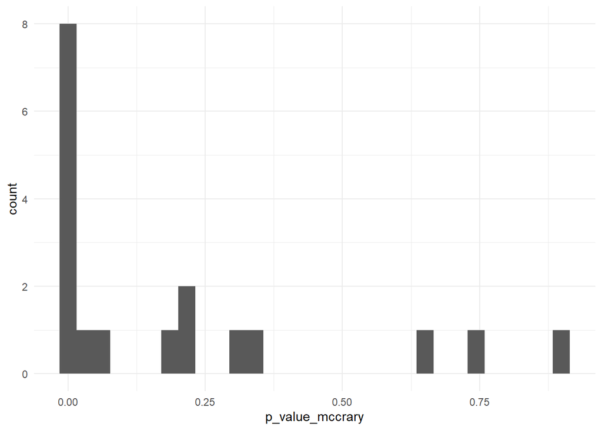

```r
ggplot2::ggplot(sorting) + geom_histogram(aes(p_value_mccrary))
```

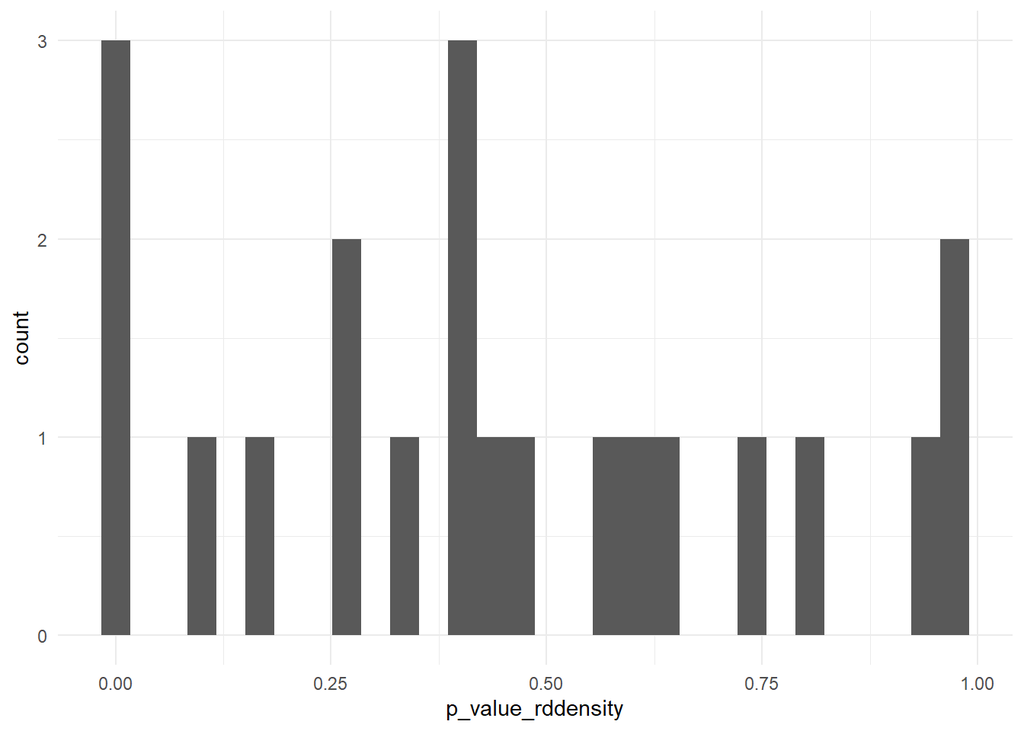

```r
ggplot2::ggplot(sorting) + geom_histogram(aes(p_value_rddensity))
```

```r
rm(cutoff, cuts, i, jump_rddensity, out_mccrary, out_rddensity, p_value_mccrary, p_value_rddensity)
```

```r
# "Random" approach
set.seed(234) # Value chosen such that rdd:DCdensity actually runs without error -> bias?
random_z_score <- rnorm(50)/2 # Neither randomly nor z-distributed, but roughly around my cutoff
cutoff <- list()
jump_mccrary <- list()
p_value_mccrary <- list()
out_rddensity <- list()
jump_rddensity <- list()
p_value_rddensity <- list()
for (i in 1:50){
  cutoff[i] <- random_z_score[i]
  out_mccrary <- rdd::DCdensity(runvar = dens_test_d_rdd_bivariate$inhabs_rel_to_cutoff,
                                       cutpoint = random_z_score[i], plot = FALSE, ext.out = TRUE)
  jump_mccrary[i] <- out_mccrary$theta
  p_value_mccrary[i] <- out_mccrary$p
  out_rddensity <- rddensity::rddensity(X = dens_test_d_rdd_bivariate$inhabs_rel_to_cutoff,
                               c = random_z_score[i])
  jump_rddensity[i] <- out_rddensity$hat$diff
  p_value_rddensity[i] <- out_rddensity$test$p_jk
}
sorting <- tibble(cutoff, p_value_mccrary, jump_rddensity, p_value_rddensity) %>%
  unnest() %>%
  arrange(cutoff)
sorting
```

| cutoff | p_value_mccrary | jump_rddensity | p_value_rddensity |
| --- | --- | --- | --- |
| -1.518044912 | 2.084321e-01 | 0.007447499 | 0.59149727680488028980221 |
| -1.026491502 | 6.551468e-04 | -0.024918739 | 0.10715560717161197457070 |
| -0.749603026 | 1.262916e-16 | -0.031561157 | 0.43669768629385297131762 |
| -0.747668922 | 4.701925e-09 | -0.003992531 | 0.90935966073427842992771 |
| -0.705911127 | 3.465233e-08 | -0.020871760 | 0.59606822441174001081521 |
| -0.681921126 | 6.805455e-17 | 0.038016699 | 0.30391929060312117272247 |
| -0.543933654 | NaN | 0.017623251 | 0.76055940990858961203713 |
| -0.519047233 | NaN | 0.031447652 | 0.61237245147183561044812 |
| -0.513629311 | NaN | 0.024932752 | 0.59853021713483856025562 |
| -0.509899776 | NaN | -0.015261774 | 0.80045279560752313763317 |

[output cut: 40 more lines]

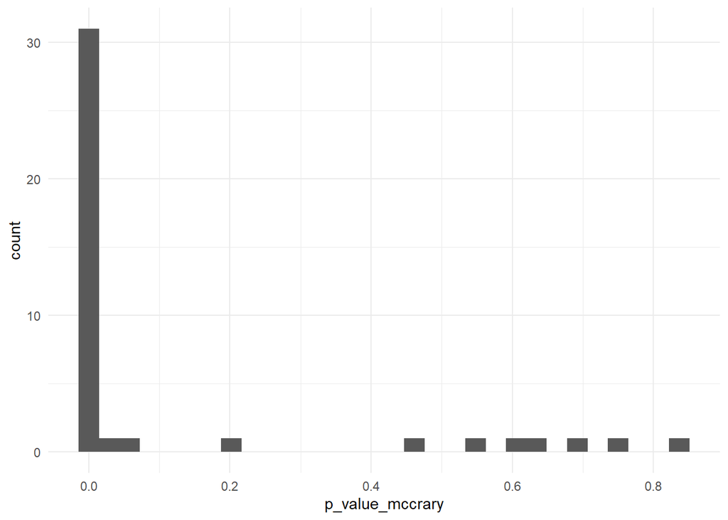

```r
ggplot2::ggplot(sorting) + geom_histogram(aes(p_value_mccrary))
```

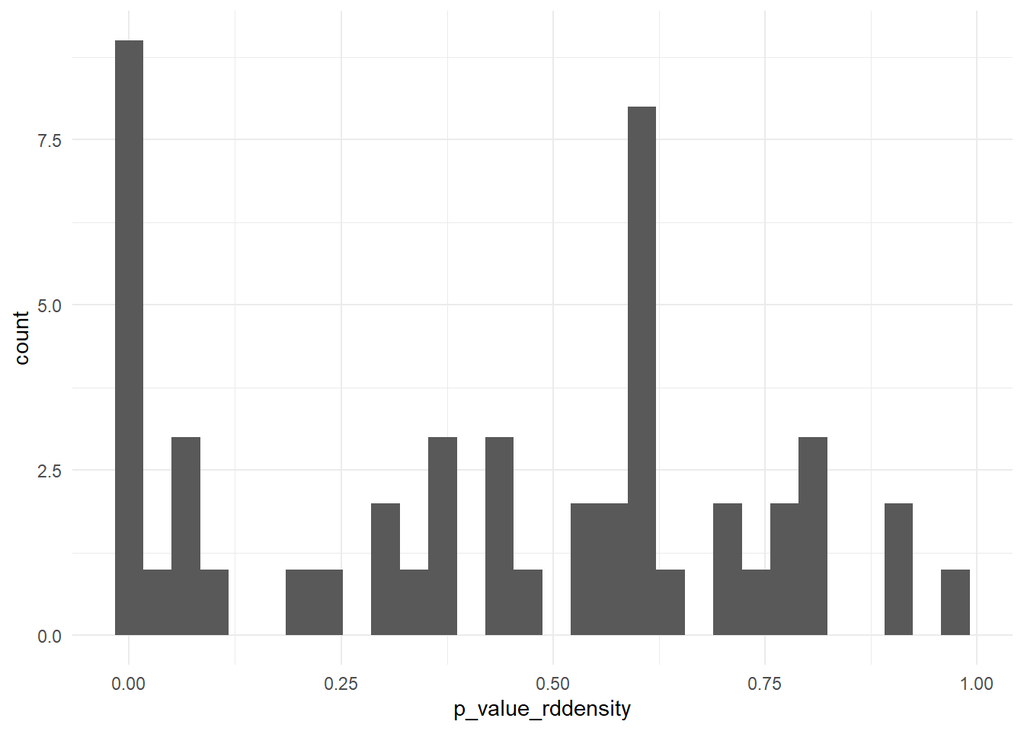

```r
ggplot2::ggplot(sorting) + geom_histogram(aes(p_value_rddensity))
```

```r
rm(cutoff, i, jump_mccrary, jump_rddensity, out_mccrary, out_rddensity, p_value_mccrary, p_value_rddensity, random_z_score)
```

Strangely, the number of observations with p values smaller than 10 % is higher than one would expect, especially with the McCrary test. I do not have an explanation for this.

```r
rm(dens_test_d_rdd_bivariate, sorting)
```